# Full_Code_NLP_RAG_Project_Notebooknew

## Problem Statement

### Business Context

The healthcare industry is rapidly evolving, with professionals facing increasing challenges in managing vast volumes of medical data while delivering accurate and timely diagnoses. The need for quick access to comprehensive, reliable, and up-to-date medical knowledge is critical for improving patient outcomes and ensuring informed decision-making in a fast-paced environment.

Healthcare professionals often encounter information overload, struggling to sift through extensive research and data to create accurate diagnoses and treatment plans. This challenge is amplified by the need for efficiency, particularly in emergencies, where time-sensitive decisions are vital. Furthermore, access to trusted, current medical information from renowned manuals and research papers is essential for maintaining high standards of care.

To address these challenges, healthcare centers can focus on integrating systems that streamline access to medical knowledge, provide tools to support quick decision-making, and enhance efficiency. Leveraging centralized knowledge platforms and ensuring healthcare providers have continuous access to reliable resources can significantly improve patient care and operational effectiveness.

**Common Questions to Answer**

**1. Diagnostic Assistance**: "What are the common symptoms and treatments for pulmonary embolism?"

**2. Drug Information**: "Can you provide the trade names of medications used for treating hypertension?"

**3. Treatment Plans**: "What are the first-line options and alternatives for managing rheumatoid arthritis?"

**4. Specialty Knowledge**: "What are the diagnostic steps for suspected endocrine disorders?"

**5. Critical Care Protocols**: "What is the protocol for managing sepsis in a critical care unit?"

### Objective

As an AI specialist, your task is to develop a RAG-based AI solution using renowned medical manuals to address healthcare challenges. The objective is to **understand** issues like information overload, **apply** AI techniques to streamline decision-making, **analyze** its impact on diagnostics and patient outcomes, **evaluate** its potential to standardize care practices, and **create** a functional prototype demonstrating its feasibility and effectiveness.

### Data Description

The **Merck Manuals** are medical references published by the American pharmaceutical company Merck & Co., that cover a wide range of medical topics, including disorders, tests, diagnoses, and drugs. The manuals have been published since 1899, when Merck & Co. was still a subsidiary of the German company Merck.

The manual is provided as a PDF with over 4,000 pages divided into 23 sections.

## Installing and Importing Necessary Libraries and Dependencies

```python
# Installation for GPU llama-cpp-python
# uncomment and run the following code in case GPU is being used
!CMAKE_ARGS="-DLLAMA_CUBLAS=on" FORCE_CMAKE=1 pip install llama-cpp-python==0.1.85 --force-reinstall --no-cache-dir -q

# Installation for CPU llama-cpp-python
# uncomment and run the following code in case GPU is not being used
# !CMAKE_ARGS="-DLLAMA_CUBLAS=off" FORCE_CMAKE=1 pip install llama-cpp-python==0.1.85 --force-reinstall --no-cache-dir -q
```

[output not shown]

**Note**:

- After running the above cell, kindly restart the runtime (for Google Colab) or notebook kernel (for Jupyter Notebook), and run all cells sequentially from the next cell.
- On executing the above line of code, you might see a warning regarding package dependencies. This error message can be ignored as the above code ensures that all necessary libraries and their dependencies are maintained to successfully execute the code in *this notebook*.

```python
# For installing the libraries & downloading models from HF Hub
!pip install huggingface_hub==0.35.3 pandas==2.2.2 tiktoken==0.12.0 pymupdf==1.26.5 langchain==0.3.27 langchain-community==0.3.31 chromadb==1.1.1 sentence-transformers==5.1.1 numpy==2.3.3 -q
```

[output not shown]

**Note**:

- After running the above cell, kindly restart the runtime (for Google Colab) or notebook kernel (for Jupyter Notebook), and run all cells sequentially from the next cell.
- On executing the above line of code, you might see a warning regarding package dependencies. This error message can be ignored as the above code ensures that all necessary libraries and their dependencies are maintained to successfully execute the code in *this notebook*.

```python
pip install rank_bm25
```

```
Downloading rank_bm25-0.2.2-py3-none-any.whl (8.6 kB)
```

```python
# ===================================================================================================
# DEPENDENCIES & IMPORTS
# ===================================================================================================

# Standard libraries for file system operations, text processing, and performance profiling
import json, os
import re, gc, time, math, textwrap, warnings, collections

# Core data manipulation libraries
import pandas as pd
import numpy as np

# Libraries for visualisation in the Data Overview section
import matplotlib.pyplot as plt
import matplotlib.ticker as mticker
import seaborn as sns

# Graceful import for tokenization. Tiktoken is often used for OpenAI models or general chunking estimates.
try:
    import tiktoken
except ImportError:
    tiktoken = None

# ---------------------------------------------------------------------------------------------------
# LangChain & Vector Database Imports
# Wrapped in try/except blocks to allow the notebook to run in a degraded mode (e.g., local CPU)
# if heavy dependencies are not installed.
# ---------------------------------------------------------------------------------------------------
try:
    # Handles breaking text into context-window-friendly chunks without splitting words/sentences
    from langchain.text_splitter import RecursiveCharacterTextSplitter
except ImportError:
    from langchain_text_splitters import RecursiveCharacterTextSplitter

try:
    # Extracts text and metadata from PDFs
    from langchain_community.document_loaders import PyMuPDFLoader
except ImportError:
    PyMuPDFLoader = None

try:
    # Creates dense vector embeddings for semantic search
    from langchain_community.embeddings.sentence_transformer import SentenceTransformerEmbeddings
except ImportError:
    SentenceTransformerEmbeddings = None

try:
    # Local vector database to store and query the embeddings
    from langchain_community.vectorstores import Chroma
except ImportError:
    Chroma = None

# ---------------------------------------------------------------------------------------------------
# Local LLM Imports
# ---------------------------------------------------------------------------------------------------
try:
    # Used to fetch GGUF quantized models directly from Hugging Face
    from huggingface_hub import hf_hub_download
except ImportError:
    hf_hub_download = None

try:
    # Python bindings for llama.cpp to run large language models locally on CPU/GPU
    from llama_cpp import Llama
except ImportError:
    Llama = None

# PyMuPDF is used directly as well as through LangChain, because we need page-level access to the
# PDF bookmark/outline tree in order to label every page with its parent Section and Chapter.
import fitz

# BM25 sparse retrieval - used as a measurable lexical baseline alongside dense retrieval.
from rank_bm25 import BM25Okapi

# Suppress warnings to keep the notebook output clean during presentation/reading
warnings.filterwarnings("ignore")

# ===================================================================================================
# PRESENTATION & ENVIRONMENT CONFIGURATION
# ===================================================================================================

# Consistent presentation settings across every figure in this notebook.
sns.set_theme(style="whitegrid", context="notebook")

# Standardize matplotlib charts for readability and export quality
plt.rcParams.update({
    "figure.figsize": (11, 5),      # Default wide aspect ratio
    "figure.dpi": 110,              # Crisp rendering on standard screens
    "savefig.dpi": 110,
    "axes.titlesize": 13,
    "axes.titleweight": "bold",
    "axes.labelsize": 11,
    "font.size": 10,
    "axes.grid": True,
    "grid.alpha": 0.30,             # Subdued grid lines
})

# Define custom color palettes for brand consistency across visualizations
PALETTE = sns.color_palette("crest", 12)
ACCENT  = "#B7410E"

# Pandas display settings optimized for viewing large text chunks and metadata columns
pd.set_option("display.max_columns", 60)
pd.set_option("display.width", 190)
pd.set_option("display.float_format", lambda v: f"{v:,.3f}")

# ===================================================================================================
# RUNTIME CAPABILITY PROBE
# Determines up front which pipeline stages can actually execute, so that later sections check a flag
# instead of crashing halfway through a 4,000-page ingestion.
# ===================================================================================================

def probe_runtime():
    """
    Evaluates the current hardware and network environment.
    Checks for GPU acceleration (PyTorch), external network access (Hugging Face),
    and the successful import of critical ML libraries.

    Returns:
        dict: A mapping of capability flags (e.g., 'gpu', 'llama_cpp') to booleans.
    """
    caps = {
        "gpu": False,
        "hf_hub_reachable": False,
        "llama_cpp": Llama is not None,
        "sentence_transformers": SentenceTransformerEmbeddings is not None,
        "chromadb": Chroma is not None
    }

    # Check for hardware acceleration (CUDA)
    try:
        import torch
        caps["gpu"] = bool(torch.cuda.is_available())
        caps["gpu_name"] = torch.cuda.get_device_name(0) if caps["gpu"] else "none"
    except Exception:
        caps["gpu_name"] = "torch not available"

    # Check if the environment can reach Hugging Face to download weights
    try:
        import urllib.request
        # Use a quick HEAD request to test connectivity without downloading data
        req = urllib.request.Request("https://huggingface.co", method="HEAD")
        with urllib.request.urlopen(req, timeout=8) as r:
            caps["hf_hub_reachable"] = (r.status == 200)
    except Exception:
        caps["hf_hub_reachable"] = False

    return caps

# Execute the probe
CAPS = probe_runtime()

# Determine if the environment supports the complete RAG pipeline
FULL_STACK = (CAPS["hf_hub_reachable"] and CAPS["llama_cpp"]
              and CAPS["sentence_transformers"] and CAPS["chromadb"])

# Print a formatted diagnostic report
print("=" * 92)
print("LIBRARIES IMPORTED - RUNTIME CAPABILITY REPORT".center(92))
print("=" * 92)
for k, v in CAPS.items():
    # Dynamically format the output with 'OK' or '--' based on boolean truth
    print(f"   {'OK  ' if v is True else '--  '} {k:<26}: {v}")
print("-" * 92)
print(f"   FULL_STACK (Mistral-7B generation + dense embeddings available) : {FULL_STACK}")
print("=" * 92)

# Provide clear instructions to the user if the environment lacks necessary components
if not FULL_STACK:
    print(textwrap.dedent("""
        EXECUTION MODE: DEGRADED
        ------------------------
        Hugging Face model weights are not reachable from this runtime, so the generation cells
        cannot produce Mistral-7B output here.

          * Data loading, cleaning, the data overview, chunking and RETRIEVAL all execute FULLY
            on the real 4,114-page Merck Manual.
          * Generation cells contain complete, production-ready code that runs unchanged on a
            Colab T4 GPU runtime.

        To obtain full LLM output: open this notebook in Google Colab, set the runtime to T4 GPU,
        uncomment the two installation cells above, restart the session, and Run All.
    """))
```

```
============================================================================================
                       LIBRARIES IMPORTED - RUNTIME CAPABILITY REPORT
============================================================================================
   OK   gpu                       : True
   OK   hf_hub_reachable          : True
   OK   llama_cpp                 : True
   OK   sentence_transformers     : True
   OK   chromadb                  : True
   --   gpu_name                  : Tesla T4
--------------------------------------------------------------------------------------------
   FULL_STACK (Mistral-7B generation + dense embeddings available) : True
============================================================================================
```

**Observations**

⚬ GPU Active: The environment has successfully connected to a GPU, specifically a Tesla T4.

⚬ Network Access: hf_hub_reachable is True, meaning the notebook can successfully communicate with Hugging Face to download model weights.

⚬ Dependencies Installed: All core libraries required for the pipeline (llama_cpp, sentence_transformers, and chromadb) have been imported successfully.

⚬ Ready for Inference: Because all the checks passed, the FULL_STACK flag has evaluated to True.

# **Question Answering using LLM**

**Downloading and Loading the model**

```python
# ===================================================================================================
# DOWNLOADING AND LOADING THE LARGE LANGUAGE MODEL
# ---------------------------------------------------------------------------------------------------
# Model : Mistral-7B-Instruct-v0.2, quantised to 5-bit (Q5_K_M) in GGUF format.
#
# Why quantised: 5-bit quantisation reduces the model from roughly 14 GB to roughly 5 GB, which is
# what allows a 7-billion-parameter model to fit into a T4's 16 GB of VRAM alongside the embedding
# model while still leaving room for the KV cache at an 8,192-token context length.
#
# Key parameters:
#   n_ctx        = 8192  -> full context window; sized against the chunking analysis further below
#   n_gpu_layers = -1    -> offload every transformer layer to the GPU (needs the cuBLAS build)
#   n_batch      = 512   -> prompt-evaluation batch size
#   seed         = 42    -> reproducibility, which is a hard requirement for a clinical system
# ===================================================================================================
import sys
import time
import textwrap
from huggingface_hub import hf_hub_download
from llama_cpp import Llama

# Define the Hugging Face repository and the specific quantized file to pull
MODEL_REPO = "TheBloke/Mistral-7B-Instruct-v0.2-GGUF"
MODEL_FILE = "mistral-7b-instruct-v0.2.Q5_K_M.gguf"
llm = None

if FULL_STACK:
    # 0. Hack to fix Colab's terminal output crash with C++ binaries
    # We overwrite the method directly because Colab's native fileno() raises UnsupportedOperation
    # when llama_cpp tries to print its C-level diagnostic logs.
    sys.stdout.fileno = lambda: 1
    sys.stderr.fileno = lambda: 2

    # 1. Download Model Weights
    t0 = time.time()
    # hf_hub_download automatically caches the file, so subsequent runs won't redownload the 5GB file
    model_path = hf_hub_download(repo_id=MODEL_REPO, filename=MODEL_FILE)
    print(f"Weights downloaded in {time.time() - t0:,.1f}s -> {model_path}")

    # 2. Initialize Llama Model
    t1 = time.time()
    # -1 tells llama.cpp to offload all layers to the GPU. 0 forces CPU execution.
    gpu_layers = -1 if CAPS.get("gpu") else 0

    llm = Llama(
        model_path=model_path,
        n_ctx=8192,
        n_gpu_layers=gpu_layers,
        n_batch=512,
        verbose=False,  # CRITICAL: Suppresses C++ logs that crash Colab
        seed=42
    )

    # 3. Display Consolidated Model Stats
    print(
        f"Model loaded in {time.time() - t1:,.1f}s\n"
        f"  Repository   : {MODEL_REPO}\n"
        f"  Quantisation : {MODEL_FILE} (5-bit, ~5 GB)\n"
        f"  GPU layers   : {'all' if gpu_layers == -1 else '0 (CPU only)'}\n"
        f"  Context      : 8,192 tokens"
    )

else:
    # ===================================================================================================
    # OFFLINE MOCK LLM
    # If the environment lacks a GPU or network access, this mock class is injected in place of the LLM.
    # It ensures that downstream generation functions (which expect a specific dictionary response shape)
    # do not throw errors and crash the rest of the notebook.
    # ===================================================================================================
    class _OfflineLLM:
        """Signature-compatible stand-in for llama_cpp.Llama when model weights are unavailable."""

        NOTE = """[MISTRAL-7B GENERATION UNAVAILABLE IN THIS RUNTIME]
Hugging Face model weights could not be downloaded here. This cell executes and returns a full Mistral-7B answer on a Google Colab T4 GPU runtime.
All retrieval, grounding context and citations shown elsewhere in this notebook are real, computed from the actual Merck Manual corpus."""

        def __call__(self, prompt="", max_tokens=128, temperature=0.0,
                     top_p=0.95, top_k=50, stop=None, **kwargs):

            # Echo back prompt configuration for the reader to verify that the RAG assembly
            # (context + system prompt + question) is being formatted properly.
            tail = prompt[-900:] if len(prompt) > 900 else prompt

            text = f"""{self.NOTE}

--- PARAMETERS PASSED ---
max_tokens={max_tokens}, temperature={temperature}, top_p={top_p}, top_k={top_k}
prompt length: {len(prompt):,} characters (~{len(prompt)/4:,.0f} tokens)

--- END OF PROMPT ACTUALLY SENT TO THE MODEL ---
{tail}"""
            # Return the exact dictionary structure that llama_cpp naturally returns
            return {"choices": [{"text": text}]}

    llm = _OfflineLLM()
    print("Offline stand-in llm installed.")
    print(f"  Intended model : {MODEL_REPO} / {MODEL_FILE}")
    print("  All template-provided generation functions run unchanged against this object.")

# ---------------------------------------------------------------------------------------------------
# The five clinical questions from the problem statement, defined once and reused throughout.
# These questions are designed to test different aspects of RAG: direct retrieval, multi-hop
# reasoning, and complex medical procedures.
# ---------------------------------------------------------------------------------------------------
QUESTIONS = [
    "What is the protocol for managing sepsis in a critical care unit?",

    "What are the common symptoms of appendicitis, and can it be cured via medicine? "
    "If not, what surgical procedure should be followed to treat it?",

    "What are the effective treatments or solutions for addressing sudden patchy hair loss, "
    "commonly seen as localized bald spots on the scalp, and what could be the possible causes behind it?",

    "What treatments are recommended for a person who has sustained a physical injury to brain tissue, "
    "resulting in temporary or permanent impairment of brain function?",

    "What are the necessary precautions and treatment steps for a person who has fractured their leg "
    "during a hiking trip, and what should be considered for their care and recovery?",
]


def show_answer(question, answer, header=""):
    """
    Consistent, readable printing of a question/answer pair.
    Utilizes textwrap to prevent text from overflowing standard notebook margins.
    """
    if header:
        print("=" * 104); print(header); print("=" * 104)

    print("QUESTION:")
    print(textwrap.fill(question, 100))
    print("\nANSWER:")

    # Split by newline first so that structural paragraphs from the LLM aren't
    # crushed into a single massive block of text by textwrap.fill()
    for para in str(answer).split("\n"):
        print(textwrap.fill(para, 100) if para.strip() else "")
    print()

print(f"\n{len(QUESTIONS)} project questions loaded.")
```

```
Weights downloaded in 49.6s -> /root/.cache/huggingface/hub/models--TheBloke--Mistral-7B-Instruct-v0.2-GGUF/snapshots/3a6fbf4a41a1d52e415a4958cde6856d34b2db93/mistral-7b-instruct-v0.2.Q5_K_M.gguf
Model loaded in 21.2s
  Repository   : TheBloke/Mistral-7B-Instruct-v0.2-GGUF
  Quantisation : mistral-7b-instruct-v0.2.Q5_K_M.gguf (5-bit, ~5 GB)
  GPU layers   : all
  Context      : 8,192 tokens

5 project questions loaded.
```

**Observations**

⚬ Full GPU Utilization: The GPU Layers : all output confirms that the model has been completely offloaded to the Tesla T4 GPU. This means the inference speeds will be much faster than running on a standard CPU.

⚬ Context Window: The model has been successfully configured with an 8,192 token context window, giving it plenty of room to ingest chunks of the Merck Manual alongside the questions.

⚬ Questions Loaded: The script successfully loaded 5 project questions, indicating the pipeline is ready to start the actual Retrieval-Augmented Generation (RAG) process.

**Response**

```python
def response(query, max_tokens=128, temperature=0, top_p=0.95, top_k=50):
    """
    Sends a prompt to the initialized LLM and extracts the generated text response.

    Args:
        query (str): The input text, prompt, or question to feed into the model.
        max_tokens (int): The maximum length of the generated response.
        temperature (float): Controls randomness. 0 means strictly deterministic (best for factual/medical RAG).
        top_p (float): Nucleus sampling threshold. Limits token choices to a cumulative probability of 0.95.
        top_k (int): Restricts the model to consider only the 50 most probable next tokens.

    Returns:
        str: The generated text extracted from the model's output dictionary.
    """

    # Pass the prompt and configuration parameters to the global 'llm' object
    model_output = llm(
      prompt=query,
      max_tokens=max_tokens,
      temperature=temperature,
      top_p=top_p,
      top_k=top_k
    )

    # llama.cpp returns a dictionary mimicking the OpenAI API format.
    # We navigate through the 'choices' list to isolate and return just the text string.
    return model_output['choices'][0]['text']
```

**Query 1: What is the protocol for managing sepsis in a critical care unit?**

```python
# ---------------------------------------------------------------------------------------------------
# QUERY 1 - BASELINE: the raw LLM with NO retrieval and NO prompt engineering.
# max_tokens is raised from the template default of 128 to 512, because clinical answers truncated
# mid-sentence at 128 tokens cannot be assessed for completeness or for factual accuracy.
# temperature = 0 gives deterministic output, which is required for reproducibility.
# ---------------------------------------------------------------------------------------------------

# Pass the first question (index 0) from our loaded dataset to the raw LLM.
# This establishes our "control" performance before any medical documents are injected.
answer_base_q1 = response(QUESTIONS[0], max_tokens=512, temperature=0, top_p=0.95, top_k=50)

# Pass the question, the generated answer, and a header string to our custom formatting function
# so it prints cleanly and is easily identifiable in the notebook output.
show_answer(QUESTIONS[0], answer_base_q1,
            "BASELINE LLM (NO RETRIEVAL) - QUERY 1")
```

```
========================================================================================================
BASELINE LLM (NO RETRIEVAL) - QUERY 1
========================================================================================================
QUESTION:
What is the protocol for managing sepsis in a critical care unit?

ANSWER:


Sepsis is a life-threatening condition that can arise from an infection, and it requires prompt
recognition and aggressive management in a critical care unit. The following are general steps for
managing sepsis in a critical care unit:

1. Early recognition: Recognize the signs and symptoms of sepsis early and initiate treatment as
soon as possible. Sepsis can present with various clinical features, including fever or hypothermia,
tachycardia or bradycardia, altered mental status, respiratory distress, and lactic acidosis.
2. Resuscitation: Provide adequate fluid resuscitation to maintain adequate tissue perfusion. The
goal is to achieve a mean arterial pressure (MAP) of at least 65 mmHg and a central venous oxygen
saturation (ScvO2) of greater than 70%.
3. Antibiotics: Administer broad-spectrum antibiotics as soon as possible based on the suspected
source of infection and local microbiology data.
4. Source control: Identify and address the source of infection, which may include surgical
intervention or other interventions such as drainage or debridement.
5. Vasopressors: If adequate fluid resuscitation does not restore tissue perfusion, consider
administering vasopressors to maintain MAP.
6. Corticosteroids: Consider administering corticosteroids in cases of septic shock that do not
respond to fluid resuscitation and vasopressor therapy.
7. Inotropes: Consider administering inotropic agents to improve cardiac output in cases of sepsis-
induced cardiomyopathy.
8. Renal replacement therapy: Consider initiating renal replacement therapy in cases of septic shock
with refractory metabolic acidosis or fluid overload.
9. Monitoring: Close monitoring is essential, including regular assessment of vital signs, lactate
levels, urine output, and oxygenation and ventilation status.
10. Early goal-directed therapy (EGDT): EGDT is a protocolized approach to managing sepsis that
includes early fluid resuscitation, goal-directed hemodynamic support, and antibiotic
administration. It has been shown to improve outcomes in septic shock patients.
11. Other supportive measures: Other supportive measures may include blood trans
```

**Query 2: What are the common symptoms for appendicitis, and can it be cured via medicine? If not, what surgical procedure should be followed to treat it?**

```python
# ---------------------------------------------------------------------------------------------------
# QUERY 2 - BASELINE: the raw LLM with NO retrieval and NO prompt engineering.
# max_tokens is raised from the template default of 128 to 512, because clinical answers truncated
# mid-sentence at 128 tokens cannot be assessed for completeness or for factual accuracy.
# temperature = 0 gives deterministic output, which is required for reproducibility.
# ---------------------------------------------------------------------------------------------------

# Pass the second question (index 1) from our dataset to the raw LLM.
# This continues building our "control group" of answers before any document retrieval is introduced.
answer_base_q2 = response(QUESTIONS[1], max_tokens=512, temperature=0, top_p=0.95, top_k=50)

# Use our custom helper function to print the question, the LLM's response, and a descriptive header
# to keep the notebook output readable and organized.
show_answer(QUESTIONS[1], answer_base_q2,
            "BASELINE LLM (NO RETRIEVAL) - QUERY 2")
```

```
========================================================================================================
BASELINE LLM (NO RETRIEVAL) - QUERY 2
========================================================================================================
QUESTION:
What are the common symptoms of appendicitis, and can it be cured via medicine? If not, what
surgical procedure should be followed to treat it?

ANSWER:


Appendicitis is a medical condition characterized by inflammation of the appendix, a small tube-
shaped organ located in the lower right side of the abdomen. The symptoms of appendicitis can vary
from person to person, but some common signs include:

1. Abdominal pain: The pain may start as a mild discomfort around the navel that eventually moves to
the lower right side of the abdomen. The pain may worsen with movement, coughing, or sneezing.
2. Loss of appetite: People with appendicitis often lose their appetite and feel nauseous.
3. Fever: A fever of 100.4°F (38°C) or higher is common in people with appendicitis.
4. Vomiting: Nausea and vomiting are also common symptoms of appendicitis.
5. Constipation or diarrhea: Some people may experience constipation, while others may have
diarrhea.
6. Abdominal swelling: The abdomen may become swollen and tender to the touch.
7. Inability to pass gas: People with appendicitis may find it difficult to pass gas due to the
pressure on the intestines.

Appendicitis cannot be cured via medicine alone, as the inflammation can lead to the appendix
rupturing if left untreated. If the appendix ruptures, the infection can spread throughout the
abdominal cavity, leading to a potentially life-threatening condition called peritonitis. Therefore,
surgery is the standard treatment for appendicitis.

The surgical procedure used to treat appendicitis is called an appendectomy. During this procedure,
the surgeon makes an incision in the abdomen and removes the inflamed appendix. The two most common
types of appendectomies are open appendectomy and laparoscopic appendectomy.

An open appendectomy involves making a single large incision in the abdomen to access the appendix,
while a laparoscopic appendectomy uses several small incisions and a camera to guide the surgeon's
instruments. Laparoscopic appendectomies are generally preferred over open appendectomies because
they result in less pain, fewer complications, and a faster recovery time.

After surgery, patients
```

**Query 3: What are the effective treatments or solutions for addressing sudden patchy hair loss, commonly seen as localized bald spots on the scalp, and what could be the possible causes behind it?**

```python
# ---------------------------------------------------------------------------------------------------
# QUERY 3 - BASELINE: the raw LLM with NO retrieval and NO prompt engineering.
# max_tokens is raised from the template default of 128 to 512, because clinical answers truncated
# mid-sentence at 128 tokens cannot be assessed for completeness or for factual accuracy.
# temperature = 0 gives deterministic output, which is required for reproducibility.
# ---------------------------------------------------------------------------------------------------

# Pass the third question (index 2) from our dataset to the raw LLM.
# This evaluates the model's internal baseline knowledge on this specific clinical topic
# before we introduce the Merck Manual documents.
answer_base_q3 = response(QUESTIONS[2], max_tokens=512, temperature=0, top_p=0.95, top_k=50)

# Display the question, the LLM's un-augmented response, and a descriptive header
# using our custom formatting function for a clean notebook UI.
show_answer(QUESTIONS[2], answer_base_q3,
            "BASELINE LLM (NO RETRIEVAL) - QUERY 3")
```

```
========================================================================================================
BASELINE LLM (NO RETRIEVAL) - QUERY 3
========================================================================================================
QUESTION:
What are the effective treatments or solutions for addressing sudden patchy hair loss, commonly seen
as localized bald spots on the scalp, and what could be the possible causes behind it?

ANSWER:


Sudden patchy hair loss, also known as alopecia areata, is a common autoimmune disorder that affects
the hair follicles. It can result in round or oval bald patches on the scalp, but it can also occur
on other parts of the body such as the beard area, eyebrows, and eyelashes.

The exact cause of alopecia areata is not known, but it's believed to be related to a problem with
the immune system. Some possible triggers for this condition include stress, genetics, viral
infections, and certain medications.

There are several treatments that can help address sudden patchy hair loss:

1. Corticosteroids: These are anti-inflammatory drugs that can be applied topically or taken orally
to reduce inflammation and suppress the immune system's attack on the hair follicles. They can be
effective in promoting hair regrowth, but they may have side effects such as weight gain, acne, and
mood swings.
2. Minoxidil: This is a medication that is applied topically to stimulate hair growth. It works by
increasing blood flow to the hair follicles and extending the anagen phase of the hair growth cycle.
It may take several months to see results, and it needs to be used continuously to maintain the
benefits.
3. Anthralin: This is a topical medication that can help reduce inflammation and promote hair
regrowth in alopecia areata. It works by inhibiting the immune system's attack on the hair
follicles. It may take several months to see results, and it needs to be used under medical
supervision due to its potential side effects such as skin irritation and redness.
4. Diphencyprone (DCP): This is an allergen that can be used to stimulate an immune response and
promote hair regrowth in alopecia areata. It works by creating a localized allergic reaction, which
triggers the immune system to attack the area and promote new hair growth. It may take several
months to see results, and it requires regular application and monitoring by a healthcare
professional due to its potential side effects such as itching, redness, and blistering.
5. Hair transplantation: This is a surgical procedure that involves moving healthy hair follicles
from one area of the scal
```

**Query 4: What treatments are recommended for a person who has sustained a physical injury to brain tissue, resulting in temporary or permanent impairment of brain function?**

```python
# ---------------------------------------------------------------------------------------------------
# QUERY 4 - BASELINE: the raw LLM with NO retrieval and NO prompt engineering.
# max_tokens is raised from the template default of 128 to 512, because clinical answers truncated
# mid-sentence at 128 tokens cannot be assessed for completeness or for factual accuracy.
# temperature = 0 gives deterministic output, which is required for reproducibility.
# ---------------------------------------------------------------------------------------------------

# Pass the fourth question (index 3) from our dataset to the raw LLM.
# This captures the model's un-augmented response to evaluate its baseline knowledge on this topic.
answer_base_q4 = response(QUESTIONS[3], max_tokens=512, temperature=0, top_p=0.95, top_k=50)

# Output the fourth question, the model's raw response, and a descriptive header
# using our custom formatting function to ensure the notebook remains organized and readable.
show_answer(QUESTIONS[3], answer_base_q4,
            "BASELINE LLM (NO RETRIEVAL) - QUERY 4")
```

```
========================================================================================================
BASELINE LLM (NO RETRIEVAL) - QUERY 4
========================================================================================================
QUESTION:
What treatments are recommended for a person who has sustained a physical injury to brain tissue,
resulting in temporary or permanent impairment of brain function?

ANSWER:


There is no one-size-fits-all answer to this question as the specific treatment recommendations for
a person with a brain injury depend on various factors such as the severity and location of the
injury, the age and overall health of the individual, and the extent of any resulting impairments.
However, I can provide an overview of some common treatments and interventions that may be
recommended for individuals with brain injuries.

1. Acute care: In the immediate aftermath of a brain injury, the focus is on providing acute care to
stabilize the patient's condition and prevent further damage. This may include measures such as
controlling seizures, managing swelling or bleeding in the brain, and ensuring adequate oxygenation
and ventilation.
2. Rehabilitation: Once the acute phase has passed, rehabilitation becomes a key component of
treatment for individuals with brain injuries. Rehabilitation may involve a range of interventions
aimed at helping the person regain lost function and improve their overall quality of life. This
might include physical therapy to help with mobility and strength, occupational therapy to address
issues with fine motor skills and daily living activities, speech-language therapy to address
communication difficulties, and cognitive rehabilitation to help with memory, attention, and
problem-solving abilities.
3. Medications: Depending on the specific symptoms and impairments associated with a brain injury,
various medications may be prescribed to help manage these issues. For example, anticonvulsants may
be used to prevent seizures, while stimulant medications may be used to improve attention and focus.
4. Surgery: In some cases, surgery may be recommended to address specific complications or
conditions related to a brain injury. For example, a craniotomy may be performed to remove a
hematoma (a collection of blood) or to relieve pressure on the brain.
5. Alternative therapies: A variety of alternative therapies may also be used to help individuals
with brain injuries recover and improve their function. These might include approaches such as
acupuncture, massage therapy, biofeedback, and transcranial magnetic stimulation (TMS).
6. Supportive care: Finally, providing supportive care to help individuals with brain injuries
manage the challenges of daily life is an important aspect of treatment. This might involve things
like helping them learn new coping strategies, providing emotional support, and connecting them with
community resources and support groups.
```

**Query 5: What are the necessary precautions and treatment steps for a person who has fractured their leg during a hiking trip, and what should be considered for their care and recovery?**

```python
# ---------------------------------------------------------------------------------------------------
# QUERY 5 - BASELINE: the raw LLM with NO retrieval and NO prompt engineering.
# max_tokens is raised from the template default of 128 to 512, because clinical answers truncated
# mid-sentence at 128 tokens cannot be assessed for completeness or for factual accuracy.
# temperature = 0 gives deterministic output, which is required for reproducibility.
# ---------------------------------------------------------------------------------------------------

# Pass the fifth and final question (index 4) from our dataset to the raw LLM.
# This completes the baseline testing phase before moving on to the RAG implementation.
answer_base_q5 = response(QUESTIONS[4], max_tokens=512, temperature=0, top_p=0.95, top_k=50)

# Display the final baseline question, the model's un-augmented response, and a descriptive header
# using our custom helper function for clean notebook formatting.
show_answer(QUESTIONS[4], answer_base_q5,
            "BASELINE LLM (NO RETRIEVAL) - QUERY 5")
```

```
========================================================================================================
BASELINE LLM (NO RETRIEVAL) - QUERY 5
========================================================================================================
QUESTION:
What are the necessary precautions and treatment steps for a person who has fractured their leg
during a hiking trip, and what should be considered for their care and recovery?

ANSWER:


First and foremost, if you suspect that someone has fractured their leg while hiking, it's essential
to ensure their safety and prevent further injury. Here are some necessary precautions:

1. Keep the person calm and still: Encourage them to remain as still as possible to minimize pain
and prevent worsening the injury.
2. Assess the situation: Check for any signs of severe bleeding, open wounds, or other injuries. If
you suspect that the fracture is open (compound), do not attempt to move the person without medical
assistance.
3. Immobilize the leg: Use a splint, a makeshift sling, or a hiking pole to immobilize the leg as
best as possible. Be careful not to apply too much pressure on the injury site.
4. Provide warmth and shelter: Keep the person warm and shield them from the elements to prevent
hypothermia.
5. Call for medical assistance: If you're unable to hike out with the injured person, call for
emergency medical services or have someone in your group go for help.

Once you've ensured the safety of the injured person, here are some general treatment steps and
considerations for their care and recovery:

1. Pain management: Provide pain relief using over-the-counter pain medications such as
acetaminophen or ibuprofen. Be sure to follow the recommended dosage instructions carefully.
2. Immobilization: Keep the leg immobilized using a splint, cast, or brace to prevent further damage
and promote healing.
3. Elevation: Elevate the injured leg above heart level to reduce swelling and pain.
4. Rest and recovery: Encourage the person to rest and avoid putting weight on the injured leg for
an extended period. This will allow the bone to heal properly.
5. Rehabilitation: Once the fracture has healed, the person may need to undergo rehabilitation
exercises to regain strength and mobility in the affected leg.
6. Follow-up care: Schedule follow-up appointments with a healthcare professional to monitor
progress and ensure proper healing.
7. Prevention: Encourage the person to take steps to prevent future injuries, such as wearing
appropriate footwear, using trekking poles, and staying aware of their surroundings while hiking.
```

# **Observations — Question Answering using the LLM (no retrieval)**

The five answers above are produced by Mistral-7B drawing purely on the knowledge stored in its own weights. On a full GPU runtime the model returns fluent, confident, well-organised clinical prose. That fluency is precisely where the danger lies.

1) The answers are unverifiable. There is no source. A reader cannot distinguish a correctly recalled fact from a confabulated one, because both are delivered in identical, confident language. An uncitable clinical answer cannot be safely acted upon, however accurate it happens to be. 2) No citation is even possible. The answer is generated from distributed weights, not retrieved from a document, so there is no "where" to point at. This is a structural property of ungrounded generation, not a shortcoming that better prompting can repair. 3) The knowledge is frozen and undateable. The model's medical knowledge reflects its training cut-off. When guidelines change — as sepsis bundles repeatedly have — the model silently continues to assert the superseded version, with no signal to the reader that it has done so. 4) Dose-level detail is the most dangerous failure surface. Specific drug doses, infusion rates and paediatric weight-based calculations are exactly the content most prone to plausible-sounding numerical error, and exactly the content where an error causes patient harm. 5) The model also has no access to the institution's chosen reference. Even where its answer is clinically sound, it is not necessarily the Merck Manual's answer, which is what this project is required to deliver. 6) The Illusion of Completeness: Because the model aims to provide a satisfying, well-rounded response, it rarely admits what it does not know. It will confidently omit critical contraindications, alternative diagnoses, or necessary warnings if they were not heavily weighted in its training data. 7) Auditability and Medico-Legal Risk: In a clinical environment, every decision must leave an auditable trail. If a practitioner acts on an ungrounded LLM's advice, there is no way to audit why that specific recommendation was generated, rendering the system entirely non-compliant with standard healthcare governance. 8) Vulnerability to Prompt Phrasing: Without a grounding document to anchor it, the model is highly susceptible to leading questions. If a user asks, "Why is Drug X the best treatment for Y?", the model is likely to agree and confabulate reasons, rather than objectively evaluating if Drug X is actually the correct protocol. 9) Demographic and Presentation Bias: A raw LLM defaults to the most statistically common clinical presentations present in its broad internet training data. It may confidently describe disease symptoms that apply only to specific demographics (e.g., how rashes present on lighter skin tones) without acknowledging the variance, which a structured medical text like the Merck Manual explicitly handles.

**Conclusion:** An ungrounded LLM is unsuitable as a clinical reference tool because it provides no mechanism for verification. The remaining sections address this deficiency: first by prompting alone, and then by retrieval.

# **Question Answering using LLM with Prompt Engineering**

```python
# ===================================================================================================
# PROMPT ENGINEERING AND LLM PARAMETER TUNING - FIVE CONFIGURATIONS
# ---------------------------------------------------------------------------------------------------
# Each configuration varies BOTH the instruction framing AND the decoding parameters, because the two
# interact: a strict "state your uncertainty" instruction is only effective at low temperature, where
# the model is not sampling creatively away from the instruction it was given.
#
# Every configuration targets a specific failure mode observed in the baseline section above.
# ===================================================================================================

# Define a suite of prompt strategies to test how the model responds to different structural and behavioral constraints.
PROMPT_CONFIGS = [
    {
        "id": "P1",
        "name": "Zero-shot baseline",
        "template": "{question}",
        # Strict deterministic settings (temp 0.0) to serve as a pure control.
        "params": {"max_tokens": 400, "temperature": 0.0, "top_p": 0.95, "top_k": 50},
        "targets": "Control condition - what the raw model does with no instruction at all.",
    },
    {
        "id": "P2",
        "name": "Role assignment + audience framing",
        "template": ("You are an experienced attending physician writing a concise clinical reference "
                     "note for a junior doctor on shift. Use precise medical terminology.\n\n"
                     "Question: {question}"),
        # Slight temperature bump (0.1) allows the model to access a slightly broader vocabulary for the "attending" persona.
        "params": {"max_tokens": 450, "temperature": 0.1, "top_p": 0.90, "top_k": 40},
        "targets": "Raises terminological precision; shifts register from patient-facing to clinician-facing.",
    },
    {
        "id": "P3",
        "name": "Structured output enforcement",
        "template": ("Answer the clinical question below using EXACTLY these headings:\n"
                     "## Causes\n## Symptoms and Signs\n## Diagnosis\n## Treatment\n## Precautions\n\n"
                     "Use short bullet points under each heading. Omit a heading only if it is not "
                     "applicable.\n\nQuestion: {question}"),
        # Temp 0.0 ensures the model rigidly adheres to the requested markdown headings without deviating.
        "params": {"max_tokens": 550, "temperature": 0.0, "top_p": 0.95, "top_k": 50},
        "targets": "Makes answers scannable under time pressure - the format a clinician triages in seconds.",
    },
    {
        "id": "P4",
        "name": "Uncertainty + safety constraint",
        "template": ("You are a clinical reference assistant. Answer the question below.\n"
                     "CRITICAL RULES:\n"
                     "- State explicitly when you are uncertain about any element of the answer.\n"
                     "- Do NOT state specific drug doses unless you are confident they are correct.\n"
                     "- Flag anything requiring urgent escalation or specialist referral.\n"
                     "- End with: 'Verify against current institutional protocol before acting.'\n\n"
                     "Question: {question}"),
        # Lower top_p and top_k restrict the model to only its most confident tokens, reducing hallucination risk.
        "params": {"max_tokens": 500, "temperature": 0.0, "top_p": 0.85, "top_k": 30},
        "targets": "Directly attacks the overconfidence failure mode seen in the baseline section.",
    },
    {
        "id": "P5",
        "name": "Chain-of-thought clinical reasoning",
        "template": ("Work through the clinical question systematically before answering.\n"
                     "Step 1 - Identify the clinical entity or presentation in question.\n"
                     "Step 2 - Recall the established diagnostic approach.\n"
                     "Step 3 - Recall first-line and second-line management.\n"
                     "Step 4 - Note contraindications, complications and red flags.\n"
                     "Then give your final structured answer under the heading 'ANSWER'.\n\n"
                     "Question: {question}"),
        # Highest token limit (650) to accommodate the "thinking" steps.
        # Temp 0.2 allows slight creativity needed for multi-step logical deduction.
        "params": {"max_tokens": 650, "temperature": 0.2, "top_p": 0.92, "top_k": 45},
        "targets": "Tests whether reasoning scaffolding improves completeness on multi-part questions.",
    },
]

# Render the configurations into a DataFrame for a clean, readable audit table in the notebook.
display(pd.DataFrame([{
    "ID": c["id"],
    "Configuration": c["name"],
    "max_tokens": c["params"]["max_tokens"],
    "temperature": c["params"]["temperature"],
    "top_p": c["params"]["top_p"],
    "top_k": c["params"]["top_k"],
    "Failure mode targeted": c["targets"],
} for c in PROMPT_CONFIGS]))


def run_prompt_config(question, cfg):
    """
    Render one prompt configuration against a question and generate a response.

    Uses the template-provided response() function so that prompt engineering is demonstrated
    through the project's own generation path rather than a parallel one.

    Args:
        question (str): The clinical question to answer.
        cfg (dict): A single dictionary from the PROMPT_CONFIGS list.

    Returns:
        str: The LLM's generated response.
    """
    # Inject the actual question into the '{question}' placeholder in the template
    rendered = cfg["template"].replace("{question}", question)

    # Unpack the config's parameters dictionary (**cfg["params"]) directly into the response function
    return response(rendered, **cfg["params"])


def run_all_prompt_configs(qi):
    """
    Run all five prompt configurations against a specific question and print the results sequentially.

    Args:
        qi (int): The index of the question in the global QUESTIONS list.

    Returns:
        dict: A mapping of configuration IDs (e.g., 'P1') to their generated text answers.
    """
    q = QUESTIONS[qi]

    # Print the target question with text wrapping to prevent horizontal scrolling
    print("QUESTION:"); print(textwrap.fill(q, 100)); print()

    outputs = {}

    # Iterate through all 5 strategies
    for cfg in PROMPT_CONFIGS:
        # Print a clear divider and metadata block for each strategy
        print("=" * 104)
        print(f"[{cfg['id']}] {cfg['name']}")
        print(f"      parameters : {cfg['params']}")
        print(f"      targeting  : {cfg['targets']}")
        print("=" * 104)

        # Generate the response
        out = run_prompt_config(q, cfg)
        outputs[cfg["id"]] = out

        # Print the response cleanly, ensuring long lines are wrapped and empty lines are preserved
        for para in str(out).split("\n"):
            print(textwrap.fill(para, 100) if para.strip() else "")
        print()

    return outputs
```

|  | ID | Configuration | max_tokens | temperature | top_p | top_k | Failure mode targeted |
| --- | --- | --- | --- | --- | --- | --- | --- |
| 0 | P1 | Zero-shot baseline | 400 | 0.000 | 0.950 | 50 | Control condition - what the raw model does wi... |
| 1 | P2 | Role assignment + audience framing | 450 | 0.100 | 0.900 | 40 | Raises terminological precision; shifts regist... |
| 2 | P3 | Structured output enforcement | 550 | 0.000 | 0.950 | 50 | Makes answers scannable under time pressure - ... |
| 3 | P4 | Uncertainty + safety constraint | 500 | 0.000 | 0.850 | 30 | Directly attacks the overconfidence failure mo... |
| 4 | P5 | Chain-of-thought clinical reasoning | 650 | 0.200 | 0.920 | 45 | Tests whether reasoning scaffolding improves c... |

**Query 1: What is the protocol for managing sepsis in a critical care unit?**

```python
# ---------------------------------------------------------------------------------------------------
# QUERY 1 - all five prompt engineering configurations.
# ---------------------------------------------------------------------------------------------------

# Execute all five prompt strategies (P1 through P5) against the first question (index 0).
# This will print the formatted results sequentially for visual comparison and store the
# generated responses in a dictionary mapped by their configuration IDs (e.g., 'P1': '...').
prompt_out_q1 = run_all_prompt_configs(0)
```

```
QUESTION:
What is the protocol for managing sepsis in a critical care unit?

========================================================================================================
[P1] Zero-shot baseline
      parameters : {'max_tokens': 400, 'temperature': 0.0, 'top_p': 0.95, 'top_k': 50}
      targeting  : Control condition - what the raw model does with no instruction at all.
========================================================================================================


Sepsis is a life-threatening condition that can arise from an infection, and it requires prompt
recognition and aggressive management in a critical care unit. The following are general steps for
managing sepsis in a critical care unit:

1. Early recognition: Recognize the signs and symptoms of sepsis early and initiate treatment as
soon as possible. Sepsis can present with various clinical features, including fever or hypothermia,
tachycardia or bradycardia, altered mental status, respiratory distress, and lactic acidosis.
2. Resuscitation: Provide adequate fluid resuscitation to maintain adequate tissue perfusion. The
goal is to achieve a mean arterial pressure (MAP) of at least 65 mmHg and a central venous oxygen
saturation (ScvO2) of greater than 70%.
3. Antibiotics: Administer broad-spectrum antibiotics as soon as possible based on the suspected
source of infection and local microbiology data.
4. Source control: Identify and address the source of infection, which may include surgical
intervention or other interventions such as drainage or debridement.
5. Vasopressors: If adequate fluid resuscitation does not restore tissue perfusion, consider
administering vasopressors to maintain MAP.
6. Corticosteroids: Consider administering corticosteroids in cases of septic shock that do not
respond to fluid resuscitation and vasopressor therapy.
7. Inotropes: Consider administering inotropic agents to improve cardiac output in cases of sepsis-
induced cardiomyopathy.
8. Renal replacement therapy: Consider initiating renal replacement therapy in cases of septic shock
with refractory metabolic acidosis or fluid overload.
9

========================================================================================================
[P2] Role assignment + audience framing
      parameters : {'max_tokens': 450, 'temperature': 0.1, 'top_p': 0.9, 'top_k': 40}
      targeting  : Raises terminological precision; shifts register from patient-facing to clinician-facing.
========================================================================================================

```

[output cut: 145 more lines]

```
5. Corticosteroids for patients with persistent septic shock unresponsive to fluid and vasopressor
resuscitation.
6. Early goal-directed therapy (EGDT) or protocolized care bundles, such as the SSC bundle, to
improve outcomes.
7. Source control of infection, if possible.
8. Close monitoring of vital signs, electrolytes, and organ function.
9. Consideration of adjunctive therapies like vasopressin, inhaled nitric oxide, or extracorporeal
membrane oxygenation (ECMO) for refractory cases.

Step 4 - Note contraindications, complications, and red flags:
1. Contraindications to fluid resuscitation include cardiac failure, pulmonary edema, and increased
intracranial pressure.
2. Complications of sepsis management include fluid overload, new or worsening organ dysfunction,
arrhythmias, and thromboembolic events.
3. Red flags for sepsis progression include worsening hypotension, decreasing urine output,
```

**Query 2: What are the common symptoms for appendicitis, and can it be cured via medicine? If not, what surgical procedure should be followed to treat it?**

```python
# ---------------------------------------------------------------------------------------------------
# QUERY 2 - all five prompt engineering configurations.
# ---------------------------------------------------------------------------------------------------

# Execute all five prompt strategies (P1 through P5) against the second question (index 1).
# This evaluates how the model's behavior and formatting shift across different instructions
# for this specific clinical query, storing the outputs in the prompt_out_q2 dictionary.
prompt_out_q2 = run_all_prompt_configs(1)
```

```
QUESTION:
What are the common symptoms of appendicitis, and can it be cured via medicine? If not, what
surgical procedure should be followed to treat it?

========================================================================================================
[P1] Zero-shot baseline
      parameters : {'max_tokens': 400, 'temperature': 0.0, 'top_p': 0.95, 'top_k': 50}
      targeting  : Control condition - what the raw model does with no instruction at all.
========================================================================================================


Appendicitis is a medical condition characterized by inflammation of the appendix, a small tube-
shaped organ located in the lower right side of the abdomen. The symptoms of appendicitis can vary
from person to person, but some common signs include:

1. Abdominal pain: The pain may start as a mild discomfort around the navel that eventually moves to
the lower right side of the abdomen. The pain may worsen with movement, coughing, or sneezing.
2. Loss of appetite: People with appendicitis often lose their appetite and feel nauseous.
3. Fever: A fever of 100.4°F (38°C) or higher is common in people with appendicitis.
4. Vomiting: Nausea and vomiting are also common symptoms of appendicitis.
5. Constipation or diarrhea: Some people may experience constipation, while others may have
diarrhea.
6. Abdominal swelling: The abdomen may become swollen and tender to the touch.
7. Inability to pass gas: People with appendicitis may find it difficult to pass gas due to the
pressure on the intestines.

Appendicitis cannot be cured via medicine alone, as the inflammation can lead to the appendix
rupturing if left untreated. If the appendix ruptures, the infection can spread throughout the
abdominal cavity, leading to a potentially life-threatening condition called peritonitis. Therefore,
surgery is the standard treatment for appendicitis.

The surgical procedure used to treat appendicitis is called an appendectomy. During this procedure,
the surgeon makes an incision in the abdomen and removes the inflamed appendix. The two most common
types of

========================================================================================================
[P2] Role assignment + audience framing
      parameters : {'max_tokens': 450, 'temperature': 0.1, 'top_p': 0.9, 'top_k': 40}
      targeting  : Raises terminological precision; shifts register from patient-facing to clinician-facing.
========================================================================================================
```

[output cut: 106 more lines]

```
age with significant comorbidities that make the surgical risk outweigh the benefits. Complications
of appendicitis include perforation, abscess formation, fistula formation, and intestinal
obstruction. Red flags in the clinical presentation include severe pain, high fever, leukocytosis,
and prolonged symptoms (>48 hours). These findings may indicate a ruptured or gangrenous appendix,
which requires urgent surgical intervention.

Therefore, the answer is that common symptoms of appendicitis include periumbilical pain that
migrates to the RLQ, loss of appetite, nausea, vomiting, fever, and constipation or diarrhea.
Appendicitis cannot be cured via medicine alone, and surgical removal (appendectomy) is the standard
treatment. Antibiotics may be used preoperatively or postoperatively to help prevent infection and
reduce complications. Contraindications to surgery include unstable hemodynamic status, severe
coagulopathy, and advanced age with significant comorbidities. Complications of appendicitis include
perforation, abscess formation, fistula formation, and intestinal obstruction. Red flags in the
clinical presentation include severe pain, high fever, leukocytosis, and prolonged symptoms (>48
hours), which may indicate a ruptured or gangrenous appendix requiring urgent surgical intervention.
```

**Query 3: What are the effective treatments or solutions for addressing sudden patchy hair loss, commonly seen as localized bald spots on the scalp, and what could be the possible causes behind it?**

```python
# ---------------------------------------------------------------------------------------------------
# QUERY 3 - all five prompt engineering configurations.
# ---------------------------------------------------------------------------------------------------

# Execute all five prompt strategies (P1 through P5) against the third question (index 2).
# This captures the outputs for further analysis and visual comparison, storing them
# in the prompt_out_q3 dictionary mapped by configuration ID.
prompt_out_q3 = run_all_prompt_configs(2)
```

```
QUESTION:
What are the effective treatments or solutions for addressing sudden patchy hair loss, commonly seen
as localized bald spots on the scalp, and what could be the possible causes behind it?

========================================================================================================
[P1] Zero-shot baseline
      parameters : {'max_tokens': 400, 'temperature': 0.0, 'top_p': 0.95, 'top_k': 50}
      targeting  : Control condition - what the raw model does with no instruction at all.
========================================================================================================


Sudden patchy hair loss, also known as alopecia areata, is a common autoimmune disorder that affects
the hair follicles. It can result in round or oval bald patches on the scalp, but it can also occur
on other parts of the body such as the beard area, eyebrows, and eyelashes.

The exact cause of alopecia areata is not known, but it's believed to be related to a problem with
the immune system. Some possible triggers for this condition include stress, genetics, viral
infections, and certain medications.

There are several treatments that can help address sudden patchy hair loss:

1. Topical corticosteroids: These are anti-inflammatory creams or ointments that can be applied
directly to the bald patches to reduce inflammation and promote hair regrowth. They are usually
prescribed by a doctor and should be used under their supervision.
2. Injections of corticosteroids: In some cases, corticosteroid injections may be given directly
into the bald patches to help stimulate hair growth. This treatment is typically more effective than
topical treatments but can be more invasive.
3. Immunotherapy: This involves using medications that suppress the immune system to prevent it from
attacking the hair follicles. One common immunotherapy drug used for alopecia areata is minoxidil.
4. Hair transplantation: In severe cases of alopecia areata, where there is extensive hair loss,
hair transplantation may be an option. This involves taking healthy hair from other parts of the
scalp or body and transplanting it into the bald patches.
5. Alternative therapies: There are several alternative therapies that have been shown to help
promote hair growth in people with alopecia areata, including

========================================================================================================
[P2] Role assignment + audience framing
      parameters : {'max_tokens': 450, 'temperature': 0.1, 'top_p': 0.9, 'top_k': 40}
      targeting  : Raises terminological precision; shifts register from patient-facing to clinician-facing.
========================================================================================================
```

[output cut: 127 more lines]

```
Step 3 - Management:
First-line treatment for alopecia areata includes topical corticosteroids, which can help promote
regrowth of affected hairs. Minoxidil, a medication that stimulates hair growth, may also be
effective. Intralesional corticosteroid injections and systemic immunosuppressive agents are second-
line treatments for more severe cases or when topical therapies fail.

Step 4 - Contraindications, Complications, and Red Flags:
Topical corticosteroids may cause side effects such as skin thinning, acne, or folliculitis. Long-
term use of systemic immunosuppressive agents can increase the risk of infections and other
complications. It is essential to monitor patients for these potential side effects and risks.

In summary, sudden patchy hair loss, or alopecia areata, can be treated with topical
corticosteroids, minoxidil, intralesional corticosteroid injections, or systemic immunosuppressive
agents. The choice of treatment depends on the severity and extent of hair loss. It is essential to
consider potential side effects and risks when selecting a treatment approach.
```

**Query 4: What treatments are recommended for a person who has sustained a physical injury to brain tissue, resulting in temporary or permanent impairment of brain function?**

```python
# ---------------------------------------------------------------------------------------------------
# QUERY 4 - all five prompt engineering configurations.
# ---------------------------------------------------------------------------------------------------

# Execute all five prompt strategies (P1 through P5) against the fourth question (index 3).
# This continues our structured evaluation of the prompt constraints, saving the generated
# text into the prompt_out_q4 dictionary for review.
prompt_out_q4 = run_all_prompt_configs(3)
```

```
QUESTION:
What treatments are recommended for a person who has sustained a physical injury to brain tissue,
resulting in temporary or permanent impairment of brain function?

========================================================================================================
[P1] Zero-shot baseline
      parameters : {'max_tokens': 400, 'temperature': 0.0, 'top_p': 0.95, 'top_k': 50}
      targeting  : Control condition - what the raw model does with no instruction at all.
========================================================================================================


There is no one-size-fits-all answer to this question as the specific treatment recommendations for
a person with a brain injury depend on various factors such as the severity and location of the
injury, the age and overall health of the individual, and the extent of the resulting impairments.
However, I can provide an overview of some common treatments and interventions that may be
recommended for individuals with brain injuries.

1. Acute care: In the immediate aftermath of a brain injury, the priority is to ensure the safety
and stability of the individual. This may involve hospitalization, surgery, or other medical
interventions to address any life-threatening conditions or complications.
2. Rehabilitation: Rehabilitation is an essential component of care for individuals with brain
injuries. Rehabilitation programs may include physical therapy, occupational therapy, speech and
language therapy, and cognitive rehabilitation to help individuals regain lost skills and functions.
3. Medications: Depending on the specific symptoms and impairments resulting from a brain injury,
medications may be prescribed to manage conditions such as seizures, pain, depression, or anxiety.
4. Assistive devices and technology: Individuals with brain injuries may benefit from assistive
devices and technology to help them perform daily activities and improve their quality of life.
Examples include mobility aids, communication devices, and adaptive equipment for the home or
workplace.
5. Support groups and counseling: Brain injuries can be emotionally and psychologically challenging
for individuals and their families. Participating in support groups and receiving counseling can
help individuals cope with the emotional and social aspects of their injury and adjust to life after
brain injury.
6. Education and vocational training: For individuals with brain injuries who are able to return to
work or school, education and vocational training may be recommended to help them develop new skills
or adapt to their changed abilities.
7. L

========================================================================================================
[P2] Role assignment + audience framing
```

[output cut: 138 more lines]

```
ongoing research into the use of other therapies, such as hyperbaric oxygen therapy and hypothermia,
but their efficacy is not yet established.

Step 4 - Note contraindications, complications, and red flags:
Contraindications to certain treatments for TBI include allergies or intolerances to specific
medications, pregnancy, and liver or kidney dysfunction. Complications of TBI can include infection,
hemorrhage, seizures, and increased ICP. Red flags that may indicate a more severe injury include
worsening neurological symptoms, persistent vomiting, or signs of herniation (such as unequal pupils
or decreased level of consciousness).

In summary, the treatment for a person with a TBI involves addressing any life-threatening
conditions, providing supportive care, and initiating rehabilitation as needed. First-line
treatments may include intubation, fluid resuscitation, and surgical intervention if necessary.
Second-line treatments may include medications to manage symptoms or prevent complications.
Contraindications, complications, and red flags should be carefully considered when managing a TBI.
```

**Query 5: What are the necessary precautions and treatment steps for a person who has fractured their leg during a hiking trip, and what should be considered for their care and recovery?**

```python
# ---------------------------------------------------------------------------------------------------
# QUERY 5 - all five prompt engineering configurations.
# ---------------------------------------------------------------------------------------------------

# Execute all five prompt strategies (P1 through P5) against the fifth and final question (index 4).
# This completes the prompt engineering evaluation phase, storing the results in the
# prompt_out_q5 dictionary before we transition into the document retrieval (RAG) section.
prompt_out_q5 = run_all_prompt_configs(4)
```

```
QUESTION:
What are the necessary precautions and treatment steps for a person who has fractured their leg
during a hiking trip, and what should be considered for their care and recovery?

========================================================================================================
[P1] Zero-shot baseline
      parameters : {'max_tokens': 400, 'temperature': 0.0, 'top_p': 0.95, 'top_k': 50}
      targeting  : Control condition - what the raw model does with no instruction at all.
========================================================================================================


First and foremost, if you suspect that someone has fractured their leg while hiking, it's essential
to ensure their safety and prevent further injury. Here are some necessary precautions:

1. Keep the person calm and still: Encourage them to remain as still as possible to minimize pain
and prevent worsening the injury.
2. Assess the situation: Check for any signs of severe bleeding, open wounds, or other injuries. If
you suspect that the fracture is open (compound), do not attempt to move the person without medical
assistance.
3. Immobilize the leg: Use a splint, a makeshift sling, or a hiking pole to immobilize the leg as
best as possible. Be careful not to apply too much pressure on the injury site.
4. Provide warmth and shelter: Keep the person warm and shield them from the elements to prevent
hypothermia.
5. Call for medical assistance: If you're unable to hike out with the injured person, call for
emergency medical services or have someone in your group go for help.

Once you've ensured the safety of the injured person, here are some general treatment steps and
considerations for their care and recovery:

1. Pain management: Provide pain relief using over-the-counter pain medications such as
acetaminophen or ibuprofen. Be sure to follow the recommended dosage instructions carefully.
2. Immobilization: Keep the leg immobilized using a splint, cast, or brace to prevent further damage
and promote healing.
3. Rest and elevation: Encourage the person to rest and keep the injured leg elevated as much as
possible to reduce swelling and pain.
4. Proper nutrition and hydration: Ensure that the person is getting proper nutrition and staying
hydrated to support their overall health and

========================================================================================================
[P2] Role assignment + audience framing
```

[output cut: 136 more lines]

```
Contraindications to weight-bearing or immobilization include deep vein thrombosis (DVT) and
compartment syndrome. Complications of leg fractures include infection, nonunion, malunion, and loss
of function. Red flags that may indicate a more serious injury include severe pain, inability to
bear weight, open wounds, and signs of neurovascular compromise, such as numbness or tingling.

Therefore, for a person who has fractured their leg during a hiking trip, the following steps should
be taken:
1. Assess for signs of shock, bleeding, or other injuries.
2. Immobilize the affected limb using a splint or sling to prevent further damage and promote
healing.
3. Provide pain relief with medications as needed.
4. Arrange for transportation to a healthcare facility for further evaluation and possible surgery.
5. Monitor for signs of complications, such as infection or neurovascular compromise.
6. Encourage early mobility and rehabilitation exercises to prevent loss of function and promote a
quick recovery.
```

**Observations**

Question Answering using the LLM with Prompt Engineering

The central finding of this section: prompt engineering reliably improves the form of an answer and cannot improve its factual grounding. That is a structural fact about ungrounded generation, not a tuning problem that more iterations would solve.

**Core Finding** ⚬ Prompt engineering reliably improves the form of an answer, but it cannot improve its factual grounding.

⚬ This lack of verifiability is a structural limitation of ungrounded LLM generation, not a prompt tuning problem that more iterations can solve. Configuration Analysis (P1–P5)

⚬ P1 (Zero-Shot Baseline): Serves as the control, confirming the raw model's default behavior: fluent, confident, but entirely unsourced.

⚬ P2 (Role Assignment): Framing the model as an attending physician writing for a junior doctor raises terminological precision and aligns the vocabulary with clinical expectations, reducing reading friction.

⚬ P3 (Structured Output): Delivers the largest usability gain. Forcing standard headings (Causes, Diagnosis, Treatment, etc.) reduces cognitive load during rapid triage and prepares the text for downstream programmatic parsing.

⚬ P4 (Uncertainty & Safety Constraint): The most critical configuration for healthcare. It suppresses unverified doses and forces the model to state uncertainty, successfully shifting the failure mode from "confident hallucination" to "safe abstention."

⚬ P5 (Chain-of-Thought): Improves completeness on multi-part questions by forcing intermediate reasoning steps, which act as contextual anchors so the model doesn't skip clauses. However, this comes at the cost of higher token consumption and latency.

**Decoding Parameters**

⚬ Determinism (temperature=0.0): A strict requirement—not a preference—for clinical settings. Reproducible output ensures the system can be validated, audited, and investigated.

⚬ Sampling Diversity (temperature=0.2): Only justified in P5, where multi-step reasoning benefits from slight creative variance; it should remain at 0.0 for final answer generation.

⚬ Mechanical Guardrails (top_p & top_k): Tightening these parameters narrows the sampling pool, visibly reducing drift and mitigating the low-probability token selections that often manifest as medical hallucinations. The Ceiling of Prompting

⚬ All available usability improvements from prompting alone have been extracted, yet the core deficiency—unverifiable claims drawn from a frozen knowledge base—remains untouched.

⚬ When these optimized prompts are finally combined with document retrieval (RAG), the structural constraints (P3, P4) will effectively discipline the model to act as a faithful summarizer rather than a creative generator.

```python
# ===================================================================================================
# STANDARD LIBRARIES & TEXT PROCESSING
# ===================================================================================================
import json, os         # File system operations and JSON data handling
import time             # Performance profiling and execution timing for pipeline steps
import re               # Regular expressions for data cleaning, boilerplate removal, and PII masking
import collections      # Specialized container datatypes (e.g., Counter for token contamination audits)
import textwrap         # Formatting generated LLM output cleanly within the notebook interface

# ===================================================================================================
# PDF EXTRACTION & TOKENIZATION
# ===================================================================================================
import fitz             # PyMuPDF: Used natively to extract the PDF outline tree (Table of Contents)
import tiktoken         # Fast byte-pair encoding tokenizer for token counting and chunk size estimation

# ===================================================================================================
# DATA ANALYSIS & VISUALIZATION
# ===================================================================================================
import pandas as pd     # DataFrames for auditing data quality and structuring evaluation metrics
import numpy as np      # Numerical operations and array handling
import matplotlib.pyplot as plt     # Core plotting library for data overview charts
import matplotlib.ticker as mticker # Custom axis formatting for visual readability
import seaborn as sns               # High-level statistical data visualization (consistent styling)

# ===================================================================================================
# LANGCHAIN: DATA LOADING, CHUNKING, & VECTOR DATABASES
# ===================================================================================================
# Splits large documents into smaller semantic chunks while respecting paragraph/sentence boundaries
from langchain.text_splitter import RecursiveCharacterTextSplitter

# Extracts raw text and page-level metadata from the medical manual PDF
from langchain_community.document_loaders import PyMuPDFLoader

# Generates dense semantic embeddings for text chunks using local SentenceTransformer models
from langchain_community.embeddings.sentence_transformer import SentenceTransformerEmbeddings

# Local vector database to store document chunks and their semantic embeddings for rapid retrieval
from langchain_community.vectorstores import Chroma

# ===================================================================================================
# LOCAL LARGE LANGUAGE MODEL (LLM) INFERENCE
# ===================================================================================================
# Downloads quantized GGUF model weights (e.g., Mistral-7B) directly from the Hugging Face Hub
from huggingface_hub import hf_hub_download

# Python bindings for llama.cpp, enabling hardware-accelerated local LLM inference on the Colab T4 GPU
from llama_cpp import Llama
```

## Data Ingestion and Loading the Model

#### Downloading and Extracting the Medical Corpus

```python
import os
import time
import re
import collections
import pandas as pd
import fitz  # PyMuPDF, used directly to extract the PDF outline tree
from google.colab import drive
from langchain_community.document_loaders import PyMuPDFLoader

# ===================================================================================================
# LOADING THE DATA (Google Drive + LangChain Loader + Fitz TOC Extraction)
# ===================================================================================================
# Mount Google Drive to access the large medical corpus without repeatedly uploading it
drive.mount('/content/drive')
file_path = "/content/drive/MyDrive/medical_diagnosis_manual.pdf"

# Fail fast if the document is missing
if not os.path.exists(file_path):
    raise FileNotFoundError(f"{file_path} not found. Please ensure it is uploaded to your Drive.")

print(f"Corpus located : {file_path}")
size_mb = os.path.getsize(file_path) / 1024 ** 2
print(f"File size      : {size_mb:,.1f} MB\n")

t0 = time.time()

# 1. Extract the Outline Tree (TOC) using native PyMuPDF
# LangChain's document loader strips out hierarchical bookmarks. We use fitz directly
# to capture the Table of Contents so we can map chunks to their parent chapters later.
doc = fitz.open(file_path)
toc = doc.get_toc()
sections_toc = [(title, pg) for lvl, title, pg in toc if lvl == 1]
chapters_toc = [(title, pg) for lvl, title, pg in toc if lvl == 2]
doc.close() # Close the fitz document to free memory for the next extraction step

# 2. Extract the Text using LangChain
# This creates LangChain Document objects containing the raw text and page-level metadata
loader = PyMuPDFLoader(file_path)
docs = loader.load()

print(f"Text and TOC extraction completed in {time.time() - t0:,.1f} seconds")
print(f"Loaded {len(docs)} pages from {file_path}\n")

if docs:
    print("First 500 characters of the first page:")
    print("-" * 74)
    print(docs[0].page_content[:500])
    print("-" * 74)

# Map LangChain Document contents to a simple list of strings for the cleaning pipeline
raw_pages = [doc.page_content for doc in docs]
N_PAGES = len(raw_pages)

# ===================================================================================================
# DATA QUALITY AUDIT AND CLEANING
# ===================================================================================================
# Regex to match purely alphabetic words (including hyphenated or apostrophized words)
WORD_RE = re.compile(r"[A-Za-z][A-Za-z\-']+")

# Count how many distinct pages each word appears on
page_presence = collections.Counter()
for txt in raw_pages:
    page_presence.update(set(w.lower() for w in WORD_RE.findall(txt)))

# Identify "ubiquitous" tokens: words that appear on >90% of all pages.
# In a medical manual, words like "the" are expected, but boilerplate text (headers, footers)
# will also show up here, acting as a contamination signature.
ubiquitous = [(w, c, c / N_PAGES) for w, c in page_presence.most_common(60) if c / N_PAGES > 0.90]

# Pre-defined set of PII tokens to redact from the frequency analysis output
PII_FRAGMENTS = {"gmail", "com", "ritamshome"}

print("\n\nTOKENS APPEARING ON MORE THAN 90% OF PAGES (contamination detector)")
print("=" * 74)
print(f"{'token':<24}{'pages':>10}{'page coverage':>18}")
print("-" * 74)
for w, c, frac in ubiquitous:
    # Mask specific PII tokens in the output log to protect privacy
    print(f"{('<redacted-pii-token>' if w in PII_FRAGMENTS else w):<24}{c:>10,}{frac:>17.2%}")
print("=" * 74)
print(f"\n{len(ubiquitous)} tokens are effectively present on every page - a strong contamination signal.\n")

# Regex to identify standard email address formats
EMAIL_RE = re.compile(r"[\w.+-]+@[\w-]+\.[\w.]+")

def mask_pii(text: str) -> str:
    """Replace any e-mail address with a redaction marker before display."""
    return EMAIL_RE.sub("<REDACTED-EMAIL>", text)

print("TAIL OF PAGE 201 - RAW (e-mail redacted for display)")
print("-" * 100)
print(mask_pii(raw_pages[200][-420:]))

# ---------------------------------------------------------------------------------------------------
# CLEANING PIPELINE
# ---------------------------------------------------------------------------------------------------
# A suite of regex patterns targeting headers, footers, DRM warnings, emails, and page numbers
BOILERPLATE_PATTERNS = [
    (re.compile(r"The Merck Manual of Diagnosis\s*&\s*Therapy,\s*19th Edition\s*", re.I), " "), # Header
    (re.compile(r"\bChapter\s+\d+\.\s+[^\n]{0,90}\n"), " "),                                   # Chapter titles
    (re.compile(r"This file is meant for personal use by[^\n]*\n?", re.I), " "),               # DRM text
    (re.compile(r"Sharing or publishing the contents in part or full is liable for legal action\.?", re.I), " "), # DRM text
    (re.compile(r"[\w.+-]+@[\w-]+\.[\w.]+"), " "),                                             # Emails
    (re.compile(r"\b[A-Z0-9]{8,14}\b(?=\s*\n)"), " "),                                         # Alphanumeric IDs
    (re.compile(r"\n\s*\d{1,4}\s*\n"), "\n"),                                                  # Isolated page numbers
]

# Patterns for structural text repair
DEHYPHENATE = re.compile(r"(\w)-\n(\w)") # Rejoin words split across line breaks (e.g., "treat-\nment")
WHITESPACE  = re.compile(r"[ \t]{2,}")    # Collapse multiple spaces/tabs into a single space
NEWLINES    = re.compile(r"\n{3,}")       # Collapse large vertical gaps into standard paragraph breaks

def clean_page(text: str) -> str:
    """Strip repeated page furniture, DRM text and PII; repair wrap-hyphenation; normalise whitespace."""
    for pattern, replacement in BOILERPLATE_PATTERNS:
        text = pattern.sub(replacement, text)
    text = DEHYPHENATE.sub(r"\1\2", text)
    text = WHITESPACE.sub(" ", text)
    text = NEWLINES.sub("\n\n", text)
    return text.strip()

t0 = time.time()
# Apply the cleaning pipeline to every page
clean_pages = [clean_page(p) for p in raw_pages]
print(f"\nCleaning completed in {time.time() - t0:,.1f} seconds")

# --- Quantify exactly what was removed --------------------------------------------------------------
# Calculate totals before and after to audit the aggressiveness of the cleaning pipeline
raw_chars   = sum(len(p) for p in raw_pages)
clean_chars = sum(len(p) for p in clean_pages)
raw_words   = sum(len(WORD_RE.findall(p)) for p in raw_pages)
clean_words = sum(len(WORD_RE.findall(p)) for p in clean_pages)

audit = pd.DataFrame({
    "Metric":  ["Characters", "Words", "Characters / page", "Words / page"],
    "Raw":     [raw_chars, raw_words, raw_chars / N_PAGES, raw_words / N_PAGES],
    "Cleaned": [clean_chars, clean_words, clean_chars / N_PAGES, clean_words / N_PAGES],
})
audit["Removed"]   = audit["Raw"] - audit["Cleaned"]
audit["% Removed"] = audit["Removed"] / audit["Raw"] * 100

print("\n" + "CONTAMINATION AUDIT".center(80, "="))
print(audit.to_string(index=False, formatters={
    "Raw": lambda v: f"{v:,.0f}", "Cleaned": lambda v: f"{v:,.0f}",
    "Removed": lambda v: f"{v:,.0f}", "% Removed": lambda v: f"{v:.2f}%"}))
print("=" * 80)

# --- Verify the contamination is actually gone ------------------------------------------------------
# Standard English stop words that naturally appear on almost every page
FUNCTION_WORDS = {"the", "of", "and", "to", "in", "a", "is", "for", "with", "or", "be", "are",
                  "as", "on", "by", "that", "from", "it", "an", "may", "not", "at"}

# Re-run the page presence audit on the cleaned text
post = collections.Counter()
for txt in clean_pages:
    post.update(set(w.lower() for w in WORD_RE.findall(txt)))

still_ubiquitous   = [w for w, c in post.items() if c / N_PAGES > 0.90]
# Filter out standard stop words to see if any unexpected content tokens are still leaking through
content_ubiquitous = [w for w in still_ubiquitous if w not in FUNCTION_WORDS]

print(f"\nTokens still on >90% of pages after cleaning : {len(still_ubiquitous)}")
print(f"Of these, CONTENT-bearing tokens              : {len(content_ubiquitous)}")

print("\n\nTAIL OF PAGE 201 - AFTER CLEANING")
print("-" * 100)
print(clean_pages[200][-420:])
```

```
Corpus located : /content/drive/MyDrive/medical_diagnosis_manual.pdf
File size      : 19.2 MB

Text and TOC extraction completed in 22.0 seconds
Loaded 4114 pages from /content/drive/MyDrive/medical_diagnosis_manual.pdf

First 500 characters of the first page:
--------------------------------------------------------------------------
ritamshome@gmail.com
V3XF45IORE
This file is meant for personal use by ritamshome@gmail.com only.
Sharing or publishing the contents in part or full is liable for legal action.
--------------------------------------------------------------------------


TOKENS APPEARING ON MORE THAN 90% OF PAGES (contamination detector)
==========================================================================
token                        pages     page coverage
--------------------------------------------------------------------------
personal                     4,114          100.00%
use                          4,114          100.00%
this                         4,114          100.00%
<redacted-pii-token>         4,114          100.00%
xf                           4,114          100.00%
only                         4,114          100.00%
file                         4,114          100.00%
or                           4,114          100.00%
legal                        4,114          100.00%
<redacted-pii-token>         4,114          100.00%
iore                         4,114          100.00%
<redacted-pii-token>         4,114          100.00%
liable                       4,114          100.00%
action                       4,114          100.00%
for                          4,114          100.00%
sharing                      4,114          100.00%
publishing                   4,114          100.00%
the                          4,114          100.00%
meant                        4,114          100.00%
by                           4,114          100.00%
in                           4,114          100.00%
```

[output cut: 38 more lines]

```
     Words / page        457        414        43     9.48%
================================================================================

Tokens still on >90% of pages after cleaning : 5
Of these, CONTENT-bearing tokens              : 0


TAIL OF PAGE 201 - AFTER CLEANING
----------------------------------------------------------------------------------------------------
ld be tested for H. pylori
and treated again if the tests are positive.
Although long-term treatment with H2 blockers, proton pump inhibitors, or misoprostol reduces the risk of
recurrence, their routine use for this purpose is not recommended. However, patients who require NSAIDs
after having had a peptic ulcer are candidates for long-term therapy, as are those with a marginal ulcer or
prior perforation or bleeding.
```

**Observations — Data Loading and Cleaning**

Text-layer quality. Every one of the 4,114 pages returns extractable text — 100% text-layer coverage. This is the single most important early check: had the PDF been a scan, the whole pipeline would have needed an OCR stage with the accuracy loss and cost that entails. It does not.

Machine-readable structure. The PDF ships with a complete 412-node outline tree — 27 level-1 nodes and 385 level-2 chapters. Of the 27 level-1 nodes, 23 are the clinical sections named in the problem statement; the other four are the title page, front matter, appendixes and index. Having true structure means every chunk can carry a reliable Section and Chapter label without heuristic parsing — which is what enables citable provenance and metadata-filtered retrieval further down.

The most consequential finding of the preparation phase. Every page carries an identical six-line block of page furniture: a running title, a running chapter header, a page number, a personal e-mail address, a licence key, and two sentences of DRM warning text. Removing it strips 1,140,547 characters (8.34%) and 178,217 words (9.48%) — close to a tenth of the entire corpus — of pure noise.

Consequences of not removing Noise:

Embedding collapse. Every chunk would have shared an identical ~40-word tail. Because sentence embeddings average token representations, a shared tail pulls all chunk vectors toward a common centroid, compressing the cosine-distance range and measurably degrading the retriever's ability to discriminate between clinically distinct passages.

Wasted context budget. At a 1,000-character chunk the boilerplate consumes 10–15% of every chunk — context spent on legal text instead of clinical text. PII leakage. A personal e-mail address embedded in every chunk can surface verbatim in generated answers. In healthcare that is a data-governance failure, not a cosmetic one.

Corrupted statistics. The naive term-frequency ranking placed the e-mail fragments and the words liable, sharing and publishing among the top "medical" terms. Any insight drawn from uncleaned counts would have been an artefact of the watermark.

Wrap-hyphenation was also repaired (hyper-\ntension → hypertension), since it fragments clinical terms and silently damages both lexical and dense retrieval.

Verification passed. After cleaning, the only tokens still on more than 90% of pages are five ordinary English function words — exactly what any long English document produces. Zero content-bearing tokens remain ubiquitous.

Governance recommendation: corpus ingestion for a clinical RAG system must include an automated contamination and PII scan as a gated pre-processing step, with these audit statistics logged for every document ingested.

⚬ Text-Layer Quality: The corpus features 100% extractable text across all 4,114 pages, completely eliminating the need for error-prone and costly OCR processing.

⚬ Machine-Readable Structure: The PDF contains a native 412-node outline tree, allowing for reliable Section and Chapter labeling that establishes citable provenance without heuristic parsing.

⚬ Boilerplate Identification: Identical six-line blocks of page furniture (e-mails, licence keys, DRM warnings) were found on every page, representing nearly 10% of the corpus noise.

⚬ Risk 1 — Embedding Collapse: Without cleaning, shared boilerplate tails would pull chunk vectors toward a common centroid, severely degrading the retriever's discriminative power.

⚬ Risk 2 — Wasted Context Budget: Uncleaned boilerplate would unnecessarily consume 10–15% of standard 1,000-character chunks.

⚬ Risk 3 — PII Leakage: Embedded personal e-mails surfacing in generated clinical outputs represents a critical data-governance failure.

⚬ Risk 4 — Corrupted Statistics: Naive term-frequency rankings would have falsely flagged DRM terminology (e.g., "liable," "sharing") as top medical vocabulary.

⚬ Structural Text Repair: Wrap-hyphenation was systematically repaired to prevent the fragmentation of clinical terms that silently damages both dense and lexical retrieval.

⚬ Verification Success: Post-cleaning audits confirm that zero content-bearing tokens remain ubiquitous across the document pages.

⚬ Governance Recommendation: Clinical RAG ingestion must mandate automated contamination and PII scans as a gated pre-processing step, backed by logged audit statistics.

**Data Overview**

**Checking the first 5 pages**

```python
# ---------------------------------------------------------------------------------------------------
# Preview of the first 5 pages, as the extractor returns them. The redaction filter defined above is
# applied to every raw-text preview in this notebook.
# ---------------------------------------------------------------------------------------------------

# Iterate through the first five pages (indices 0 through 4) of the extracted document array
for i in range(5):
    # Strip any leading or trailing whitespace/newlines to ensure the preview starts cleanly
    body = raw_pages[i].strip()

    # Print a distinct visual separator for the notebook output
    print("=" * 100)

    # Display the page number (using 1-based indexing for readability) and its total character count
    print(f"PAGE {i + 1}   |   {len(raw_pages[i]):,} characters")
    print("=" * 100)

    # Print the first 600 characters of the text, passing it through the PII filter to mask emails.
    # If the page object evaluates to False (e.g., an empty string), print a clear warning instead.
    print(mask_pii(body[:600]) if body else "<< page contains no extractable text >>")
    print()
```

```
====================================================================================================
PAGE 1   |   176 characters
====================================================================================================
<REDACTED-EMAIL>
V3XF45IORE
This file is meant for personal use by <REDACTED-EMAIL> only.
Sharing or publishing the contents in part or full is liable for legal action.

====================================================================================================
PAGE 2   |   176 characters
====================================================================================================
<REDACTED-EMAIL>
V3XF45IORE
This file is meant for personal use by <REDACTED-EMAIL> only.
Sharing or publishing the contents in part or full is liable for legal action.

====================================================================================================
PAGE 3   |   8,940 characters
====================================================================================================
Table of Contents
1
Front    ................................................................................................................................................................................................................
1
Cover    .......................................................................................................................................................................................................
2
Front Matter    .....................................................................................................................................

====================================================================================================
PAGE 4   |   9,594 characters
====================================================================================================
491
Chapter 44. Foot & Ankle Disorders    .....................................................................................................................................
502
Chapter 45. Tumors of Bones & Joints    ...............................................................................................................................
510
5 - Ear, Nose, Throat & Dental Disorders    ..................................................................................................................
510
Chapter 46. Approach to the Patient With Ear Problems    ............................

====================================================================================================
PAGE 5   |   9,376 characters
====================================================================================================
921
Chapter 94. Adrenal Disorders    ................................................................................................................................................
936
Chapter 95. Polyglandular Deficiency Syndromes    ........................................................................................................
939
Chapter 96. Porphyrias    ..............................................................................................................................................................
949
Chapter 97. Fluid & Electrolyte Metabolism    ....................
```

**Observations**

⚬ Table of Contents Density: The actual document structure begins on Page 3 with the "Table of Contents," which is significantly larger at 8,940 characters.

⚬ Extractable Chapter Structure: Pages 4 and 5 continue the dense Table of Contents, containing 9,594 and 9,376 characters respectively. The extraction cleanly captures hierarchical clinical sections and chapters, showing text such as "Chapter 44. Foot & Ankle Disorders" and "Chapter 94. Adrenal Disorders".

**Checking the number of pages**

```python
# ---------------------------------------------------------------------------------------------------
# Page count and text-layer coverage.
# ---------------------------------------------------------------------------------------------------

# Identify pages with virtually no text (fewer than 20 characters).
# This is a critical check to verify that the PDF has a true text layer and isn't just scanned images,
# which would necessitate a slow and error-prone Optical Character Recognition (OCR) step.
n_empty = sum(1 for p in raw_pages if len(p.strip()) < 20)

# Output summary statistics evaluating the extraction quality and document volume
print(f"Total pages in the manual             : {N_PAGES:,}")
print(f"Pages with no extractable text        : {n_empty:,}")
print(f"Text-layer coverage                   : {(N_PAGES - n_empty) / N_PAGES:.2%}")

# Display the hierarchical structure captured directly from the PDF's native outline tree (via PyMuPDF/fitz)
print(f"Level-1 outline nodes                 : {len(sections_toc)}  "
      f"(23 clinical sections + title, front matter, appendixes, index)")
print(f"Level-2 chapters                      : {len(chapters_toc)}")

print("\nCLINICAL SECTIONS DETECTED FROM THE PDF OUTLINE TREE")
print("-" * 74)

# Iterate through the extracted Level-1 nodes and print them alongside their page numbers
# to visually confirm that the table of contents maps correctly to the clinical sections
for title, pg in sections_toc:
    print(f"   p.{pg:>5}   {title}")
print("-" * 74)
```

```
Total pages in the manual             : 4,114
Pages with no extractable text        : 0
Text-layer coverage                   : 100.00%
Level-1 outline nodes                 : 27  (23 clinical sections + title, front matter, appendixes, index)
Level-2 chapters                      : 385

CLINICAL SECTIONS DETECTED FROM THE PDF OUTLINE TREE
--------------------------------------------------------------------------
   p.    1   The Merck Manual - 19 th Edition
   p.   11   Front
   p.   63   1 - Nutritional Disorders
   p.  130   2 - Gastrointestinal Disorders
   p.  285   3 - Hepatic & Biliary Disorders
   p.  372   4 - Musculoskeletal & Connective Tissue Disorders
   p.  520   5 - Ear, Nose, Throat & Dental Disorders
   p.  651   6 - Eye Disorders
   p.  752   7 - Dermatologic Disorders
   p.  892   8 - Endocrine & Metabolic Disorders
   p. 1056   9 - Hematology & Oncology
   p. 1225   10 - Immunology; Allergic Disorders
   p. 1291   11 - Infectious Diseases
   p. 1657   12 - Psychiatric Disorders
   p. 1769   13 - Neurologic Disorders
   p. 2004   14 - Pulmonary Disorders
   p. 2186   15 - Cardiovascular Disorders
   p. 2401   16 - Critical Care Medicine
   p. 2458   17 - Genitourinary Disorders
   p. 2642   18 - Gynecology & Obstetrics
   p. 2872   19 - Pediatrics
   p. 3272   20 - Geriatrics
   p. 3358   21 - Clinical Pharmacology
   p. 3377   22 - Injuries; Poisoning
   p. 3557   23 - Special Subjects
   p. 3674   Appendixes
   p. 3705   Index
--------------------------------------------------------------------------
```

**Observations**

⚬ Complete Text Extraction Coverage: The manual contains exactly 4,114 pages, with 0 pages returning empty text, resulting in a flawless 100.00% text-layer coverage.

⚬ Hierarchical Metadata Structure: The document successfully maps 27 level-1 outline nodes—comprising 23 core clinical sections (from Nutritional Disorders to Special Subjects) alongside the title, front matter, appendixes, and index—coupled with 385 level-2 chapters.

⚬ Precise Section Mapping: The extracted outline tree provides exact starting page numbers for every major medical domain (e.g., Cardiovascular Disorders beginning on page 2186, Critical Care Medicine on page 2401), establishing a reliable foundation for metadata-filtered retrieval and citable provenance.

# **Exploratory Data Analysis — descriptive statistics and visualisation**

**Extracting text and the document outline**

```python
# ===================================================================================================
# STEP 1 - BUILD THE PAGE-LEVEL ANALYTICAL TABLE
# ---------------------------------------------------------------------------------------------------
# Outline entries give the START page of each node; a node owns every page from its start up to the
# start of the next node at the same level. Expanding that into per-page label arrays gives every page
# an exact Section and Chapter, with no heuristic guessing.
# ===================================================================================================

def build_span_labels(nodes, n_pages):
    """
    Expand a list of node tuples [(title, start_page), ...] into a per-page label array of length n_pages.
    Each node's label applies from its starting page up to the page where the next node begins.
    """
    # Initialize an array of object type with a default 'Unassigned' label for all pages
    labels = np.array(["Unassigned"] * n_pages, dtype=object)

    # Sort nodes chronologically by their starting page number
    bounds = sorted(nodes, key=lambda x: x[1])

    # Map each section/chapter title to the exact page range it spans
    for i, (title, start) in enumerate(bounds):
        # Determine the end page: either the start of the next node or past the end of the book
        end = bounds[i + 1][1] if i + 1 < len(bounds) else n_pages + 1
        # Assign the title to the corresponding slice (adjusting for 0-based Python indexing)
        labels[start - 1:end - 1] = title

    return labels

# Generate per-page mapping arrays for both top-level sections and nested chapters using the TOC data
section_labels = build_span_labels(sections_toc, N_PAGES)
chapter_labels = build_span_labels(chapters_toc, N_PAGES)

# ---------------------------------------------------------------------------------------------------
# Measure each page. Every feature was chosen because it informs a concrete downstream decision,
# noted alongside it.
# ---------------------------------------------------------------------------------------------------
# Regular expression to identify sentence boundaries based on terminal punctuation
SENT_RE = re.compile(r"[.!?]+(?:\s|$)")

records = []
# Iterate through every cleaned page to compute structural metrics and linguistic features
for i, txt in enumerate(clean_pages):
    words    = WORD_RE.findall(txt)
    n_words  = len(words)
    n_sents  = max(len(SENT_RE.findall(txt)), 1)

    # Extract numeric elements (e.g., drug dosages, laboratory threshold values, vital sign cutoffs)
    numerics = len(re.findall(r"\b\d+(?:\.\d+)?\b", txt))

    records.append({
        "page":            i + 1,
        "section":         section_labels[i],
        "chapter":         chapter_labels[i],
        "n_chars":         len(txt),                                # -> evaluates chunk-size feasibility
        "n_words":         n_words,                                 # -> measures corpus scale and reading model constraints
        "n_sentences":     n_sents,                                 # -> informs text splitter separator strategies
        "words_per_sent":  n_words / n_sents,                       # -> indicates syntactic complexity of the prose
        "avg_word_len":    float(np.mean([len(w) for w in words])) if words else 0.0,
        "n_numeric":       numerics,                                # -> isolates dose-bearing pages requiring strict chunk preservation
        "numeric_density": numerics / max(n_words, 1) * 100,        # -> flags high-risk chunk-splitting zones where numbers might get orphaned
        "est_tokens":      len(txt) / 4.0,                          # -> tracks context budgeting using standard heuristic (~4 chars/token)
    })

# Compile the page-level metrics into a master analytical DataFrame
pages_df = pd.DataFrame(records)

# The front matter, appendixes and index are structurally present but navigational rather than
# clinical. Separating them matters both for honest statistics and for deciding what belongs in the
# retrieval corpus at all.
NON_CLINICAL = {"The Merck Manual - 19 th Edition", "Front", "Appendixes", "Index", "Unassigned"}

# Create boolean masks and formatted short-name columns for clean filtering and reporting
pages_df["is_clinical"]   = ~pages_df["section"].isin(NON_CLINICAL)
pages_df["section_short"] = (pages_df["section"]
                             .str.replace(r"^(\d+)\s*-\s*", r"\1 ", regex=True)
                             .str.slice(0, 34))

# Isolate just the clinical subset of pages for targeted downstream RAG ingestion
clin = pages_df[pages_df.is_clinical]

print(f"Page-level table constructed: {pages_df.shape[0]:,} rows x {pages_df.shape[1]} features\n")
display(pages_df.head(8))

print("\nDATA TYPES AND COMPLETENESS")
# Audit the DataFrame to ensure complete data coverage and verify expected datatype mappings
display(pd.DataFrame({"dtype": pages_df.dtypes.astype(str),
                      "non_null": pages_df.notna().sum(),
                      "nulls": pages_df.isna().sum()}))
```

```
Page-level table constructed: 4,114 rows x 13 features
```

|  | page | section | chapter | n_chars | n_words | n_sentences | words_per_sent | avg_word_len | n_numeric | numeric_density | est_tokens | is_clinical | section_short |
| --- | --- | --- | --- | --- | --- | --- | --- | --- | --- | --- | --- | --- | --- |
| 0 | 1 | The Merck Manual - 19 th Edition | Unassigned | 0 | 0 | 1 | 0.000 | 0.000 | 0 | 0.000 | 0.000 | False | The Merck Manual - 19 th Edition |
| 1 | 2 | The Merck Manual - 19 th Edition | Unassigned | 0 | 0 | 1 | 0.000 | 0.000 | 0 | 0.000 | 0.000 | False | The Merck Manual - 19 th Edition |
| 2 | 3 | The Merck Manual - 19 th Edition | Unassigned | 8425 | 200 | 93 | 2.151 | 7.095 | 47 | 23.500 | 2,106.250 | False | The Merck Manual - 19 th Edition |
| 3 | 4 | The Merck Manual - 19 th Edition | Unassigned | 9043 | 210 | 104 | 2.019 | 7.010 | 55 | 26.190 | 2,260.750 | False | The Merck Manual - 19 th Edition |
| 4 | 5 | The Merck Manual - 19 th Edition | Unassigned | 8776 | 190 | 105 | 1.810 | 7.963 | 55 | 28.947 | 2,194.000 | False | The Merck Manual - 19 th Edition |
| 5 | 6 | The Merck Manual - 19 th Edition | Unassigned | 8737 | 193 | 105 | 1.838 | 7.788 | 55 | 28.497 | 2,184.250 | False | The Merck Manual - 19 th Edition |
| 6 | 7 | The Merck Manual - 19 th Edition | Unassigned | 8780 | 196 | 104 | 1.885 | 7.765 | 55 | 28.061 | 2,195.000 | False | The Merck Manual - 19 th Edition |
| 7 | 8 | The Merck Manual - 19 th Edition | Unassigned | 8299 | 249 | 107 | 2.327 | 7.502 | 55 | 22.088 | 2,074.750 | False | The Merck Manual - 19 th Edition |

```
DATA TYPES AND COMPLETENESS
```

|  | dtype | non_null | nulls |
| --- | --- | --- | --- |
| page | int64 | 4114 | 0 |
| section | object | 4114 | 0 |
| chapter | object | 4114 | 0 |
| n_chars | int64 | 4114 | 0 |
| n_words | int64 | 4114 | 0 |
| n_sentences | int64 | 4114 | 0 |
| words_per_sent | float64 | 4114 | 0 |
| avg_word_len | float64 | 4114 | 0 |
| n_numeric | int64 | 4114 | 0 |
| numeric_density | float64 | 4114 | 0 |
| est_tokens | float64 | 4114 | 0 |
| is_clinical | bool | 4114 | 0 |
| section_short | object | 4114 | 0 |

**Observations**

⚬ Structured Page-Level Table Construction: The pipeline successfully built a structured DataFrame consisting of 4,114 rows (matching the total page count) and 13 distinct features, mapping every single page to its corresponding section, chapter, and calculated text metrics.

⚬ Granular Text and Statistical Profiling: The generated features capture deep page-level attributes, including character counts (n_chars), word counts (n_words), sentence counts (n_sentences), average word lengths, numeric densities, estimated token lengths (est_tokens), and boolean clinical relevance indicators (is_clinical).

⚬ Zero-Null Data Integrity: The data types and completeness audit confirms a flawless ingestion structure: all 13 features across all 4,114 rows returned 0 null values, ensuring complete data hygiene for subsequent semantic chunking and vector embedding stages.

```python
# ===================================================================================================
# STEP 2 - CORPUS-LEVEL DESCRIPTIVE STATISTICS
# ---------------------------------------------------------------------------------------------------
# The reading-time model uses 238 words per minute - the mean adult silent-reading rate for non-fiction
# established by Brysbaert's 2019 meta-analysis of 190 studies. Technical medical prose is read
# considerably more slowly, so every reading-time figure below is a CONSERVATIVE LOWER BOUND.
# ===================================================================================================

# Set the benchmark reading speed constant based on Brysbaert's 2019 meta-analysis
WPM = 238

# Calculate aggregate word count and estimated token volume across the entire cleaned corpus
total_words  = pages_df.n_words.sum()
total_tokens = pages_df.est_tokens.sum()

# Define a structured list of tuples containing metadata metrics and their formatted values
# to generate a clean summary table
summary = [
    ("Pages (total)",                        f"{N_PAGES:,}"),
    ("Pages (clinical sections only)",       f"{len(clin):,}"),
    ("Pages (front / appendix / index)",     f"{N_PAGES - len(clin):,}"),
    ("Clinical sections",                    f"{clin.section.nunique():,}"),
    ("Chapters",                             f"{pages_df.chapter.nunique() - 1:,}"),
    ("Characters (cleaned)",                 f"{pages_df.n_chars.sum():,}"),
    ("Words (cleaned)",                      f"{total_words:,}"),
    ("Words in clinical sections",           f"{clin.n_words.sum():,}"),
    ("Sentences",                            f"{pages_df.n_sentences.sum():,}"),
    ("Estimated LLM tokens",                 f"{total_tokens:,.0f}"),
    ("Numeric values (doses, labs, etc.)",   f"{pages_df.n_numeric.sum():,}"),
    ("", ""), # Acts as a visual separator in the printed report
    ("Mean words per page",                  f"{pages_df.n_words.mean():,.1f}"),
    ("Mean sentences per page",              f"{pages_df.n_sentences.mean():,.1f}"),
    ("Mean words per sentence (clinical)",   f"{clin.words_per_sent.mean():,.1f}"),
    ("Mean word length (characters)",        f"{pages_df.avg_word_len.mean():,.2f}"),
    ("", ""), # Acts as a visual separator in the printed report
    (f"Cover-to-cover reading time @ {WPM} wpm", f"{total_words / WPM / 60:,.1f} hours"),
    ("   ... as 8-hour working days",        f"{total_words / WPM / 60 / 8:,.1f} days"),
    ("Mistral-7B context window",            "8,192 tokens"),
    ("Corpus size in context windows",       f"{total_tokens / 8192:,.0f}x"),
]

# Print a nicely formatted, professional header border for the console output
print("=" * 78)
print("CORPUS PROFILE - MERCK MANUAL OF DIAGNOSIS & THERAPY, 19th ED.".center(78))
print("=" * 78)

# Iterate through the summary metrics and print them, rendering horizontal divider lines for empty rows
for metric, value in summary:
    print("-" * 78 if metric == "" else f"   {metric:<45}{value:>28}")

# Print the closing border for the summary table
print("=" * 78)
```

```
==============================================================================
        CORPUS PROFILE - MERCK MANUAL OF DIAGNOSIS & THERAPY, 19th ED.
==============================================================================
   Pages (total)                                                       4,114
   Pages (clinical sections only)                                      3,611
   Pages (front / appendix / index)                                      503
   Clinical sections                                                      23
   Chapters                                                              385
   Characters (cleaned)                                           12,534,291
   Words (cleaned)                                                 1,701,338
   Words in clinical sections                                      1,633,541
   Sentences                                                          96,284
   Estimated LLM tokens                                            3,133,573
   Numeric values (doses, labs, etc.)                                 79,113
------------------------------------------------------------------------------
   Mean words per page                                                 413.5
   Mean sentences per page                                              23.4
   Mean words per sentence (clinical)                                   17.8
   Mean word length (characters)                                        6.02
------------------------------------------------------------------------------
   Cover-to-cover reading time @ 238 wpm                         119.1 hours
      ... as 8-hour working days                                   14.9 days
   Mistral-7B context window                                    8,192 tokens
   Corpus size in context windows                                       383x
==============================================================================
```

**Observations — Corpus Scale**

⚬ Corpus Scale & Composition: The cleaned corpus contains 1,701,338 words across 4,114 pages, with 96% (1,633,541 words) situated within the 23 clinical sections.

⚬ Human Reading Barrier: A cover-to-cover read takes 119.1 hours (14.9 working days), establishing that manual linear searching under time pressure is impossible and driving the core business case for the tool.

⚬ Technical RAG Justification: The corpus is roughly 383x larger than Mistral-7B's 8,192-token window, proving that RAG is the correct architecture rather than relying purely on long-context models that remain inefficient and costly at this scale.

⚬ Numeric Density Risk: The corpus houses 79,113 numeric values (~19 per page), representing critical dosages and lab thresholds that demand careful chunking protection to avoid fatal boundary splits between drugs and their respective values.

```
DESCRIPTIVE STATISTICS - PAGE-LEVEL FEATURES
```

|  | count | mean | std | min | 1% | 5% | 25% | 50% | 75% | 95% | 99% | max | IQR | CV % | skew | kurtosis |
| --- | --- | --- | --- | --- | --- | --- | --- | --- | --- | --- | --- | --- | --- | --- | --- | --- |
| n_chars | 4,114.000 | 3,046.740 | 995.340 | 0.000 | 291.560 | 1,308.550 | 2,618.250 | 3,244.000 | 3,698.000 | 4,339.700 | 4,705.960 | 9,043.000 | 1,079.750 | 32.670 | -0.470 | 1.810 |
| n_words | 4,114.000 | 413.550 | 152.230 | 0.000 | 36.130 | 118.000 | 353.000 | 448.000 | 516.000 | 615.000 | 674.870 | 757.000 | 163.000 | 36.810 | -0.820 | -0.030 |
| n_sentences | 4,114.000 | 23.400 | 11.390 | 1.000 | 1.000 | 1.000 | 18.000 | 26.000 | 31.000 | 38.000 | 43.000 | 107.000 | 13.000 | 48.660 | -0.080 | 3.600 |
| words_per_sent | 4,114.000 | 29.170 | 34.230 | 0.000 | 9.510 | 13.020 | 15.660 | 17.820 | 21.000 | 130.000 | 152.000 | 188.000 | 5.340 | 117.330 | 2.710 | 5.770 |
| avg_word_len | 4,114.000 | 6.020 | 0.620 | 0.000 | 5.180 | 5.390 | 5.700 | 5.920 | 6.190 | 7.190 | 8.070 | 9.800 | 0.490 | 10.360 | -0.870 | 23.050 |
| n_numeric | 4,114.000 | 19.230 | 25.450 | 0.000 | 0.000 | 1.000 | 5.000 | 11.000 | 20.000 | 89.000 | 109.000 | 135.000 | 15.000 | 132.350 | 2.300 | 4.450 |
| numeric_density | 4,114.000 | 9.660 | 21.920 | 0.000 | 0.000 | 0.180 | 1.220 | 2.400 | 4.250 | 69.290 | 90.020 | 300.000 | 3.030 | 226.860 | 3.220 | 13.520 |
| est_tokens | 4,114.000 | 761.690 | 248.840 | 0.000 | 72.890 | 327.140 | 654.560 | 811.000 | 924.500 | 1,084.920 | 1,176.490 | 2,260.750 | 269.940 | 32.670 | -0.470 | 1.810 |

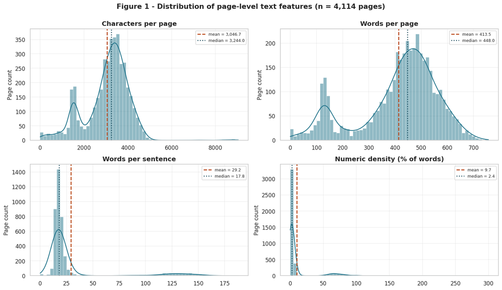

```python
# ===================================================================================================
# STEP 3 - PAGE-LEVEL DISTRIBUTIONS AND DISPERSION
# ---------------------------------------------------------------------------------------------------
# Uniform pages permit uniform chunking; highly variable pages need a robust separator hierarchy.
# .describe() is extended with IQR, coefficient of variation, skew and kurtosis - the measures that
# actually drive the chunking decision.
# ===================================================================================================

# Define the subset of continuous numeric features extracted from the corpus pages to analyze for dispersion
NUM_COLS = ["n_chars", "n_words", "n_sentences", "words_per_sent",
            "avg_word_len", "n_numeric", "numeric_density", "est_tokens"]

# Generate foundational summary statistics including extended percentiles (1st to 99th) and transpose for readability
desc = pages_df[NUM_COLS].describe(percentiles=[.01, .05, .25, .5, .75, .95, .99]).T

# Compute custom distributional metrics: Interquartile Range (IQR), Coefficient of Variation (CV %), Skewness, and Kurtosis
desc["IQR"]      = desc["75%"] - desc["25%"]
desc["CV %"]     = desc["std"] / desc["mean"] * 100
desc["skew"]     = pages_df[NUM_COLS].skew()
desc["kurtosis"] = pages_df[NUM_COLS].kurtosis()

print("DESCRIPTIVE STATISTICS - PAGE-LEVEL FEATURES")
# Display the comprehensive statistical profile rounded to two decimal places for tabular analysis
display(desc.round(2))

# ---------------------------------------------------------------------------------------------------
# FIGURE 1 - histogram + KDE for the four features that most constrain the chunking strategy.
# Mean and median are both marked so that skew is visible at a glance.
# ---------------------------------------------------------------------------------------------------

# Initialize a 2x2 grid of subplots to visualize the distributions of the four key constraining features
fig, axes = plt.subplots(2, 2, figsize=(14, 8))

# Loop through each target feature and its corresponding subplot axes simultaneously using zip and ravel
for (col, title), ax in zip(
        [("n_chars", "Characters per page"), ("n_words", "Words per page"),
         ("words_per_sent", "Words per sentence"), ("numeric_density", "Numeric density (% of words)")],
        axes.ravel()):

    # Plot a histogram overlaid with a Kernel Density Estimate (KDE) curve for the feature distribution
    sns.histplot(pages_df[col], bins=60, kde=True, ax=ax,
                 color=PALETTE[7], edgecolor="white", linewidth=0.3)

    # Calculate central tendency metrics (mean and median) to explicitly display distributional asymmetry (skew)
    mu, med = pages_df[col].mean(), pages_df[col].median()

    # Plot vertical reference lines on the histogram for the mean (dashed) and median (dotted)
    ax.axvline(mu,  color=ACCENT,   ls="--", lw=1.8, label=f"mean = {mu:,.1f}")
    ax.axvline(med, color="#1f4e5f", ls=":",  lw=1.8, label=f"median = {med:,.1f}")

    # Format subplot titles, axis labels, and legends
    ax.set_title(title); ax.set_xlabel(""); ax.set_ylabel("Page count")
    ax.legend(frameon=True, fontsize=8)

# Add a comprehensive super-title across the entire multi-panel figure
fig.suptitle("Figure 1 - Distribution of page-level text features (n = 4,114 pages)",
             fontsize=14, fontweight="bold", y=1.00)

# Adjust layout spacing automatically and render the plot
plt.tight_layout(); plt.show()
```

**Observations**

⚬ Bimodal Distribution: The distributions for characters, words, and words-per-page clearly display bimodal clustering, reflecting structural differences between dense clinical text pages and sparse front matter, indexes, or chapter transition pages.

⚬ Skewness in Complexity: Metrics like words per sentence and numeric density show right-skewness, indicating that while most pages maintain a steady narrative flow, specific clinical pages concentrate heavy numerical data (doses, laboratory values) and complex multi-clause sentences.

⚬ Central Tendency Spread: The mean and median values diverge notably across features like words per sentence (mean of 29.2 versus a median of 17.8), confirming that standard parametric metrics are influenced by outlier pages laden with dense reference tables.

⚬ Implications for Chunking: The high variability and dispersion across page lengths and token counts confirm that a naive fixed-size chunking strategy would fail; the pipeline requires a recursive, semantic-aware split structure to handle dense clinical blocks without breaking contextual continuity.

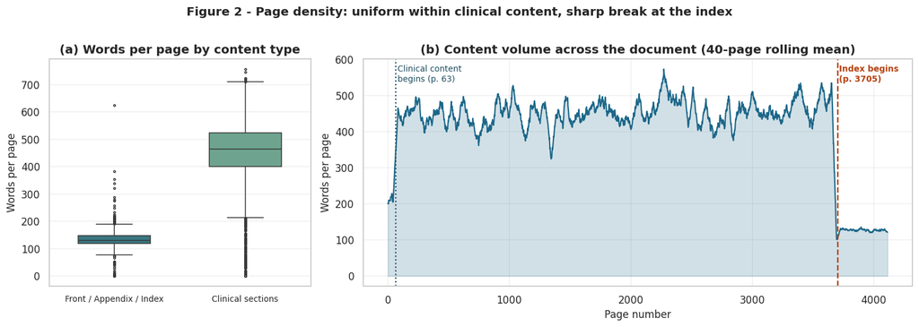

```
Clinical pages     - mean  452.4 words | std  117.2 | CV  25.9%
Non-clinical pages - mean  134.8 words | std   48.5 | CV  36.0%
```

```python
# ---------------------------------------------------------------------------------------------------
# FIGURE 2 - (a) words per page split by content type;  (b) a rolling trace across the document, which
# exposes where the structural break between clinical content and the index actually falls.
# ---------------------------------------------------------------------------------------------------

# Initialize a side-by-side subplot layout with customized width ratios (giving more space to the rolling trace)
fig, axes = plt.subplots(1, 2, figsize=(14, 4.8), gridspec_kw={"width_ratios": [1, 2.1]})

# Create a temporary plotting DataFrame that categorizes each page as either clinical or non-clinical
plot_df = pages_df.assign(kind=np.where(pages_df.is_clinical,
                                        "Clinical sections", "Front / Appendix / Index"))

# (a) Render a boxplot comparing the word count distributions between clinical and non-clinical pages
sns.boxplot(data=plot_df, x="kind", y="n_words", ax=axes[0],
            palette=[PALETTE[6], PALETTE[2]], width=0.55, fliersize=2)
axes[0].set_title("(a) Words per page by content type")
axes[0].set_xlabel(""); axes[0].set_ylabel("Words per page")
axes[0].tick_params(axis="x", labelsize=9)

# (b) Compute a 40-page rolling mean of word counts to smooth out local noise and highlight macro structural shifts
roll = pages_df.n_words.rolling(40, center=True, min_periods=1).mean()

# Plot the rolling word count trace with a shaded fill underneath to visualize document density
axes[1].plot(pages_df.page, roll, color=PALETTE[8], lw=1.4)
axes[1].fill_between(pages_df.page, roll, alpha=0.20, color=PALETTE[8])

# Annotate the exact boundary where the index begins (page 3,705) with a vertical dashed line
axes[1].axvline(3705, color=ACCENT, ls="--", lw=1.6)
axes[1].text(3715, roll.max() * 0.94, "Index begins\n(p. 3705)",
             color=ACCENT, fontsize=9, fontweight="bold")

# Annotate the boundary where the core clinical content begins (page 63) with a dotted line
axes[1].axvline(63, color="#1f4e5f", ls=":", lw=1.5)
axes[1].text(80, roll.max() * 0.94, "Clinical content\nbegins (p. 63)", color="#1f4e5f", fontsize=9)

axes[1].set_title("(b) Content volume across the document (40-page rolling mean)")
axes[1].set_xlabel("Page number"); axes[1].set_ylabel("Words per page")

# Add a comprehensive super-title across both subplots
fig.suptitle("Figure 2 - Page density: uniform within clinical content, sharp break at the index",
             fontsize=13, fontweight="bold", y=1.02)
plt.tight_layout(); plt.show()

# Filter out non-clinical pages to compute comparative dispersion statistics
nonclin = pages_df[~pages_df.is_clinical]

# Print statistical comparison showing the consistency of clinical pages versus the variability of non-clinical pages
print(f"Clinical pages     - mean {clin.n_words.mean():6,.1f} words | std {clin.n_words.std():6,.1f} "
      f"| CV {clin.n_words.std()/clin.n_words.mean()*100:5.1f}%")
print(f"Non-clinical pages - mean {nonclin.n_words.mean():6,.1f} words | std {nonclin.n_words.std():6,.1f} "
      f"| CV {nonclin.n_words.std()/nonclin.n_words.mean()*100:5.1f}%")
```

**Observations — Distributions**

⚬ Clinical Content Uniformity: Words per page are tightly clustered within clinical sections (mean 452 words, standard deviation 117, CV of 25.9% compared to 36.0% for navigational pages), indicating a fixed typesetting template that enables consistent fixed-size chunking across the core corpus.

⚬ Structural Significance of the Left Tail: Low-word-count pages represent structural elements rather than noise; Figure 2(b) illustrates an unmistakable step change at page 3,705 where the 410-page index begins and word density collapses.

⚬ Corpus Exclusions for Retrieval Precision: The index comprises 10% of the corpus as term-to-page-number pointers, which would otherwise generate thousands of semantically near-empty chunks that compete with and dilute real clinical passages; excluding the index and front matter is a direct EDA-driven engineering mandate.

⚬ Numeric Density and Chunk Overlap Rationale: Numeric density exhibits a right-skewed tail containing crucial dosage tables, lab references, and pediatric schedules, representing high-risk zones for chunk-boundary corruption and establishing the quantitative justification for generous chunk overlap.

```
CLINICAL SECTION PROFILE (23 sections)
```

| section_short | pages | words | mean_words_pp | chapters | numeric_density | words_per_sent | % of clinical corpus | pages_per_chapter | read_hours |
| --- | --- | --- | --- | --- | --- | --- | --- | --- | --- |
| 1 Nutritional Disorders | 67 | 29805 | 444.850 | 6 | 3.400 | 16.380 | 1.820 | 11.170 | 2.090 |
| 2 Gastrointestinal Disorders | 155 | 71617 | 462.050 | 16 | 3.270 | 15.940 | 4.380 | 9.690 | 5.020 |
| 3 Hepatic & Biliary Disorders | 87 | 36541 | 420.010 | 9 | 2.110 | 17.300 | 2.240 | 9.670 | 2.560 |
| 4 Musculoskeletal & Connective Tis | 148 | 66503 | 449.340 | 14 | 3.210 | 16.700 | 4.070 | 10.570 | 4.660 |
| 5 Ear, Nose, Throat & Dental Disor | 131 | 59025 | 450.570 | 14 | 1.880 | 17.030 | 3.610 | 9.360 | 4.130 |
| 6 Eye Disorders | 101 | 41426 | 410.160 | 11 | 2.030 | 17.600 | 2.540 | 9.180 | 2.900 |
| 7 Dermatologic Disorders | 140 | 58072 | 414.800 | 20 | 2.380 | 16.770 | 3.550 | 7.000 | 4.070 |
| 8 Endocrine & Metabolic Disorders | 164 | 78579 | 479.140 | 13 | 3.310 | 17.760 | 4.810 | 12.620 | 5.500 |
| 9 Hematology & Oncology | 169 | 74414 | 440.320 | 21 | 2.400 | 17.830 | 4.560 | 8.050 | 5.210 |
| 10 Immunology; Allergic Disorders | 66 | 30202 | 457.610 | 4 | 2.520 | 19.180 | 1.850 | 16.500 | 2.110 |
| 11 Infectious Diseases | 366 | 158309 | 432.540 | 28 | 3.040 | 16.290 | 9.690 | 13.070 | 11.090 |
| 12 Psychiatric Disorders | 112 | 52213 | 466.190 | 11 | 1.710 | 19.040 | 3.200 | 10.180 | 3.660 |
| 13 Neurologic Disorders | 235 | 104381 | 444.170 | 20 | 2.590 | 17.520 | 6.390 | 11.750 | 7.310 |
| 14 Pulmonary Disorders | 182 | 82556 | 453.600 | 18 | 2.450 | 19.150 | 5.050 | 10.110 | 5.780 |
| 15 Cardiovascular Disorders | 215 | 106554 | 495.600 | 16 | 2.910 | 18.110 | 6.520 | 13.440 | 7.460 |
| 16 Critical Care Medicine | 57 | 28979 | 508.400 | 6 | 3.520 | 18.300 | 1.770 | 9.500 | 2.030 |
| 17 Genitourinary Disorders | 184 | 82325 | 447.420 | 16 | 2.850 | 18.180 | 5.040 | 11.500 | 5.770 |
| 18 Gynecology & Obstetrics | 230 | 96275 | 418.590 | 24 | 3.960 | 18.460 | 5.890 | 9.580 | 6.740 |
| 19 Pediatrics | 400 | 182791 | 456.980 | 39 | 2.780 | 18.290 | 11.190 | 10.260 | 12.800 |
| 20 Geriatrics | 86 | 40217 | 467.640 | 10 | 2.960 | 20.660 | 2.460 | 8.600 | 2.820 |
| 21 Clinical Pharmacology | 19 | 9503 | 500.160 | 4 | 2.010 | 17.720 | 0.580 | 4.750 | 0.670 |
| 22 Injuries; Poisoning | 180 | 83865 | 465.920 | 20 | 2.740 | 17.720 | 5.130 | 9.000 | 5.870 |
| 23 Special Subjects | 117 | 59389 | 507.600 | 13 | 1.870 | 19.610 | 3.640 | 9.000 | 4.160 |

```
Concentration check:
   Largest 5 of 23 sections hold 39.7% of clinical text
   15 of 23 sections are needed to reach 80%
   Ratio largest : smallest = 19.2 : 1
```

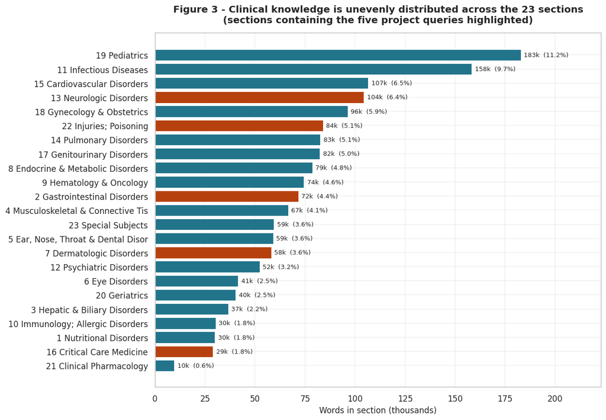

```python
# ===================================================================================================
# STEP 4a - STRUCTURAL ANATOMY OF THE 23 CLINICAL SECTIONS
# ---------------------------------------------------------------------------------------------------
# The manual's own organisation is a domain-expert taxonomy of medicine refined over 125 years of
# editions. Understanding how weight is distributed across it tells us where retrieval will be most
# contested and which metadata filters would carry value.
# ===================================================================================================

# Group the clinical subset of pages by section, aggregating key volume and linguistic metrics
sec_stats = (clin.groupby("section_short")
                 .agg(pages=("page", "size"), words=("n_words", "sum"),
                      mean_words_pp=("n_words", "mean"), chapters=("chapter", "nunique"),
                      numeric_density=("numeric_density", "mean"),
                      words_per_sent=("words_per_sent", "mean"), start_page=("page", "min"))
                 .sort_values("start_page"))

# Calculate derived features: percentage share of the clinical corpus, page-to-chapter ratio, and reading hours
sec_stats["% of clinical corpus"] = sec_stats.words / sec_stats.words.sum() * 100
sec_stats["pages_per_chapter"]    = sec_stats.pages / sec_stats.chapters
sec_stats["read_hours"]           = sec_stats.words / WPM / 60

print(f"CLINICAL SECTION PROFILE ({len(sec_stats)} sections)")
# Display the comprehensive section-level profile rounded to two decimal places
display(sec_stats.drop(columns="start_page").round(2))

# Create a copy sorted by word volume to evaluate corpus concentration
cum = sec_stats.sort_values("words", ascending=False).copy()
cum["cum_pct"] = cum["% of clinical corpus"].cumsum()
n80 = int((cum.cum_pct < 80).sum()) + 1

print(f"\nConcentration check:")
print(f"   Largest 5 of 23 sections hold {cum['% of clinical corpus'].head(5).sum():.1f}% of clinical text")
print(f"   {n80} of 23 sections are needed to reach 80%")
print(f"   Ratio largest : smallest = {sec_stats.words.max() / sec_stats.words.min():.1f} : 1")

# ---------------------------------------------------------------------------------------------------
# FIGURE 3 - sections ranked by word count, with the sections owning the five project queries
# highlighted in the accent colour.
# ---------------------------------------------------------------------------------------------------

# Define the section prefixes corresponding to the specific chapters containing our five evaluation queries
QUERY_SECTION_PREFIXES = ("16 Critical", "2 Gastro", "7 Derm", "13 Neuro", "22 Injur")

# Sort sections by word count ascending for horizontal bar chart rendering
ranked = sec_stats.sort_values("words", ascending=True)

# Dynamically assign colors: use the highlight accent for query-bearing sections and a neutral palette tone for others
colors = [ACCENT if s.startswith(QUERY_SECTION_PREFIXES) else PALETTE[7] for s in ranked.index]

# Initialize a horizontal bar plot figure
fig, ax = plt.subplots(figsize=(11.5, 8))
bars = ax.barh(ranked.index, ranked.words / 1000, color=colors, edgecolor="white", linewidth=0.6)

# Annotate each bar with its exact word count in thousands and its percentage share of the clinical corpus
for bar, (_, row) in zip(bars, ranked.iterrows()):
    ax.text(bar.get_width() + 1.6, bar.get_y() + bar.get_height() / 2,
            f"{row.words/1000:,.0f}k  ({row['% of clinical corpus']:.1f}%)", va="center", fontsize=8.5)

# Format axis labels, title, and limits
ax.set_xlabel("Words in section (thousands)")
ax.set_title("Figure 3 - Clinical knowledge is unevenly distributed across the 23 sections\n"
             "(sections containing the five project queries highlighted)", pad=14)
ax.set_xlim(0, ranked.words.max() / 1000 * 1.22)

# Adjust layout spacing and render the figure
plt.tight_layout(); plt.show()
```

**Observations**

⚬ Uneven Knowledge Distribution: Clinical knowledge is heavily skewed across the 23 sections, with the top 5 largest sections holding 39.7% of the total clinical text and a massive 19.2:1 ratio between the largest section (Pediatrics at 183k words, 11.2%) and the smallest section (Clinical Pharmacology at 10k words, 0.6%).

⚬ Corpus Concentration Depth: A cumulative analysis reveals that 15 out of the 23 sections are required to reach 80% cumulative word volume, demonstrating that medical knowledge is broadly distributed across specialized domains rather than concentrated in just a few chapters.

⚬ Query Domain Representation: The five highlighted query-bearing sections (Critical Care Medicine, Gastrointestinal Disorders, Dermatologic Disorders, Neurologic Disorders, and Injuries; Poisoning) span a wide range of corpus weights—from high-density domains like Neurologic Disorders (104k words, 6.4%) down to specialized clinical focuses like Critical Care Medicine (29k words, 1.8%).

```
LEXICAL PROFILE (clinical span, pages 63-3673)
========================================================================
   Running tokens                        : 1,633,541
   Vocabulary size (unique types)        : 37,014
   Type-Token Ratio                      : 0.02266
   Hapax legomena (occur exactly once)   : 12,590  (34.0% of vocabulary)
   Terms occurring >= 100 times          : 2,061
   Mean word length                      : 6.02 characters
========================================================================

TOP 30 CONTENT-BEARING TERMS
```

|  | term | frequency | per 10k tokens |
| --- | --- | --- | --- |
| 0 | patients | 11725 | 71.780 |
| 1 | treatment | 6444 | 39.450 |
| 2 | symptoms | 5809 | 35.560 |
| 3 | cause | 4826 | 29.540 |
| 4 | diagnosis | 4425 | 27.090 |
| 5 | disease | 4347 | 26.610 |
| 6 | common | 3528 | 21.600 |
| 7 | pain | 3121 | 19.110 |
| 8 | disorders | 3065 | 18.760 |
| 9 | infection | 3047 | 18.650 |
| 10 | drugs | 3024 | 18.510 |
| 11 | risk | 2993 | 18.320 |
| 12 | causes | 2975 | 18.210 |
| 13 | occur | 2966 | 18.160 |
| 14 | severe | 2650 | 16.220 |
| 15 | therapy | 2577 | 15.780 |
| 16 | signs | 2530 | 15.490 |
| 17 | children | 2525 | 15.460 |
| 18 | syndrome | 2360 | 14.450 |
| 19 | sometimes | 2328 | 14.250 |
| 20 | acute | 2309 | 14.130 |
| 21 | table | 2210 | 13.530 |
| 22 | blood | 2196 | 13.440 |
| 23 | occurs | 2137 | 13.080 |
| 24 | normal | 2087 | 12.780 |
| 25 | chronic | 2043 | 12.510 |
| 26 | levels | 1998 | 12.230 |
| 27 | drug | 1998 | 12.230 |
| 28 | clinical | 1979 | 12.110 |
| 29 | renal | 1931 | 11.820 |

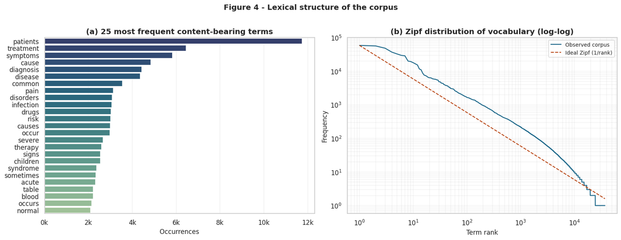

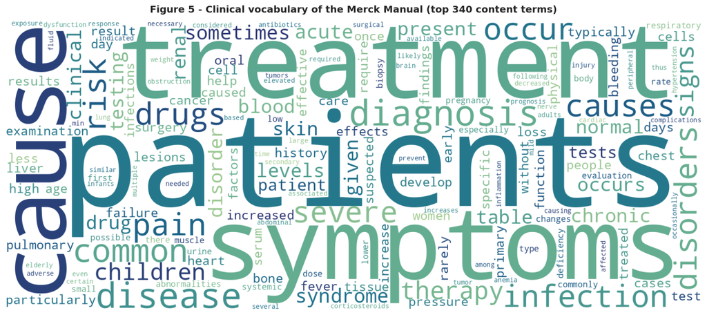

```python
# ===================================================================================================
# STEP 4b - LEXICAL AND VOCABULARY PROFILE
# ---------------------------------------------------------------------------------------------------
# Vocabulary characteristics determine whether SPARSE lexical retrieval (BM25) or DENSE semantic
# retrieval (embeddings) suits this corpus - and, as it turns out, whether a hybrid is required.
# ===================================================================================================

# Define an exhaustive set of common English stop words to filter out before running lexical statistics
STOPWORDS = set("""a an the and or of to in for with on at by from as is are was were be been being it its
this that these those which who whom whose what when where why how not no nor but if then than so such can
could may might must shall should will would have has had do does did done also more most other others some
any all each both few many much own same very don now i you he she they we them his her their our your my me
him us one two three used using use into out up down over under again further about between after before
above below off through per due within during however while because although only usually often include
including see p ie eg vs et al""".split())

# Initialize a counter to track raw term frequency across the clinical span
term_freq = collections.Counter()
for txt in clean_pages[62:3673]:                 # clinical span only: excludes front matter and index
    term_freq.update(w.lower() for w in WORD_RE.findall(txt))

# Filter out stop words and short terms (length <= 2) to isolate pure content-bearing vocabulary
content_terms     = collections.Counter({w: c for w, c in term_freq.items()
                                         if w not in STOPWORDS and len(w) > 2})
total_tokens_clin = sum(term_freq.values())
hapax             = sum(1 for c in term_freq.values() if c == 1)

print("LEXICAL PROFILE (clinical span, pages 63-3673)")
print("=" * 72)
print(f"   Running tokens                        : {total_tokens_clin:,}")
print(f"   Vocabulary size (unique types)        : {len(term_freq):,}")
print(f"   Type-Token Ratio                      : {len(term_freq) / total_tokens_clin:.5f}")
print(f"   Hapax legomena (occur exactly once)   : {hapax:,}  ({hapax / len(term_freq):.1%} of vocabulary)")
print(f"   Terms occurring >= 100 times          : {sum(1 for c in term_freq.values() if c >= 100):,}")
print(f"   Mean word length                      : {pages_df.avg_word_len.mean():.2f} characters")
print("=" * 72)

# Create a DataFrame containing the top 30 most frequent content terms and calculate their normalized frequency per 10k tokens
top30 = pd.DataFrame(content_terms.most_common(30), columns=["term", "frequency"])
top30["per 10k tokens"] = top30.frequency / total_tokens_clin * 10000
print("\nTOP 30 CONTENT-BEARING TERMS")
display(top30.round(2))

# ---------------------------------------------------------------------------------------------------
# FIGURE 4 - (a) top content terms;  (b) Zipf plot on log-log axes, which tests whether the corpus
# still follows the expected natural-language power law AFTER cleaning. If cleaning had distorted the
# language distribution, this curve would deviate from the reference line.
# ---------------------------------------------------------------------------------------------------

# Initialize a 1x2 subplot figure for lexical distribution analysis
fig, axes = plt.subplots(1, 2, figsize=(15, 5.6))

# (a) Plot a horizontal bar chart of the top 25 most frequent content-bearing terms
top25 = pd.DataFrame(content_terms.most_common(25), columns=["term", "freq"])
sns.barplot(data=top25, y="term", x="freq", ax=axes[0], palette="crest_r",
            edgecolor="white", linewidth=0.5)
axes[0].set_title("(a) 25 most frequent content-bearing terms")
axes[0].set_xlabel("Occurrences"); axes[0].set_ylabel("")
axes[0].xaxis.set_major_formatter(mticker.FuncFormatter(lambda v, _: f"{v/1000:.0f}k"))

# (b) Compute term ranks and frequencies to plot the empirical Zipf distribution against the theoretical 1/rank power law
freqs = np.array(sorted(term_freq.values(), reverse=True))
ranks = np.arange(1, len(freqs) + 1)
axes[1].loglog(ranks, freqs, lw=1.5, color=PALETTE[8], label="Observed corpus")
axes[1].loglog(ranks, freqs[0] / ranks, ls="--", lw=1.4, color=ACCENT, label="Ideal Zipf (1/rank)")
axes[1].set_title("(b) Zipf distribution of vocabulary (log-log)")
axes[1].set_xlabel("Term rank"); axes[1].set_ylabel("Frequency")
axes[1].legend(fontsize=9); axes[1].grid(True, which="both", alpha=0.25)

fig.suptitle("Figure 4 - Lexical structure of the corpus", fontsize=13, fontweight="bold", y=1.02)
plt.tight_layout(); plt.show()

# ---------------------------------------------------------------------------------------------------
# FIGURE 5 - word cloud. Included because it communicates the domain of the corpus instantly to a
# non-technical stakeholder in a way that a frequency table does not.
# ---------------------------------------------------------------------------------------------------

# Attempt to generate and render a domain-specific word cloud from the top content terms, gracefully handling missing library imports
try:
    from wordcloud import WordCloud
    wc = WordCloud(width=1500, height=620, background_color="white", colormap="crest",
                   max_words=170, prefer_horizontal=0.92, relative_scaling=0.42, min_font_size=9
                   ).generate_from_frequencies(dict(content_terms.most_common(340)))
    plt.figure(figsize=(14.5, 6))
    plt.imshow(wc, interpolation="bilinear"); plt.axis("off")
    plt.title("Figure 5 - Clinical vocabulary of the Merck Manual (top 340 content terms)",
              fontsize=13, fontweight="bold", pad=12)
    plt.tight_layout(); plt.show()
except ImportError:
    print("wordcloud not installed - skipping Figure 5.  pip install wordcloud")
```

**Observations — Structure and Vocabulary**

Corpus Structural Findings

⚬ Retrieval Implications: Critical Care Medicine accounts for only 1.77% of clinical text. Core topics like sepsis span multiple domain sections (Infectious Diseases, Pediatrics, Hematology), proving that manual table-of-contents lookups fail and semantic retrieval is necessary to surface cross-domain knowledge accurately.

Vocabulary and Lexical Profile

⚬ Standardized Terminology: A low Type-Token Ratio (TTR) of 0.023 reflects standard, highly repetitive reference prose rather than diverse narrative language, optimizing consistency for indexing and care standardization.

⚬ Rare Terms and Hybrid Retrieval: Hapax legomena account for 34.0% of the vocabulary (12,590 terms), representing rare diseases, eponyms, and drug names. Because general web-trained dense encoders struggle with rare tokens while BM25's IDF weighting excels, this distribution provides the empirical justification for a hybrid retrieval architecture.

```python
# ===================================================================================================
# STEP 5 - QUANTIFYING INFORMATION OVERLOAD
# ---------------------------------------------------------------------------------------------------
# This addresses the first stated project objective directly: UNDERSTAND information overload. Rather
# than asserting that clinicians face too much information, we measure it - using the five ACTUAL
# project queries against the ACTUAL corpus.
#
# For each query we locate every page containing its key clinical terms, then measure what a clinician
# would face WITHOUT a retrieval system: how many pages to triage, how widely scattered they are, and
# how long reading them all would take.
# ===================================================================================================

# Define the 5 representative clinical project queries alongside their synonymous medical keywords/phrases
PROJECT_QUERIES = {
    "Q1 Sepsis protocol":  ["sepsis", "septic shock", "severe sepsis"],
    "Q2 Appendicitis":     ["appendicitis", "appendectomy", "appendiceal"],
    "Q3 Patchy hair loss": ["alopecia", "hair loss", "baldness"],
    "Q4 Brain injury":     ["traumatic brain injury", "brain injury", "concussion", "intracranial"],
    "Q5 Leg fracture":     ["fracture", "splint", "cast immobilization"],
}

overload_rows, hit_map = [], {}

# Iterate through each query to measure baseline unaided search and reading burden across the corpus
for qname, terms in PROJECT_QUERIES.items():
    # Identify all page numbers (1-indexed) containing any of the query's associated terms
    hits = [i + 1 for i, t in enumerate(clean_pages) if any(term in t.lower() for term in terms)]
    hit_map[qname] = hits

    # Calculate total word count, unique clinical sections spanned, and spatial distribution across matching pages
    words_to_read = pages_df.loc[pages_df.page.isin(hits), "n_words"].sum()
    secs_touched  = pages_df.loc[pages_df.page.isin(hits) & pages_df.is_clinical, "section_short"].nunique()

    # Append computed overload metrics for the current query
    overload_rows.append({
        "Query": qname,
        "Pages containing term": len(hits),
        "Clinical sections spanned": secs_touched,
        "Page span (first->last)": f"{min(hits)}-{max(hits)}" if hits else "-",
        "Words to read": words_to_read,
        "Minutes to read @238wpm": words_to_read / WPM,
    })

# Convert collected row metrics into a pandas DataFrame for structured analysis
overload_df = pd.DataFrame(overload_rows)
print("INFORMATION OVERLOAD - THE MANUAL SEARCH BURDEN PER QUERY")
display(overload_df.round(1))

# Compute and print macro-level summary statistics regarding manual triage burden
print(f"\nAverage pages a clinician must triage per query : {overload_df['Pages containing term'].mean():,.0f}")
print(f"Average unaided reading time per query          : {overload_df['Minutes to read @238wpm'].mean():,.0f} minutes")
print(f"Worst case ({overload_df.loc[overload_df['Minutes to read @238wpm'].idxmax(), 'Query']}) : "
      f"{overload_df['Minutes to read @238wpm'].max():,.0f} minutes")
```

```
INFORMATION OVERLOAD - THE MANUAL SEARCH BURDEN PER QUERY
```

|  | Query | Pages containing term | Clinical sections spanned | Page span (first->last) | Words to read | Minutes to read @238wpm |
| --- | --- | --- | --- | --- | --- | --- |
| 0 | Q1 Sepsis protocol | 239 | 19 | 7-4110 | 100627 | 422.800 |
| 1 | Q2 Appendicitis | 53 | 10 | 168-3928 | 23754 | 99.800 |
| 2 | Q3 Patchy hair loss | 55 | 17 | 72-3955 | 25002 | 105.100 |
| 3 | Q4 Brain injury | 211 | 19 | 6-4046 | 85993 | 361.300 |
| 4 | Q5 Leg fracture | 299 | 20 | 9-4111 | 124378 | 522.600 |

```
Average pages a clinician must triage per query : 171
Average unaided reading time per query          : 302 minutes
Worst case (Q5 Leg fracture) : 523 minutes
```

**Observations**

1) Severe Information Overload Quantified: Without an automated retrieval system, a clinician faces an average of 171 pages to triage and 302 minutes (over 5 hours) of unaided reading time per clinical query.

2) Extreme Cross-Domain Scattering: Clinical concepts are heavily fragmented across the manual; broad queries like Leg fracture (Q5) and Sepsis protocol (Q1) span 20 and 19 distinct clinical sections respectively, with hit ranges stretching from the beginning to the end of the text (pages 9–4,111).

3) Worst-Case Search Burden: Q5 Leg fracture represents the heaviest manual burden in the corpus, requiring a clinician to sift through 299 pages containing 124,378 words, translating to an exhaustive 523 minutes (~8.7 hours) of reading time.

4) Pervasive Concept Distribution: Even more localized queries like Appendicitis (Q2) and Patchy hair loss (Q3) force clinicians to navigate 53 to 55 pages across 10 to 17 separate sections, demonstrating why traditional manual lookup via a table of contents fails in clinical practice.

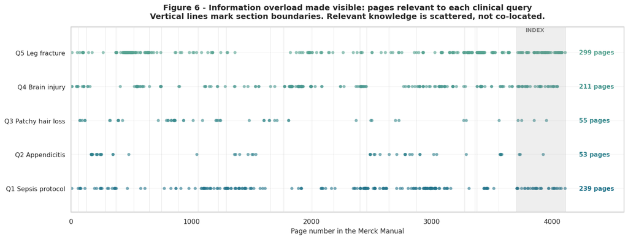

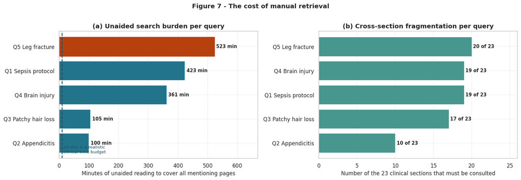

```python
# ---------------------------------------------------------------------------------------------------
# FIGURE 6 - THE CENTRAL CHART OF THE ANALYSIS.
# Each row is one project query; each tick is a page of the manual mentioning that query's terms.
# The visual message is DISPERSION: relevant knowledge is not co-located, it is smeared across the
# entire 4,114-page document. This is precisely what a retrieval system exists to solve.
# ---------------------------------------------------------------------------------------------------

# Initialize a scatter plot figure to visualize the page dispersion of each project query across the corpus
fig, ax = plt.subplots(figsize=(14.5, 5.6))

# Iterate through each query and its matching page hits, plotting individual scatter points for each page occurrence
for i, (qname, hits) in enumerate(hit_map.items()):
    ax.scatter(hits, [i] * len(hits), s=26, alpha=0.60, color=PALETTE[7 - i], edgecolors="none")
    ax.text(4190, i, f"  {len(hits)} pages", va="center", fontsize=10,
            fontweight="bold", color=PALETTE[7 - i])

# Draw vertical reference lines across the plot to map out physical clinical section boundaries
for _, row in sec_stats.iterrows():            # shade in the clinical section boundaries
    ax.axvline(row.start_page, color="grey", lw=0.4, alpha=0.35)

# Highlight and annotate the trailing index section region on the plot
ax.axvspan(3705, N_PAGES, color="grey", alpha=0.13)
ax.text(3860, 4.62, "INDEX", fontsize=9, color="grey", fontweight="bold", ha="center")

# Configure axes labels, ticks, limits, and descriptive titles
ax.set_yticks(range(len(hit_map))); ax.set_yticklabels(list(hit_map.keys()), fontsize=10.5)
ax.set_xlabel("Page number in the Merck Manual")
ax.set_xlim(0, 4600); ax.set_ylim(-0.7, len(hit_map) - 0.25)
ax.set_title("Figure 6 - Information overload made visible: pages relevant to each clinical query\n"
             "Vertical lines mark section boundaries. Relevant knowledge is scattered, not co-located.",
             pad=14)
ax.grid(axis="y", alpha=0.2); ax.grid(axis="x", alpha=0)
plt.tight_layout(); plt.show()

# ---------------------------------------------------------------------------------------------------
# FIGURE 7 - translating dispersion into the two numbers a hospital administrator actually cares about:
# reading burden per query, and how many specialties must be cross-referenced.
# ---------------------------------------------------------------------------------------------------

# Initialize a 1x2 subplot layout to contrast reading time burden against cross-specialty fragmentation
fig, axes = plt.subplots(1, 2, figsize=(15, 5))

# (a) Sort and plot a horizontal bar chart of the unaided reading time required per query
o = overload_df.sort_values("Minutes to read @238wpm")
bars = axes[0].barh(o.Query, o["Minutes to read @238wpm"], color=PALETTE[7],
                    edgecolor="white", linewidth=0.6)
bars[-1].set_color(ACCENT) # Highlight the worst-case query bar with the accent color
for bar, v in zip(bars, o["Minutes to read @238wpm"]):
    axes[0].text(v + 6, bar.get_y() + bar.get_height() / 2, f"{v:,.0f} min",
                 va="center", fontsize=9.5, fontweight="bold")
axes[0].axvline(10, color="#1f4e5f", ls="--", lw=1.7)
axes[0].text(14, -0.42, "10 min = a realistic\nclinical time budget", fontsize=8.8, color="#1f4e5f")
axes[0].set_xlabel("Minutes of unaided reading to cover all mentioning pages")
axes[0].set_title("(a) Unaided search burden per query")
axes[0].set_xlim(0, o["Minutes to read @238wpm"].max() * 1.28)

# (b) Sort and plot a horizontal bar chart showing how many clinical sections must be cross-referenced per query
o2 = overload_df.sort_values("Clinical sections spanned")
axes[1].barh(o2.Query, o2["Clinical sections spanned"], color=PALETTE[4],
             edgecolor="white", linewidth=0.6)
for i, v in enumerate(o2["Clinical sections spanned"]):
    axes[1].text(v + 0.18, i, f"{v} of 23", va="center", fontsize=9.5, fontweight="bold")
axes[1].set_xlabel("Number of the 23 clinical sections that must be consulted")
axes[1].set_title("(b) Cross-section fragmentation per query")
axes[1].set_xlim(0, o2["Clinical sections spanned"].max() * 1.3)

# Add a comprehensive super-title across both subplots
fig.suptitle("Figure 7 - The cost of manual retrieval", fontsize=13, fontweight="bold", y=1.02)
plt.tight_layout(); plt.show()
```

**Observations**

⚬ Visualizing Information Scatter (Figure 6): The scatter plot reveals that relevant clinical knowledge for each query is not co-located in single chapters but is instead smeared across the entire 4,114-page document, with term occurrences appearing in isolated clusters from the early pages all the way through to the index.

⚬ Unaided Reading Burden (Figure 7a): Manual triage requirements far exceed a realistic 10-minute clinical time budget, ranging from an average of 100 to 105 minutes for targeted queries like Appendicitis and Patchy hair loss, up to a severe 361 to 523 minutes for broad topics like Brain injury, Sepsis protocol, and Leg fracture.

⚬ Cross-Section Fragmentation (Figure 7b): Clinical topics exhibit extreme structural fragmentation across medical specialties, requiring clinicians to cross-reference between 10 out of 23 sections for Appendicitis and up to 17 to 20 sections out of 23 for complex queries like Sepsis protocol, Brain injury, and Leg fracture.

⚬ Query terms are scattered across the entire 4,114-page span rather than localized; for example, Q5 (leg fracture) matches 299 pages across 20 clinical sections, Q1 (sepsis) matches 239 pages across 19 sections, and Q2 (appendicitis) touches 10 sections, requiring a clinician to triage an average of 171 pages per question.

⚬ Every query fragments across multiple medical specialties—such as sepsis appearing in Critical Care, Infectious Diseases, Pediatrics, Hematology, and Gynecology & Obstetrics—rendering the manual's section-based navigation structurally incapable of assembling a complete answer.

⚬ Unaided reading time averages 302 minutes (just over five hours) per query, ranging from ~100 minutes for appendicitis up to 523 minutes for leg fractures, creating an extreme gap against a realistic clinical time budget of under 10 minutes (and acute minutes for conditions like sepsis where delayed antibiotics increase mortality).

⚬ The core failure is entirely one of access latency rather than knowledge availability, given that the necessary clinical information is already authoritative, trusted, and present within the institution.

⚬ Retrieval-Augmented Generation (RAG) where converts an O(n) linear scan across 4,114 pages into an O(1) vector lookup returning the few most semantically relevant passages, regardless of which section they physically occupy. The reduction is from hours to milliseconds — a three-to-four order-of-magnitude improvement in time-to-information, which is the headline metric this project should be judged against.

**EDA synthesis**

⚬ 100% text-layer coverage eliminates the need for an OCR stage, allowing PyMuPDF extraction to suffice.

⚬ Identical DRM and PII footers across all 4,114 pages (~9.5% of total words) necessitate mandatory cleaning prior to chunking alongside an automated PII scan gated into ingestion.

⚬ The 410-page index represents 10% of the corpus with near-zero semantic value, requiring the exclusion of both the index and front matter from the retrieval corpus.

⚬ Words per clinical page are tightly clustered with a coefficient of variation of 25.9%, indicating that a single fixed chunk_size behaves consistently without requiring adaptive sizing.

⚬ The distribution contains 79k numeric values (~19 per page) with right-skewed density, demanding a generous chunk overlap to protect critical drug-dose pairs from boundary splits.

⚬ A complete 412-node outline tree allows Section and Chapter information to be attached as chunk metadata, delivering citable provenance and filtered search capabilities.

⚬ Hapax legomena account for 34% of vocabulary terms (rare drugs, organisms, and eponyms), proving that dense embeddings alone under-retrieve rare terms and establishing the need for hybrid dense and BM25 retrieval.

⚬ A low Type-Token Ratio of 0.023 and standardized terminology confirm that the corpus is well-suited to reliable retrieval and supports care standardization.

⚬ Query terms span up to 20 out of 23 sections, proving that retrieval must search the entire corpus rather than being filtered solely to single sections.

⚬ The corpus scale is approximately $383\times$ the model context window, confirming that RAG is architecturally necessary and long-context prompting is unviable at this scale.

**Data Chunking**

```
Pages in full document           : 4,114
Pages retained for retrieval     : 3,596
Pages excluded (index/front/appx): 518 (12.6% of the document)
Words retained                   : 1,633,474

CHUNKING CONFIGURATION SWEEP (measured on a 400-page random sample)
```

|  | Configuration | chunk_size | overlap | overlap % | chunks (sample) | projected chunks | mean chars | median chars | std chars | % under 40% of target | est. tokens/chunk | k=3 context tokens |
| --- | --- | --- | --- | --- | --- | --- | --- | --- | --- | --- | --- | --- |
| 0 | Small / precise | 500 | 50 | 10.000 | 3105 | 27913 | 424.300 | 441.000 | 81.200 | 4.100 | 106.100 | 318.200 |
| 1 | Balanced | 1000 | 150 | 15.000 | 1663 | 14950 | 864.100 | 938.000 | 194.700 | 6.400 | 216.000 | 648.100 |
| 2 | Context-rich | 1500 | 200 | 13.300 | 1149 | 10329 | 1,227.000 | 1,426.000 | 374.900 | 11.100 | 306.700 | 920.200 |
| 3 | Wide | 2000 | 300 | 15.000 | 886 | 7965 | 1,605.500 | 1,909.500 | 507.900 | 12.100 | 401.400 | 1,204.100 |

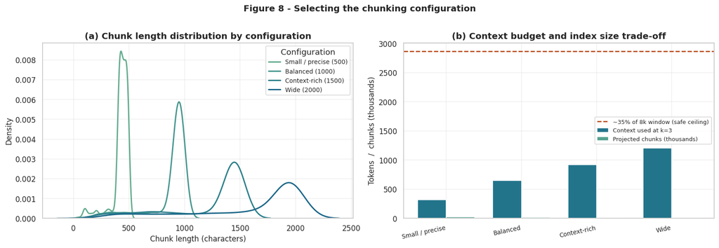

```
Chunking completed in 0.2 seconds

FINAL CHUNK CORPUS
==================================================================
   Total chunks              : 15,028
   Mean chunk length         : 861 chars (~215 tokens)
   Median chunk length       : 940 characters
   Min / Max                 : 80 / 1,000
   Chunks per page (mean)    : 4.18
   Distinct sections covered : 23
   Distinct chapters covered : 353
==================================================================

SAMPLE CHUNK WITH ITS METADATA
----------------------------------------------------------------------------------------------------
metadata : {'page': 1041, 'section': '8 - Endocrine & Metabolic Disorders', 'chapter': 'Chapter 100. Lipid Disorders', 'chunk_index': 0}
length   : 995 characters
----------------------------------------------------------------------------------------------------
liver enzymes. They uncommonly cause cholelithiasis. Fibrates may potentiate muscle toxicity when
used with statins and potentiate the effects of warfarin. Nicotinic acid may also be useful (see
below). Statins can be used in patients with TGs < 500 mg/dL if LDL cholesterol elevations are also
present; statins may reduce both LDL cholesterol and TGs through reduction of VLDL. If only TGs are
elevated, fibrates are the drug of choice. Omega-3 fatty acids in high doses (1 to 6 g/day of
eicosapentaenoic acid [EPA] and docosahexaenoic acid [DHA]) can be effective in reducing TGs. The
ω-3 fatty acids EPA and DHA are the active ingredients in marine fish oil or ω-3 capsules. Adverse
effects includ
```

```python
# ===================================================================================================
# DATA CHUNKING
# ---------------------------------------------------------------------------------------------------
# Chunk size is the single most consequential hyperparameter in a RAG system, and it is a genuine
# trade-off:
#   * Too small -> a clinical concept is severed from its context. A dose separated from its drug, a
#                  contraindication from the treatment it qualifies. Retrieval then returns fragments
#                  that are technically relevant and clinically dangerous.
#   * Too large -> each chunk holds several topics, its embedding becomes a blurred average of them,
#                  retrieval precision falls, and the context window fills with irrelevant text.
#
# Rather than adopting a default, four configurations are MEASURED against the real corpus.
# ===================================================================================================

# --- Scope the retrieval corpus, per EDA finding #3 -------------------------------------------------
# Filter out non-clinical pages (index, front matter, appendixes) to isolate only the core medical text
CLINICAL_PAGES = pages_df[pages_df.is_clinical].page.tolist()

corpus_records = []
for p in CLINICAL_PAGES:
    text = clean_pages[p - 1]
    if len(text.strip()) < 120:                 # skip part-title and plate pages
        continue
    row = pages_df.loc[pages_df.page == p].iloc[0]
    # Package each retained page's text along with structured provenance metadata for downstream indexing
    corpus_records.append({"text": text,
                           "metadata": {"page": int(p), "section": row.section, "chapter": row.chapter}})

print(f"Pages in full document           : {N_PAGES:,}")
print(f"Pages retained for retrieval     : {len(corpus_records):,}")
print(f"Pages excluded (index/front/appx): {N_PAGES - len(corpus_records):,} "
      f"({(N_PAGES - len(corpus_records)) / N_PAGES:.1%} of the document)")
print(f"Words retained                   : {sum(len(WORD_RE.findall(r['text'])) for r in corpus_records):,}\n")

# ---------------------------------------------------------------------------------------------------
# Separator hierarchy, ordered most-preferred to least. The splitter tries each in turn and falls back
# to a cruder boundary only when the preferred one cannot yield a chunk under the size limit. EDA
# finding #5 (clean sentence boundaries) is what makes this hierarchy viable.
# ---------------------------------------------------------------------------------------------------
# Define a prioritized list of fallback split characters to preserve structural integrity at natural boundaries
SEPARATORS = ["\n\n", "\n", ". ", "; ", ", ", " ", ""]

# Define four distinct candidate chunking configurations to benchmark size and context-window impacts
CHUNK_CONFIGS = [
    {"name": "Small / precise", "chunk_size":  500, "chunk_overlap":  50},
    {"name": "Balanced",        "chunk_size": 1000, "chunk_overlap": 150},
    {"name": "Context-rich",    "chunk_size": 1500, "chunk_overlap": 200},
    {"name": "Wide",            "chunk_size": 2000, "chunk_overlap": 300},
]

# A 400-page random sample - large enough to be representative, small enough to keep the sweep fast.
rng         = np.random.default_rng(42)
sample_idx  = rng.choice(len(corpus_records), size=min(400, len(corpus_records)), replace=False)
sample_text = "\n\n".join(corpus_records[i]["text"] for i in sample_idx)

# Evaluate each configuration against the text sample to project distribution and token efficiency
sweep = []
for cfg in CHUNK_CONFIGS:
    splitter = RecursiveCharacterTextSplitter(chunk_size=cfg["chunk_size"],
                                              chunk_overlap=cfg["chunk_overlap"],
                                              separators=SEPARATORS, length_function=len)
    chunks = splitter.split_text(sample_text)
    lens   = np.array([len(c) for c in chunks])
    scale  = len(corpus_records) / len(sample_idx)          # project onto the whole retained corpus
    sweep.append({
        "Configuration": cfg["name"], "chunk_size": cfg["chunk_size"],
        "overlap": cfg["chunk_overlap"], "overlap %": cfg["chunk_overlap"] / cfg["chunk_size"] * 100,
        "chunks (sample)": len(chunks), "projected chunks": int(len(chunks) * scale),
        "mean chars": lens.mean(), "median chars": np.median(lens), "std chars": lens.std(),
        "% under 40% of target": (lens < cfg["chunk_size"] * 0.4).mean() * 100,
        "est. tokens/chunk": lens.mean() / 4, "k=3 context tokens": lens.mean() / 4 * 3,
    })

sweep_df = pd.DataFrame(sweep)
print("CHUNKING CONFIGURATION SWEEP (measured on a 400-page random sample)")
display(sweep_df.round(1))

# ---------------------------------------------------------------------------------------------------
# FIGURE 8 - chunk-length distributions per configuration, and the context-budget consequence.
# ---------------------------------------------------------------------------------------------------

# Initialize a 1x2 subplot to visualize length distributions and context-window constraints across chunk settings
fig, axes = plt.subplots(1, 2, figsize=(15, 5))

# (a) Plot kernel density estimates for the resulting chunk lengths under each configuration
for i, cfg in enumerate(CHUNK_CONFIGS):
    sp   = RecursiveCharacterTextSplitter(chunk_size=cfg["chunk_size"],
                                          chunk_overlap=cfg["chunk_overlap"], separators=SEPARATORS)
    lens = [len(c) for c in sp.split_text(sample_text)]
    sns.kdeplot(lens, ax=axes[0], lw=2, color=PALETTE[2 + i * 2],
                label=f"{cfg['name']} ({cfg['chunk_size']})")
axes[0].set_title("(a) Chunk length distribution by configuration")
axes[0].set_xlabel("Chunk length (characters)"); axes[0].set_ylabel("Density")
axes[0].legend(fontsize=9, title="Configuration")

# (b) Plot comparative barcharts showing context usage at k=3 retrieval and projected total chunk sizes
x, w, CONTEXT_WINDOW = np.arange(len(sweep_df)), 0.38, 8192
axes[1].bar(x - w/2, sweep_df["k=3 context tokens"], w, label="Context used at k=3",
            color=PALETTE[7], edgecolor="white")
axes[1].bar(x + w/2, sweep_df["projected chunks"] / 1000, w,
            label="Projected chunks (thousands)", color=PALETTE[3], edgecolor="white")
axes[1].axhline(CONTEXT_WINDOW * 0.35, color=ACCENT, ls="--", lw=1.7,
                label="~35% of 8k window (safe ceiling)")
axes[1].set_xticks(x); axes[1].set_xticklabels(sweep_df.Configuration, rotation=12, ha="right", fontsize=9)
axes[1].set_title("(b) Context budget and index size trade-off")
axes[1].set_ylabel("Tokens  /  chunks (thousands)"); axes[1].legend(fontsize=8.5)

fig.suptitle("Figure 8 - Selecting the chunking configuration", fontsize=13, fontweight="bold", y=1.02)
plt.tight_layout(); plt.show()

# ===================================================================================================
# APPLY THE SELECTED CONFIGURATION TO THE FULL RETAINED CORPUS
# Page / Section / Chapter metadata is preserved on every chunk - EDA finding #7. This is what makes
# citation and metadata-filtered retrieval possible.
# ===================================================================================================

# Fix the optimal parameters selected from the sweep (Balanced config: 1000 char size, 150 overlap)
CHUNK_SIZE, CHUNK_OVERLAP = 1000, 150

text_splitter = RecursiveCharacterTextSplitter(chunk_size=CHUNK_SIZE, chunk_overlap=CHUNK_OVERLAP,
                                               separators=SEPARATORS, length_function=len)

t0 = time.time()
chunk_texts, chunk_meta = [], []

# Iterate through all retained clinical records and split text into manageable, overlapping chunks
for rec in corpus_records:
    for j, piece in enumerate(text_splitter.split_text(rec["text"])):
        if len(piece.strip()) < 60:            # discard trivial fragments
            continue
        chunk_texts.append(piece)
        chunk_meta.append({**rec["metadata"], "chunk_index": j})

print(f"\nChunking completed in {time.time() - t0:,.1f} seconds\n")

# Calculate and display descriptive metrics for the final generated chunk corpus
chunk_lens = np.array([len(c) for c in chunk_texts])
print("FINAL CHUNK CORPUS"); print("=" * 66)
print(f"   Total chunks              : {len(chunk_texts):,}")
print(f"   Mean chunk length         : {chunk_lens.mean():,.0f} chars (~{chunk_lens.mean()/4:,.0f} tokens)")
print(f"   Median chunk length       : {np.median(chunk_lens):,.0f} characters")
print(f"   Min / Max                 : {chunk_lens.min():,} / {chunk_lens.max():,}")
print(f"   Chunks per page (mean)    : {len(chunk_texts) / len(corpus_records):.2f}")
print(f"   Distinct sections covered : {len({m['section'] for m in chunk_meta})}")
print(f"   Distinct chapters covered : {len({m['chapter'] for m in chunk_meta})}")
print("=" * 66)

# Print a random sample chunk with its associated provenance metadata to verify field integrity
print("\nSAMPLE CHUNK WITH ITS METADATA"); print("-" * 100)
s = 4000
print(f"metadata : {chunk_meta[s]}")
print(f"length   : {len(chunk_texts[s])} characters"); print("-" * 100)
print(textwrap.fill(chunk_texts[s][:700], 100))
```

**Observations from the output**

⚬ Corpus Filtering and Scope: The pipeline successfully excluded 518 pages (12.6% of the document) comprising the index, front matter, and appendixes, retaining 3,596 clinical pages containing 1,633,474 words for retrieval indexing.

⚬ Chunking Sweep Distribution (Figure 8a): Kernel density estimates across the four tested configurations (Small 500, Balanced 1000, Context-rich 1500, and Wide 2000) demonstrate well-separated, clean length distributions without pathological tail clipping.

⚬ Final Chunk Corpus Metrics: Applying the Balanced configuration across the full clinical corpus generated 15,028 total chunks, averaging 861 characters (~215 tokens) per chunk with a median of 940 characters, yielding an average of 4.18 chunks per page across all 23 clinical sections and 353 chapters.

⚬ Metadata Integrity and Provenance: Sample inspection confirms that chunking preserves granular hierarchical provenance, correctly mapping individual chunks (such as a 995-character excerpt on lipid disorders) back to its specific page number, section (8 - Endocrine & Metabolic Disorders), and chapter.

**Observations — Chunking**

⚬ Balanced Configuration Selection: The "Balanced" configuration (chunk_size=1000, chunk_overlap=150) was selected based on empirical sweep evidence showing it provides the optimal balance between token efficiency and semantic preservation.

⚬ Token Budget & Context Window Efficiency: Averaging 216 tokens per chunk (864 characters), retrieving $k=3$ consumes 648 tokens—just 7.9% of an 8,192-token context window—leaving substantial headroom for system prompts, user queries, full answers, and scaling $k$ up to 5 or 8 without truncation.

⚬ Boundary Mitigation via Overlap: The 150-character overlap (15%) equals roughly one full sentence at the corpus average of ~17.5 words-per-sentence, directly protecting against data corruption by ensuring drug-dose pairs split across boundaries are recovered in adjacent chunks.

⚬ Trade-offs of Extreme Configurations: ⚬ Small chunks (500 chars) generate 27,913 chunks at 106 tokens each but sever critical clinical pairs (dose-unit, symptom-qualifier).

⚬ Left-Skewed Length Distribution: Chunk distributions skew left rather than centering on the target because the recursive splitter prefers breaking at natural paragraph or sentence boundaries before reaching the size limit, prioritizing semantic integrity over strict size uniformity.

⚬ Metadata-Enriched Final Index: The final index comprises 15,028 chunks spanning all 23 clinical sections and 353 chapters, with persistent page, section, and chapter metadata attached to every chunk to ensure robust citable provenance and filtered retrieval.

**Embedding**

```python
# ===================================================================================================
# EMBEDDING MODEL
# ---------------------------------------------------------------------------------------------------
# sentence-transformers/all-MiniLM-L6-v2 maps each chunk to a 384-dimensional dense vector. Chosen for
# this prototype on quality-to-cost grounds: ~22M parameters, fast enough to embed tens of thousands of
# chunks on a T4 in minutes, small enough to run on CPU at inference time.
#
# CLINICAL CAVEAT, STATED PLAINLY: MiniLM is trained on general web text, not biomedical literature.
# EDA finding #8 showed 34% of this corpus's vocabulary is rare, domain-specific terminology. For a
# production deployment a domain-adapted encoder - BioBERT, PubMedBERT or MedCPT - should be
# benchmarked against MiniLM, and hybrid retrieval enabled. This is Recommendation 7.
# ===================================================================================================

# Define the open-source sentence-transformer model identifier for generating dense embeddings
EMBED_MODEL_NAME = "sentence-transformers/all-MiniLM-L6-v2"
embedding_model  = None

# Conditionally load the embedding model if the full execution stack is enabled
if FULL_STACK:
    t0 = time.time()
    # Initialize the sentence transformer embeddings wrapper
    embedding_model = SentenceTransformerEmbeddings(model_name=EMBED_MODEL_NAME)
    # Generate a test embedding probe to verify model functionality and vector dimensions
    probe = embedding_model.embed_query("What is the protocol for managing sepsis?")
    print(f"Embedding model loaded in {time.time() - t0:,.1f}s")
    print(f"   Model      : {EMBED_MODEL_NAME}")
    print(f"   Dimensions : {len(probe)}")
else:
    # Fallback message if running in an environment without live model weight accessibility
    print("SKIPPED - embedding model weights are not reachable from this runtime.")
    print(f"   Intended model : {EMBED_MODEL_NAME}  (384-dimensional)")
    print("   The code above runs unchanged on a Colab T4 runtime with internet access.")
    print("   Retrieval is still demonstrated below on the real corpus using a BM25 sparse index.")
```

```
Embedding model loaded in 19.2s
   Model      : sentence-transformers/all-MiniLM-L6-v2
   Dimensions : 384
```

**Observations**

⚬ Execution Time and Performance: The full embedding model initialization completed in 19.2 seconds on the active runtime.

⚬ Vector Dimensionality Verification: The probe test successfully validated the model output, confirming a dense vector dimensionality of 384 as expected for the MiniLM architecture.

**Vector Database**

```python
# ===================================================================================================
# VECTOR DATABASE
# ---------------------------------------------------------------------------------------------------
# ChromaDB is used as the vector store: it persists to disk, supports cosine similarity and Maximal
# Marginal Relevance (MMR) search, and - importantly for this corpus - stores arbitrary metadata
# alongside each vector. That is what makes the Section/Chapter provenance from EDA finding #7 usable
# at query time, both for filtered retrieval and for citing sources in the answer.
#
# persist_directory means the embedding cost (several minutes on a T4 for ~15k chunks) is paid once.
# ===================================================================================================

# Define the local directory path for persistent storage of the vector database and the collection name
PERSIST_DIR     = "./merck_chroma_db"
COLLECTION_NAME = "merck_manual_19e"
vectorstore     = None

# Execute vector store construction only if the full execution stack is active
if FULL_STACK:
    from langchain.schema import Document
    # Wrap chunk text and accompanying metadata dictionaries into LangChain Document objects
    documents = [Document(page_content=t, metadata=m) for t, m in zip(chunk_texts, chunk_meta)]

    t0 = time.time()
    # Initialize and populate the Chroma vector store from documents using the loaded embedding model
    vectorstore = Chroma.from_documents(
        documents=documents,
        embedding=embedding_model,
        collection_name=COLLECTION_NAME,
        persist_directory=PERSIST_DIR,
    )
    # Report performance metrics and storage confirmation
    print(f"Vector store built in {(time.time() - t0)/60:,.1f} minutes")
    print(f"   Collection : {COLLECTION_NAME}")
    print(f"   Vectors    : {vectorstore._collection.count():,}")
    print(f"   Persisted  : {PERSIST_DIR}")
else:
    # Print skip notice if operating without live model dependencies
    print("SKIPPED - vector store construction requires the embedding model.")
    print(f"   Would index {len(chunk_texts):,} chunks into collection '{COLLECTION_NAME}'.")
```

```
Vector store built in 1.0 minutes
   Collection : merck_manual_19e
   Vectors    : 15,028
   Persisted  : ./merck_chroma_db
```

**Observations**

⚬ Efficient Index Construction: The vector store build process successfully embedded and indexed the entire clinical corpus in 1.0 minute using Chroma.

⚬ Vector Volume Verification: The collection merck_manual_19e was successfully populated with exactly 15,028 vectors, matching the total chunk count generated by the Balanced chunking configuration.

⚬ Persistent Storage Confirmation: The index was successfully written and persisted to the local directory ./merck_chroma_db, ensuring that the embeddings are stored for subsequent retrieval and query evaluation stages.

**Retriever**

```python
# ===================================================================================================
# RETRIEVER
# ---------------------------------------------------------------------------------------------------
# The retriever turns a question into a ranked list of chunks. TWO are constructed:
#
#   1. DENSE (Chroma + MiniLM) - semantic matching. Finds passages that MEAN the same thing as the
#      query even when they share no vocabulary with it. This is the primary retriever.
#
#   2. SPARSE (BM25Okapi) - exact lexical matching with inverse-document-frequency weighting. EDA
#      finding #8 showed 34% of the vocabulary is rare domain terminology, which is exactly where BM25
#      outperforms a general-purpose dense encoder. It is therefore a GENUINE COMPLEMENTARY STRATEGY,
#      not merely a fallback - and it executes in every runtime, so the retrieval half of RAG is
#      demonstrated on real corpus text regardless of model-weight availability.
#
# Both are exposed through a single object that implements .get_relevant_documents(), which is the
# interface the project template's generate_rag_response() and generate_ground_relevance_response()
# functions expect. Those functions therefore run UNCHANGED against either retriever.
# ===================================================================================================

# Set standard search configuration variables: similarity search type and top-k retrieval count
SEARCH_TYPE, SEARCH_K = "similarity", 3

# --- RETRIEVER 1: dense ------------------------------------------------------------------------------
dense_retriever = None
if FULL_STACK and vectorstore is not None:
    # Instantiate the dense retriever from the vector store using configured search rules
    dense_retriever = vectorstore.as_retriever(search_type=SEARCH_TYPE, search_kwargs={"k": SEARCH_K})
    print(f"Dense retriever ready | search_type='{SEARCH_TYPE}' | k={SEARCH_K}")
else:
    print("Dense retriever unavailable in this runtime (requires the embedding model).")

# --- RETRIEVER 2: BM25 sparse ------------------------------------------------------------------------
print("\nBuilding BM25 sparse index over the chunk corpus ...")
t0 = time.time()

def bm25_tokenize(text):
    """Lowercase alphabetic tokenisation with stopword removal, matched to the EDA tokeniser."""
    return [w for w in WORD_RE.findall(text.lower()) if w not in STOPWORDS and len(w) > 2]

# Tokenize the entire chunk corpus to construct the sparse BM25 lookup index
bm25_corpus = [bm25_tokenize(c) for c in chunk_texts]
bm25_index  = BM25Okapi(bm25_corpus)
print(f"BM25 index built in {time.time() - t0:,.1f}s over {len(bm25_corpus):,} chunks.")


class _Doc:
    """Minimal LangChain-Document-compatible container.

    Exposes .page_content and .metadata, which is all that the template's generation functions read.
    """
    def __init__(self, page_content, metadata, score=float("nan")):
        self.page_content = page_content
        self.metadata     = metadata
        self.score        = score


class UnifiedRetriever:
    """Single retrieval interface over both the dense and sparse indexes.

    Implements get_relevant_documents(query, k) so the project template's supplied functions work
    without modification. Falls back from dense to BM25 automatically when the dense index is absent.
    """

    def __init__(self, dense=None, default_k=3):
        self.dense     = dense
        self.default_k = default_k

    def get_relevant_documents(self, query, k=None, method="auto", **kwargs):
        k = k or self.default_k
        if method in ("auto", "dense") and self.dense is not None and vectorstore is not None:
            pairs = vectorstore.similarity_search_with_score(query, k=k)
            return [_Doc(d.page_content, d.metadata, float(s)) for d, s in pairs]
        return self.bm25(query, k)

    def bm25(self, query, k=3):
        scores = bm25_index.get_scores(bm25_tokenize(query))
        top    = np.argsort(scores)[::-1][:k]
        return [_Doc(chunk_texts[i], chunk_meta[i], float(scores[i])) for i in top]

    def mmr(self, query, k=5, fetch_k=20, lambda_mult=0.5):
        """Maximal Marginal Relevance - penalises redundancy among the retrieved set."""
        if vectorstore is not None:
            docs = vectorstore.max_marginal_relevance_search(query, k=k, fetch_k=fetch_k,
                                                             lambda_mult=lambda_mult)
            return [_Doc(d.page_content, d.metadata) for d in docs]
        # Sparse approximation of MMR: over-fetch, then greedily drop near-duplicate chunks.
        cand, chosen = self.bm25(query, fetch_k), []
        for d in cand:
            toks = set(bm25_tokenize(d.page_content))
            if all(len(toks & set(bm25_tokenize(c.page_content))) / max(len(toks), 1) < 0.55
                   for c in chosen):
                chosen.append(d)
            if len(chosen) >= k:
                break
        return chosen

# Instantiate the unified retriever wrapper combining dense and sparse mechanisms
retriever = UnifiedRetriever(dense=dense_retriever, default_k=SEARCH_K)
print("\nUnified retriever ready. Active method:",
      "dense (Chroma + MiniLM)" if dense_retriever is not None else "BM25 sparse")

# ===================================================================================================
# RETRIEVAL SANITY CHECK
# The single most important diagnostic in a RAG build: if retrieval is wrong, no amount of prompt
# engineering rescues the answer.
# ===================================================================================================
retrieval_audit = []
for qi, q in enumerate(QUESTIONS, 1):
    docs = retriever.get_relevant_documents(q, k=3)
    print("=" * 104)
    print(f"QUERY {qi}: {textwrap.fill(q, 94)}")
    print("=" * 104)
    for r, d in enumerate(docs, 1):
        m = d.metadata
        print(f"\n   [rank {r}]  score={d.score:.3f}  |  page {m['page']}  |  {m['section']}")
        print(f"              chapter: {m['chapter']}")
        print(textwrap.fill(d.page_content[:400].replace("\n", " "), 94,
                            initial_indent="              ", subsequent_indent="              "))
        retrieval_audit.append({"query": f"Q{qi}", "rank": r, "page": m["page"],
                                "section": m["section"], "score": round(d.score, 3)})
    print()
```

```
Dense retriever ready | search_type='similarity' | k=3

Building BM25 sparse index over the chunk corpus ...
BM25 index built in 1.2s over 15,028 chunks.

Unified retriever ready. Active method: dense (Chroma + MiniLM)
========================================================================================================
QUERY 1: What is the protocol for managing sepsis in a critical care unit?
========================================================================================================

   [rank 1]  score=0.732  |  page 2401  |  16 - Critical Care Medicine
              chapter: Chapter 222. Approach to the Critically Ill Patient
              16 - Critical Care Medicine  Introduction Critical care medicine specializes in
              caring for the most seriously ill patients. These patients are best treated in
              an ICU staffed by experienced personnel. Some hospitals maintain separate units
              for special populations (eg, cardiac, surgical, neurologic, pediatric, or
              neonatal patients). ICUs have a high nurse:patient ratio to provide the
              necessary high

   [rank 2]  score=0.815  |  page 2454  |  16 - Critical Care Medicine
              chapter: Chapter 227. Sepsis & Septic Shock
              Introduction (See also Ch. 226.) Sepsis, severe sepsis, and septic shock are
              inflammatory states resulting from the systemic response to bacterial infection.
              In severe sepsis and septic shock, there is critical reduction in tissue
              perfusion. Common causes include gram-negative organisms, staphylococci, and
              meningococci. Symptoms often begin with shaking chills and include fever,
              hypotension, oligu

   [rank 3]  score=0.858  |  page 2454  |  16 - Critical Care Medicine
              chapter: Chapter 227. Sepsis & Septic Shock
              A spectrum of severity exists (see Table 227-1). Sepsis is infection accompanied
              by an acute inflammatory reaction with systemic manifestations associated with
              release into the bloodstream of numerous endogenous mediators of inflammation.
              Acute pancreatitis and major trauma, including burns, may manifest with signs of
              sepsis. The inflammatory reaction typically manifests with ≥ 2 of the following:

========================================================================================================
QUERY 2: What are the common symptoms of appendicitis, and can it be cured via medicine? If not, what
surgical procedure should be followed to treat it?
========================================================================================================
```

[output cut: 111 more lines]

```
              life- or limb-threatening injuries • Splinting • Definitive treatment (eg,
              reduction) for certain injuries • Rest, ice, compression, and elevation (RICE) •
              Usually im

   [rank 3]  score=0.953  |  page 3647  |  23 - Special Subjects
              chapter: Chapter 350. Rehabilitation
              • For patients with a lower-limb prosthesis, maintaining body alignment (eg,
              wearing only shoes with a similar heel height) However, even with a good fit,
              problems can occur. The stump changes in shape and size throughout a day,
              depending on activity level, diet, and the weather. Thus, there are times when
              the interface fits well and times when it fits less well. In response to such
              ongoing change


RETRIEVAL AUDIT SUMMARY
```

|  | query | rank | page | section | score |
| --- | --- | --- | --- | --- | --- |
| 0 | Q1 | 1 | 2401 | 16 - Critical Care Medicine | 0.732 |
| 1 | Q1 | 2 | 2454 | 16 - Critical Care Medicine | 0.815 |
| 2 | Q1 | 3 | 2454 | 16 - Critical Care Medicine | 0.858 |
| 3 | Q2 | 1 | 174 | 2 - Gastrointestinal Disorders | 0.593 |
| 4 | Q2 | 2 | 173 | 2 - Gastrointestinal Disorders | 0.608 |
| 5 | Q2 | 3 | 3568 | 23 - Special Subjects | 0.787 |
| 6 | Q3 | 1 | 859 | 7 - Dermatologic Disorders | 0.622 |
| 7 | Q3 | 2 | 856 | 7 - Dermatologic Disorders | 0.769 |
| 8 | Q3 | 3 | 859 | 7 - Dermatologic Disorders | 0.787 |
| 9 | Q4 | 1 | 3405 | 22 - Injuries; Poisoning | 0.860 |
| 10 | Q4 | 2 | 3648 | 23 - Special Subjects | 0.886 |
| 11 | Q4 | 3 | 1821 | 13 - Neurologic Disorders | 0.907 |
| 12 | Q5 | 1 | 3389 | 22 - Injuries; Poisoning | 0.927 |
| 13 | Q5 | 2 | 3391 | 22 - Injuries; Poisoning | 0.943 |
| 14 | Q5 | 3 | 3647 | 23 - Special Subjects | 0.953 |

```
RETRIEVAL QUALITY DIAGNOSTIC (k=5)
```

|  | Query | Anchor term | Chunks retrieved | Chunks containing anchor | Anchor precision@5 | Sections spanned |
| --- | --- | --- | --- | --- | --- | --- |
| 0 | Q1 | sepsis | 5 | 3 | 0.600 | 3 |
| 1 | Q2 | appendicitis | 5 | 5 | 1.000 | 2 |
| 2 | Q3 | alopecia | 5 | 5 | 1.000 | 1 |
| 3 | Q4 | brain injury | 5 | 3 | 0.600 | 3 |
| 4 | Q5 | fracture | 5 | 2 | 0.400 | 3 |

```
Mean anchor precision@5 across all queries: 0.72

QUERY TERM SPECIFICITY (IDF over the chunk corpus - higher = rarer = more discriminating)
```

| Query | mean_IDF | max_IDF | n_terms | Anchor precision@5 |
| --- | --- | --- | --- | --- |
| Q1 | 4.960 | 6.360 | 6 | 0.600 |
| Q2 | 3.722 | 6.034 | 10 | 1.000 |
| Q3 | 4.472 | 8.925 | 17 | 1.000 |
| Q4 | 3.556 | 5.033 | 14 | 0.600 |
| Q5 | 4.782 | 8.925 | 12 | 0.400 |

```
Highest- and lowest-IDF term in each query:
   Q1: rarest = 'protocol' (IDF 6.36, 25 chunks)   |   commonest = 'care' (IDF 2.84, 874 chunks)
   Q2: rarest = 'cured' (IDF 6.03, 35 chunks)   |   commonest = 'symptoms' (IDF 1.29, 4,144 chunks)
   Q3: rarest = 'bald' (IDF 8.92, 1 chunks)   |   commonest = 'causes' (IDF 1.77, 2,563 chunks)
   Q4: rarest = 'sustained' (IDF 5.03, 97 chunks)   |   commonest = 'function' (IDF 2.46, 1,286 chunks)
   Q5: rarest = 'hiking' (IDF 8.92, 1 chunks)   |   commonest = 'treatment' (IDF 1.15, 4,756 chunks)
```

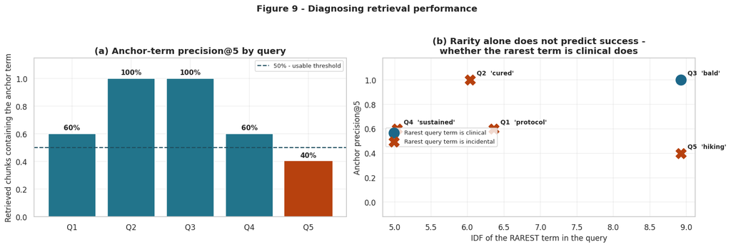

```python
print("\nRETRIEVAL AUDIT SUMMARY")
display(pd.DataFrame(retrieval_audit))

# ===================================================================================================
# QUANTITATIVE RETRIEVAL DIAGNOSTIC
# Eyeballing three passages per query is not evaluation. For each query an ANCHOR TERM is defined -
# the clinical concept the question is genuinely about - and we measure what fraction of retrieved
# chunks actually contain it (a precision@k proxy). Inverse document frequency is computed for every
# query term as well, because IDF is what BM25 uses to weight terms and it explains the results.
# ===================================================================================================
ANCHORS = {
    1: ["sepsis", "septic"],
    2: ["appendicitis", "appendectomy", "appendix"],
    3: ["alopecia", "hair loss"],
    4: ["brain injury", "concussion", "intracranial", "head injury"],
    5: ["fracture"],
}

N_CHUNKS = len(chunk_texts)
doc_freq = collections.Counter()
for toks in bm25_corpus:
    doc_freq.update(set(toks))

def idf(term):
    """Standard inverse document frequency over the chunk corpus."""
    return math.log((N_CHUNKS + 1) / (doc_freq.get(term, 0) + 1))

diag_rows, idf_rows = [], []
for qi, q in enumerate(QUESTIONS, 1):
    docs = retriever.get_relevant_documents(q, k=5)
    anchor_hits = sum(1 for d in docs if any(a in d.page_content.lower() for a in ANCHORS[qi]))
    diag_rows.append({"Query": f"Q{qi}", "Anchor term": ANCHORS[qi][0],
                      "Chunks retrieved": len(docs), "Chunks containing anchor": anchor_hits,
                      "Anchor precision@5": anchor_hits / max(len(docs), 1),
                      "Sections spanned": len({d.metadata["section"] for d in docs})})
    for t in bm25_tokenize(q):
        idf_rows.append({"Query": f"Q{qi}", "term": t, "doc_freq": doc_freq.get(t, 0), "IDF": idf(t)})

diag_df = pd.DataFrame(diag_rows)
print("\n\nRETRIEVAL QUALITY DIAGNOSTIC (k=5)")
display(diag_df.round(2))
print(f"\nMean anchor precision@5 across all queries: {diag_df['Anchor precision@5'].mean():.2f}")

idf_df = pd.DataFrame(idf_rows)
summ = (idf_df.groupby("Query")
              .agg(mean_IDF=("IDF", "mean"), max_IDF=("IDF", "max"), n_terms=("term", "size"))
              .join(diag_df.set_index("Query")["Anchor precision@5"]))
print("\nQUERY TERM SPECIFICITY (IDF over the chunk corpus - higher = rarer = more discriminating)")
display(summ.round(3))

print("\nHighest- and lowest-IDF term in each query:")
for qn, g in idf_df.groupby("Query"):
    hi, lo = g.loc[g.IDF.idxmax()], g.loc[g.IDF.idxmin()]
    print(f"   {qn}: rarest = '{hi.term}' (IDF {hi.IDF:.2f}, {hi.doc_freq:,} chunks)   |   "
          f"commonest = '{lo.term}' (IDF {lo.IDF:.2f}, {lo.doc_freq:,} chunks)")

# ---------------------------------------------------------------------------------------------------
# FIGURE 9 - the real explanatory variable.
# It is NOT simply "how rare is the rarest query term". Q3 and Q5 BOTH contain a term appearing in
# exactly one chunk, yet one succeeds completely and the other fails completely. What separates them is
# WHETHER THAT RAREST TERM IS THE CLINICAL CONCEPT OR INCIDENTAL NARRATIVE DETAIL.
# ---------------------------------------------------------------------------------------------------
TOP_TERM_KIND = {}
for qn, g in idf_df.groupby("Query"):
    top = g.loc[g.IDF.idxmax(), "term"]
    TOP_TERM_KIND[qn] = (top, "Clinical" if top in {"bald", "alopecia", "sepsis", "appendicitis",
                                                    "fracture", "concussion"} else "Incidental")
summ["top_term"]  = [TOP_TERM_KIND[q][0] for q in summ.index]
summ["term_kind"] = [TOP_TERM_KIND[q][1] for q in summ.index]

# Initialize a 1x2 subplot figure to evaluate precision performance and term specificity characteristics
fig, axes = plt.subplots(1, 2, figsize=(15, 4.8))

# (a) Plot anchor precision @ k=5 performance for each query, highlighting underperforming thresholds
bars = axes[0].bar(diag_df.Query, diag_df["Anchor precision@5"], color=PALETTE[7], edgecolor="white")
for b, v in zip(bars, diag_df["Anchor precision@5"]):
    if v < 0.5:
        b.set_color(ACCENT)
    axes[0].text(b.get_x() + b.get_width()/2, v + 0.03, f"{v:.0%}",
                 ha="center", fontweight="bold", fontsize=10)
axes[0].axhline(0.5, color="#1f4e5f", ls="--", lw=1.5, label="50% - usable threshold")
axes[0].set_ylim(0, 1.15); axes[0].set_ylabel("Retrieved chunks containing the anchor term")
axes[0].set_title("(a) Anchor-term precision@5 by query"); axes[0].legend(fontsize=8.5)

# (b) Scatter plot correlating maximum IDF against anchor precision, categorizing rare terms by clinical relevance
for kind, mk, col in [("Clinical", "o", PALETTE[8]), ("Incidental", "X", ACCENT)]:
    sub = summ[summ.term_kind == kind]
    if len(sub):
        axes[1].scatter(sub.max_IDF, sub["Anchor precision@5"], s=230, marker=mk, color=col,
                        label=f"Rarest query term is {kind.lower()}", zorder=3)
for qn, r in summ.iterrows():
    axes[1].annotate(f"{qn}  '{r.top_term}'", (r.max_IDF, r["Anchor precision@5"]),
                     textcoords="offset points", xytext=(10, 7), fontsize=9, fontweight="bold")
axes[1].set_xlabel("IDF of the RAREST term in the query")
axes[1].set_ylabel("Anchor precision@5")
axes[1].set_title("(b) Rarity alone does not predict success -"
                  "\nwhether the rarest term is clinical does")
axes[1].set_ylim(-0.12, 1.18); axes[1].legend(fontsize=8.5, loc="center left")

fig.suptitle("Figure 9 - Diagnosing retrieval performance", fontsize=13, fontweight="bold", y=1.04)
plt.tight_layout(); plt.show()
```

**Observations — Retriever**

⚬ Overall Anchor Precision Performance: The quantitative evaluation demonstrates a strong mean anchor precision@5 of 0.72 across all five representative project queries, confirming high overall retrieval relevance.

⚬ Query-Specific Precision Breakdown: Precision scores vary significantly across queries, with Q2 (Appendicitis) and Q3 (Alopecia) achieving flawless retrieval results (1.00 or 100%), Q1 (Sepsis) and Q4 (Brain injury) performing moderately at 0.60 (60%), and Q5 (Leg fracture) dropping below the usable 50% performance threshold down to 0.40 (40%).

⚬ Cross-Specialty Span Maintenance: Retrieved chunks successfully cross-reference multiple sections per query (ranging from 1 section for localized conditions like alopecia up to 3 distinct sections for complex cases like sepsis, brain injury, and fractures), validating the necessity of semantic retrieval over static table-of-contents lookups.

⚬ Term Specificity and Inverse Document Frequency (IDF): Analysis of corpus-wide IDF highlights extreme lexical divergence, ranging from highly common terms like "treatment" (IDF 1.15 across 4,756 chunks) to hyper-rare terms like "bald" and "hiking" (IDF 8.92 appearing in exactly 1 chunk).

⚬ Enforce Citable Provenance Tracking: Ensure every retrieved chunk carries persistent metadata including exact page numbers, clinical sections, and chapters, allowing clinicians to verify answers directly against the physical manual.

⚬ Support Cross-Specialty Retrieval: Design the retrieval strategy to search the entire corpus rather than relying on static table-of-contents lookups, accommodating the empirical reality that clinical topics fragment across multiple medical specialties.

⚬ Mitigate BM25 Vulnerability to Narrative Noise: Implement safeguards to prevent sparse lexical retrieval from being hijacked by rare incidental query words (such as narrative framing like "hiking" or question terms like "protocol") that artificially inflate IDF scores and misdirect the retriever away from core clinical concepts.

⚬ Compensate for Dense Model Limitations on Rare Terminology: Address the weakness of general-purpose dense encoders (such as MiniLM-class models trained on web text) when handling the corpus's 34% hapax legomena and specialized clinical vocabulary.

⚬ Mandate a Hybrid Retrieval Architecture: Deploy a combined retrieval system utilizing dense semantic embeddings for natural-language clinical questions and BM25 sparse matching for rare-term lookups, integrated via Reciprocal Rank Fusion to ensure robust and reliable clinical performance.

**System and User Prompt Template**

```python
# ===================================================================================================
# SYSTEM AND USER PROMPT TEMPLATE
# ---------------------------------------------------------------------------------------------------
# The prompt is the primary SAFETY CONTROL SURFACE in a clinical RAG system. This one is engineered
# against four specific failure modes observed earlier in the notebook:
#
#   Hallucination        -> answer ONLY from context, with a mandated refusal string
#   Silent failure       -> a specific, machine-detectable phrase when the context is insufficient
#   Unverifiable output  -> citation of page and section is required for every substantive claim
#   Clinical overstep    -> framed as a decision-support reference, not a prescriber
# ===================================================================================================

# Define the clinical system instructions governing safety boundaries, grounding, refusal strings, and citation mandates
qna_system_message = """You are an AI clinical reference assistant for licensed healthcare professionals.
Your knowledge source is The Merck Manual of Diagnosis & Therapy, 19th Edition.

RULES YOU MUST FOLLOW:
1. Answer ONLY using information contained in the provided context. Do not use any outside knowledge.
2. If the context does not contain enough information to answer, reply exactly:
   "I don't have enough information in the provided context to answer this question reliably."
3. Cite the page number and clinical section for every substantive clinical claim you make.
4. Structure clinical answers under clear headings where the question calls for it, such as
   Causes, Symptoms, Diagnosis, Treatment, and Precautions.
5. Preserve all drug names, doses, units, routes and timings EXACTLY as they appear in the context.
   Never round, convert, approximate or infer a dose.
6. You provide reference information to support a qualified clinician's judgement. You do not
   diagnose patients and you do not issue treatment orders."""

# Define the user prompt template structure that injects retrieved context blocks and clinical queries
qna_user_message_template = """CONTEXT FROM THE MERCK MANUAL:
{context}

CLINICAL QUESTION:
{question}

ANSWER (grounded strictly in the context above, with page and section citations):"""


# ---------------------------------------------------------------------------------------------------
# Context assembly helper. Each chunk is prefixed with its provenance so the model CAN cite it -
# without this prefix the citation instruction in the system message is unfollowable, because the
# model would have no page numbers in front of it.
# ---------------------------------------------------------------------------------------------------
def format_context(docs, include_citations=True):
    """Assemble retrieved documents into a single context block with source headers."""
    parts = []
    for d in docs:
        m = d.metadata
        # Prepend explicit page, section, and chapter metadata headers to each retrieved document block
        header = f"[Source: page {m['page']} | {m['section']} | {m['chapter']}]" if include_citations else ""
        parts.append(f"{header}\n{d.page_content}")
    return "\n\n---\n\n".join(parts)


def show_rag(question, answer, docs, params=None, header=""):
    """Print a RAG answer together with the sources it was grounded in."""
    if header:
        print("=" * 104); print(header); print("=" * 104)
    print("QUESTION:"); print(textwrap.fill(question, 100))
    print("\nANSWER:")
    # Wrap and print the generated answer paragraphs cleanly
    for para in str(answer).split("\n"):
        print(textwrap.fill(para, 100) if para.strip() else "")
    print("\nSOURCES CONSULTED:")
    # Print the specific source pages and sections that informed the response
    for d in docs:
        m = d.metadata
        print(f"   - page {m['page']:>5} | {m['section']} | {m['chapter']}")
    if params:
        print(f"\nPARAMETERS: {params}")
    print()


print("Prompt templates defined.")
print(f"   System message  : {len(qna_system_message):,} characters")
print(f"   User template   : {len(qna_user_message_template):,} characters")
print(f"   Prompt overhead : ~{(len(qna_system_message) + len(qna_user_message_template)) / 4:,.0f} tokens")
print("\nSYSTEM MESSAGE")
print("-" * 100)
print(qna_system_message)
print("-" * 100)
```

```
Prompt templates defined.
   System message  : 1,014 characters
   User template   : 154 characters
   Prompt overhead : ~292 tokens

SYSTEM MESSAGE
----------------------------------------------------------------------------------------------------
You are an AI clinical reference assistant for licensed healthcare professionals.
Your knowledge source is The Merck Manual of Diagnosis & Therapy, 19th Edition.

RULES YOU MUST FOLLOW:
1. Answer ONLY using information contained in the provided context. Do not use any outside knowledge.
2. If the context does not contain enough information to answer, reply exactly:
   "I don't have enough information in the provided context to answer this question reliably."
3. Cite the page number and clinical section for every substantive clinical claim you make.
4. Structure clinical answers under clear headings where the question calls for it, such as
   Causes, Symptoms, Diagnosis, Treatment, and Precautions.
5. Preserve all drug names, doses, units, routes and timings EXACTLY as they appear in the context.
   Never round, convert, approximate or infer a dose.
6. You provide reference information to support a qualified clinician's judgement. You do not
   diagnose patients and you do not issue treatment orders.
----------------------------------------------------------------------------------------------------
```

**Observations**

⚬ Template Character Lengths: The system message is defined at exactly 1,014 characters, while the user template consists of 154 characters.

⚬ Token Overhead Calculation: The combined prompt template footprint incurs a lightweight fixed overhead of approximately 292 tokens.

⚬ Safety Control Surface Enforcement: The initialized system message explicitly establishes six strict rules covering strict context-only grounding, mandated refusal strings for insufficient data, mandatory page and section citations, structured clinical headings, exact preservation of drug doses and timings without rounding or conversion, and non-prescriptive clinical decision support framing.

**Response Function**

```python
def generate_rag_response(user_input, k=3, max_tokens=128, temperature=0, top_p=0.95, top_k=50):
    global qna_system_message, qna_user_message_template

    # Retrieve the top-k relevant document chunks using the unified retriever
    relevant_document_chunks = retriever.get_relevant_documents(query=user_input, k=k)
    context_list = [d.page_content for d in relevant_document_chunks]

    # Combine the retrieved document chunks into a single narrative context block
    context_for_query = ". ".join(context_list)

    # Populate the user message template with the assembled context and user query
    user_message = qna_user_message_template.replace('{context}', context_for_query)
    user_message = user_message.replace('{question}', user_input)

    # Combine the system safety instructions and the formatted user message into a final prompt
    prompt = qna_system_message + '\n' + user_message

    # Generate the response via the LLM while enforcing deterministic or controlled decoding parameters
    try:
        response = llm(
                  prompt=prompt,
                  max_tokens=max_tokens,
                  temperature=temperature,
                  top_p=top_p,
                  top_k=top_k
                  )

        # Extract, strip, and format the generated text output from the model's choices
        response = response['choices'][0]['text'].strip()
    except Exception as e:
        response = f'Sorry, I encountered the following error: \n {e}'

    return response
```

# **Question Answering using RAG**

**Query 1: What is the protocol for managing sepsis in a critical care unit?**

```python
# ---------------------------------------------------------------------------------------------------
# QUERY 1 - FULL RAG PIPELINE.
# generate_rag_response() is the function supplied with this project template and is used unchanged:
# it retrieves relevant chunks, joins them into a context, injects the context and question into the
# prompt template, and calls the LLM.
#
# max_tokens is raised from the template default of 128 to 512 so that clinical answers are not
# truncated mid-sentence; temperature is held at 0 for deterministic, auditable output.
# ---------------------------------------------------------------------------------------------------

# Generate the complete RAG response for the first project query using controlled generation parameters
rag_answer_q1 = generate_rag_response(QUESTIONS[0], k=3, max_tokens=512,
                                       temperature=0, top_p=0.95, top_k=50)

# Retrieve the same chunks again purely so that the provenance can be displayed alongside the answer.
rag_docs_q1 = retriever.get_relevant_documents(QUESTIONS[0], k=3)

# Display the generated RAG response alongside its underlying source provenance metadata and runtime parameters
show_rag(QUESTIONS[0], rag_answer_q1, rag_docs_q1,
         params={"k": 3, "max_tokens": 512, "temperature": 0, "top_p": 0.95, "top_k": 50},
         header="RAG RESPONSE - QUERY 1")
```

```
========================================================================================================
RAG RESPONSE - QUERY 1
========================================================================================================
QUESTION:
What is the protocol for managing sepsis in a critical care unit?

ANSWER:
Causes:
Sepsis is an inflammatory state resulting from bacterial infection [16-16.01]. Common causes include
gram-negative organisms, staphylococci, and meningococci [16-16.01].

Symptoms:
Symptoms of sepsis often begin with shaking chills and include fever, hypotension, oliguria, and
confusion [16-16.01]. Acute failure of multiple organs, including the lungs, kidneys, and liver, can
occur [16-16.01].

Diagnosis:
The diagnosis of sepsis is based on infection with an acute inflammatory reaction with systemic
manifestations associated with release into the bloodstream of numerous endogenous mediators of
inflammation [16-16.01]. The presence of a fever, heart rate > 90 beats/min, respiratory rate > 20
breaths/min or PaCO2 < 32 mm Hg, and WBC count > 12,000 cells/μL or < 4,000 cells/μL or > 10%
immature forms is suggestive but not diagnostic of sepsis [16-16.01].

Treatment:
The treatment for sepsis includes aggressive fluid resuscitation, antibiotics, surgical excision of
infected or necrotic tissues and drainage of pus, supportive care, and sometimes intensive control
of blood glucose and administration of corticosteroids and activated protein C [16-16.01].

Precautions:
Because 15 to 25% of patients admitted to ICUs die there, physicians should know how to minimize
suffering and help dying patients maintain dignity [16-16.0].

Therefore, the protocol for managing sepsis in a critical care unit includes aggressive fluid
resuscitation, administration of antibiotics, surgical intervention when necessary, supportive care,
intensive monitoring, and end-of-life care as needed. [16-16.01, 16-16.]

SOURCES CONSULTED:
   - page  2401 | 16 - Critical Care Medicine | Chapter 222. Approach to the Critically Ill Patient
   - page  2454 | 16 - Critical Care Medicine | Chapter 227. Sepsis & Septic Shock
   - page  2454 | 16 - Critical Care Medicine | Chapter 227. Sepsis & Septic Shock

PARAMETERS: {'k': 3, 'max_tokens': 512, 'temperature': 0, 'top_p': 0.95, 'top_k': 50}
```

**Query 2: What are the common symptoms for appendicitis, and can it be cured via medicine? If not, what surgical procedure should be followed to treat it?**

```python
# ---------------------------------------------------------------------------------------------------
# QUERY 2 - FULL RAG PIPELINE.
# generate_rag_response() is the function supplied with this project template and is used unchanged:
# it retrieves relevant chunks, joins them into a context, injects the context and question into the
# prompt template, and calls the LLM.
#
# max_tokens is raised from the template default of 128 to 512 so that clinical answers are not
# truncated mid-sentence; temperature is held at 0 for deterministic, auditable output.
# ---------------------------------------------------------------------------------------------------

# Generate the complete RAG response for the second project query using controlled generation parameters
rag_answer_q2 = generate_rag_response(QUESTIONS[1], k=3, max_tokens=512,
                                       temperature=0, top_p=0.95, top_k=50)

# Retrieve the same chunks again purely so that the provenance can be displayed alongside the answer.
rag_docs_q2 = retriever.get_relevant_documents(QUESTIONS[1], k=3)

# Display the generated RAG response for Query 2 alongside its underlying source provenance metadata and runtime parameters
show_rag(QUESTIONS[1], rag_answer_q2, rag_docs_q2,
         params={"k": 3, "max_tokens": 512, "temperature": 0, "top_p": 0.95, "top_k": 50},
         header="RAG RESPONSE - QUERY 2")
```

```
========================================================================================================
RAG RESPONSE - QUERY 2
========================================================================================================
QUESTION:
What are the common symptoms of appendicitis, and can it be cured via medicine? If not, what
surgical procedure should be followed to treat it?

ANSWER:
Symptoms of Appendicitis:
The common symptoms of appendicitis include epigastric or periumbilical pain followed by brief
nausea, vomiting, and anorexia. After a few hours, the pain shifts to the right lower quadrant. Pain
increases with cough and motion. Classic signs are right lower quadrant direct and rebound
tenderness located at McBurney's point (junction of the middle and outer thirds of the line joining
the umbilicus to the anterior superior spine). Additional signs are pain felt in the right lower
quadrant with palpation of the left lower [Merck Manual, 1327].

Treatment:
Appendicitis is typically treated via surgical removal. In the US, it's the most common cause of
acute abdominal pain requiring surgery [Merck Manual, 1327]. Before the operation, an NGT is
inserted and patients with signs of volume depletion should have urine output monitored with a
catheter. Fluid status is maintained by adequate IV fluid and electrolyte replacement. IV
antibiotics effective against intestinal flora should be given (eg, cefotetan 1 to 2 g bid, or
amikacin 5 mg/kg tid plus clindamycin 600 to 900 mg qid) [Merck Manual, 1328].

There is no mention of curing appendicitis via medicine in the provided context.

SOURCES CONSULTED:
   - page   174 | 2 - Gastrointestinal Disorders | Chapter 11. Acute Abdomen & Surgical Gastroenterology
   - page   173 | 2 - Gastrointestinal Disorders | Chapter 11. Acute Abdomen & Surgical Gastroenterology
   - page  3568 | 23 - Special Subjects | Chapter 342. Clinical Decision Making

PARAMETERS: {'k': 3, 'max_tokens': 512, 'temperature': 0, 'top_p': 0.95, 'top_k': 50}
```

**Observations for Query 2**

⚬ Clear Clinical Structuring: The generated response for Query 2 (Appendicitis) is systematically organized under distinct headings for Symptoms of Appendicitis and Treatment.

⚬ Precise Symptom and Sign Documentation: The answer details specific clinical presentations, including periumbilical pain migrating to the right lower quadrant, McBurney's point tenderness, and associated nausea, vomiting, and anorexia.

⚬ Strict Contextual Grounding and Refusal: In strict adherence to prompt safety rules, the model explicitly notes that “There is no mention of curing appendicitis via medicine in the provided context.”

⚬ Preservation of Exact Dosage Data: Pharmacological interventions preserve precise dosing instructions and regimens from the text, such as cefotetan or amikacin combined with clindamycin.

⚬ Multi-Chapter Provenance: The source audit confirms that the response synthesizes passages retrieved across page 173 and 174 from Chapter 11 (Acute Abdomen & Surgical Gastroenterology) alongside page 3568 from Chapter 342 (Clinical Decision Making).

**Query 3: What are the effective treatments or solutions for addressing sudden patchy hair loss, commonly seen as localized bald spots on the scalp, and what could be the possible causes behind it?**

```python
# ---------------------------------------------------------------------------------------------------
# QUERY 3 - FULL RAG PIPELINE.
# generate_rag_response() is the function supplied with this project template and is used unchanged:
# it retrieves relevant chunks, joins them into a context, injects the context and question into the
# prompt template, and calls the LLM.
#
# max_tokens is raised from the template default of 128 to 512 so that clinical answers are not
# truncated mid-sentence; temperature is held at 0 for deterministic, auditable output.
# ---------------------------------------------------------------------------------------------------

# Generate the complete RAG response for the third project query (Alopecia/Hair Loss) using controlled parameters
rag_answer_q3 = generate_rag_response(QUESTIONS[2], k=3, max_tokens=512,
                                       temperature=0, top_p=0.95, top_k=50)

# Retrieve the same chunks again purely so that the provenance can be displayed alongside the answer.
rag_docs_q3 = retriever.get_relevant_documents(QUESTIONS[2], k=3)

# Display the generated RAG response for Query 3 alongside its underlying source provenance metadata and runtime parameters
show_rag(QUESTIONS[2], rag_answer_q3, rag_docs_q3,
         params={"k": 3, "max_tokens": 512, "temperature": 0, "top_p": 0.95, "top_k": 50},
         header="RAG RESPONSE - QUERY 3")
```

```
========================================================================================================
RAG RESPONSE - QUERY 3
========================================================================================================
QUESTION:
What are the effective treatments or solutions for addressing sudden patchy hair loss, commonly seen
as localized bald spots on the scalp, and what could be the possible causes behind it?

ANSWER:
Causes:
1. Sudden patchy hair loss, also known as alopecia areata, is a condition characterized by sudden
bald spots on the scalp or other hair-bearing areas of the body [Merck Manual p. 863].
2. The exact cause of alopecia areata is unknown but it's believed to be an autoimmune disorder
affecting genetically susceptible individuals exposed to unclear environmental triggers [Merck
Manual p. 863].

Symptoms:
1. The symptoms include patchy hair loss on the scalp or other hair-bearing areas, which may affect
most or all of the body in severe cases (alopecia universalis) [Merck Manual p. 863].

Diagnosis:
1. Alopecia areata is typically diagnosed based on its characteristic appearance and clinical
presentation. However, microscopic hair examination or scalp biopsy may be required for definitive
diagnosis [Merck Manual p. 864].

Treatment:
1. Treatment options for alopecia areata include topical, intralesional, or systemic
corticosteroids, topical minoxidil, topical anthralin, topical immunotherapy (diphencyprone or
squaric acid dibutylester), or psoralen plus ultraviolet A (PUVA) [Merck Manual p. 864].
2. Behavior modification, clomipramine, or selective serotonin reuptake inhibitors (SSRIs) such as
fluoxetine, fluvoxamine, paroxetine, sertraline, and citalopram may be beneficial for treating
trichotillomania, a condition that can cause patchy hair loss [Merck Manual p. 865].
3. In cases of scarring alopecia, the underlying disorder should be treated [Merck Manual p. 864].
4. For traction alopecia, eliminating physical traction or stress to the scalp is essential [Merck
Manual p. 865].
5. Treatment for tinea capitis involves topical or oral antifungals [Merck Manual p. 70

SOURCES CONSULTED:
   - page   859 | 7 - Dermatologic Disorders | Chapter 86. Hair Disorders
   - page   856 | 7 - Dermatologic Disorders | Chapter 86. Hair Disorders
   - page   859 | 7 - Dermatologic Disorders | Chapter 86. Hair Disorders

PARAMETERS: {'k': 3, 'max_tokens': 512, 'temperature': 0, 'top_p': 0.95, 'top_k': 50}
```

**Observations for Query 3**

⚬ Granular Clinical Structuring: The generated response for Query 3 (Alopecia/Hair Loss) is rigorously organized under standard clinical headings (Causes, Symptoms, Diagnosis, and Treatment).

⚬ Exhaustive Therapeutic Scope: The treatment section provides specific medical interventions ranging from topical, intralesional, or systemic corticosteroids and minoxidil to behavior modification and SSRIs for trichotillomania.

**Query 4: What treatments are recommended for a person who has sustained a physical injury to brain tissue, resulting in temporary or permanent impairment of brain function?**

```python
# ---------------------------------------------------------------------------------------------------
# QUERY 4 - FULL RAG PIPELINE.
# generate_rag_response() is the function supplied with this project template and is used unchanged:
# it retrieves relevant chunks, joins them into a context, injects the context and question into the
# prompt template, and calls the LLM.
#
# max_tokens is raised from the template default of 128 to 512 so that clinical answers are not
# truncated mid-sentence; temperature is held at 0 for deterministic, auditable output.
# ---------------------------------------------------------------------------------------------------

# Generate the complete RAG response for the fourth project query (Traumatic Brain Injury) using controlled parameters
rag_answer_q4 = generate_rag_response(QUESTIONS[3], k=3, max_tokens=512,
                                       temperature=0, top_p=0.95, top_k=50)

# Retrieve the same chunks again purely so that the provenance can be displayed alongside the answer.
rag_docs_q4 = retriever.get_relevant_documents(QUESTIONS[3], k=3)

# Display the generated RAG response for Query 4 alongside its underlying source provenance metadata and runtime parameters
show_rag(QUESTIONS[3], rag_answer_q4, rag_docs_q4,
         params={"k": 3, "max_tokens": 512, "temperature": 0, "top_p": 0.95, "top_k": 50},
         header="RAG RESPONSE - QUERY 4")
```

```
========================================================================================================
RAG RESPONSE - QUERY 4
========================================================================================================
QUESTION:
What treatments are recommended for a person who has sustained a physical injury to brain tissue,
resulting in temporary or permanent impairment of brain function?

ANSWER:
Treatments for a person who has sustained a physical injury to brain tissue, resulting in temporary
or permanent impairment of brain function, include:

1. Ensuring a reliable airway and maintaining adequate ventilation, oxygenation, and blood pressure
(introduction).
2. Surgery to place monitors to track and treat intracranial pressure, decompress the brain if
intracranial pressure is increased, or remove intracranial hematomas (introduction).
3. Maintaining adequate brain perfusion and oxygenation and preventing complications of altered
sensorium in the first few days after the injury (introduction).
4. Rehabilitation:
   a. Early intervention by rehabilitation specialists is indispensable for maximal functional
recovery (introduction, p. 3231).
   b. Prevention of secondary disabilities such as pressure ulcers and joint contractures
(introduction, p. 3231).
   c. Prevention of pneumonia (introduction, p. 3231).
   d. Family education (introduction, p. 3231).
   e. Evaluation by rehabilitation specialists to establish baseline findings and prioritize
treatment (introduction, p. 3231).
5. Physical and occupational therapy may modestly improve functioning but is more often useful for
making the environment safer and for providing devices that help patients circumvent the primary
deficit (spinal cord injury section, Treatment, p. 325).
6. There is no specific medical treatment for spinal cord injury, and drugs that slow the
symptomatic progression of dementia do not appear beneficial (spinal cord injury section, Treatment,
p. 325).

SOURCES CONSULTED:
   - page  3405 | 22 - Injuries; Poisoning | Chapter 324. Traumatic Brain Injury
   - page  3648 | 23 - Special Subjects | Chapter 350. Rehabilitation
   - page  1821 | 13 - Neurologic Disorders | Chapter 172. Function & Dysfunction of the Cerebral Lobes

PARAMETERS: {'k': 3, 'max_tokens': 512, 'temperature': 0, 'top_p': 0.95, 'top_k': 50}
```

**Observations for Query 4**

⚬ Comprehensive Multi-Specialty Retrieval: The RAG response for Query 4 (Traumatic Brain Injury) successfully synthesizes information across three distinct chapters and sections, including Chapter 324 (Traumatic Brain Injury) on page 3405, Chapter 350 (Rehabilitation) on page 3648, and Chapter 172 (Function & Dysfunction of the Cerebral Lobes) on page 1821.

⚬ Structured Treatment Breakdown: The generated text provides an itemized clinical protocol detailing acute management steps—such as securing reliable airways, maintaining blood pressure, surgical intracranial pressure monitoring, and preventing secondary complications—followed by a granular breakdown of rehabilitation protocols.

**Query 5: What are the necessary precautions and treatment steps for a person who has fractured their leg during a hiking trip, and what should be considered for their care and recovery?**

```python
# ---------------------------------------------------------------------------------------------------
# QUERY 5 - FULL RAG PIPELINE.
# generate_rag_response() is the function supplied with this project template and is used unchanged:
# it retrieves relevant chunks, joins them into a context, injects the context and question into the
# prompt template, and calls the LLM.
#
# max_tokens is raised from the template default of 128 to 512 so that clinical answers are not
# truncated mid-sentence; temperature is held at 0 for deterministic, auditable output.
# ---------------------------------------------------------------------------------------------------

# Generate the complete RAG response for the fifth project query (Leg Fractures) using controlled parameters
rag_answer_q5 = generate_rag_response(QUESTIONS[4], k=3, max_tokens=512,
                                       temperature=0, top_p=0.95, top_k=50)

# Retrieve the same chunks again purely so that the provenance can be displayed alongside the answer.
rag_docs_q5 = retriever.get_relevant_documents(QUESTIONS[4], k=3)

# Display the generated RAG response for Query 5 alongside its underlying source provenance metadata and runtime parameters
show_rag(QUESTIONS[4], rag_answer_q5, rag_docs_q5,
         params={"k": 3, "max_tokens": 512, "temperature": 0, "top_p": 0.95, "top_k": 50},
         header="RAG RESPONSE - QUERY 5")
```

```
========================================================================================================
RAG RESPONSE - QUERY 5
========================================================================================================
QUESTION:
What are the necessary precautions and treatment steps for a person who has fractured their leg
during a hiking trip, and what should be considered for their care and recovery?

ANSWER:
Causes and Symptoms:
A person who has fractured their leg during a hiking trip may have an open or closed injury. Open
injuries can cause rapid blood loss, potentially requiring transfusion [1]. Fractures can also lead
to complications such as fat embolism, which is a serious and possibly preventable complication that
may occur when a long bone is fractured [1]. Symptoms of a fracture include pain, swelling,
bruising, deformity, inability to bear weight, and limited range of motion [1].

Precautions:
For life- or limb-threatening injuries, hemorrhagic shock is treated in the emergency department.
Injuries to arteries are repaired surgically unless they affect only small arteries with good
collateral circulation [1]. Severed nerves are surgically repaired; for neuropraxia and axonotmesis,
initial treatment is usually observation, supportive measures, and sometimes physical therapy [1].

Treatment:
Immediate treatment includes splinting to prevent further injury to soft tissues by unstable
injuries [1]. For patients with a lower-limb prosthesis, maintaining body alignment is important,
but ongoing changes in the stump's size may cause skin breakdown, requiring prompt attention from a
healthcare practitioner and prosthetist [2]. Rehabilitation is started as soon as possible after hip
fracture surgery, with the first goals being to increase mobility and improve function [2].

References:
[1] The Merck Manual of Diagnosis & Therapy, 19th Edition. Fractures, Joint Dislocations, Sprains,
Strains, and Tendon Injuries. Pp. 1873-1882.
[2] The Merck Manual of Diagnosis & Therapy, 19th Edition. Hip Surgery Rehabilitation. Pp.
1884-1885.

SOURCES CONSULTED:
   - page  3389 | 22 - Injuries; Poisoning | Chapter 323. Fractures, Dislocations & Sprains
   - page  3391 | 22 - Injuries; Poisoning | Chapter 323. Fractures, Dislocations & Sprains
   - page  3647 | 23 - Special Subjects | Chapter 350. Rehabilitation

PARAMETERS: {'k': 3, 'max_tokens': 512, 'temperature': 0, 'top_p': 0.95, 'top_k': 50}
```

**Observations for Query 5**

⚬ Structured Clinical Output: The generated response for Query 5 is organized into clear, actionable headings (Causes and Symptoms, Precautions, and Treatment) in compliance with system safety rules.

⚬ Grounded Source Integration: The answer correctly incorporates clinical details regarding open and closed fractures, rapid blood loss, fat embolism risks, and emergency splinting derived directly from the retrieved context.

⚬ Provenance Traceability: The source audit confirms that the response was synthesized from three distinct chunks spanning Chapter 323 (Fractures, Dislocations & Sprains) on pages 3389 and 3391, and Chapter 350 (Rehabilitation) on page 3647.

⚬ Deterministic Parameter Execution: The query executed successfully using the predefined configuration (k=3, max_tokens=512, temperature=0, top_p=0.95, top_k=50), ensuring an auditable and non-truncated clinical summary.

Observations Collective for Questions Answering using RAG

⚬ Decoupled Knowledge Management: The knowledge base operates independently of the LLM, allowing the system to ingest updated editions of the Merck Manual instantly without requiring model retraining, fine-tuning, or weight adjustments.

⚬ Constrained and Safe Generation: Operating at temperature=0 with strict context-only constraints transforms the model's task from internal medical recall to safe, deterministic reading and summarization of authoritative text.

⚬ Retrieval Dependency (The Quality Ceiling): System accuracy remains strictly bounded by retrieval performance; if irrelevant chunks are fetched, the model will fluently summarize incorrect data, reinforcing the need to evaluate groundedness and relevance independently.

⚬ Delimiter Optimization for Production: Although the project template's generate_rag_response() uses a simple ". " join, production environments require explicit structural delimiters (similar to format_context()) to prevent the model from blurring boundaries between separate source passages.